# Model Comparision of Keras Neural Net, Random Forest, Gradient Boosting, Naiyes Bayes, and Logistic Regression

# Hyperparameter Tuning and Grid Search for RF, LR, and GB

By Heidi Nguyen

- I. Introduction
- II. Evaluation metrics selection
- III. Data Pre-processing
- IV. Data Understanding
- V. Modelling - Hyperparameter Tuning and Grid Search
  - 1. Training and Splitting
  - 2. Grid Search CV - Random Forest
  - 3. Grid Search CV - Logistic Regression
  - 4. Grid Search CV - Gradient Boosting
  - 5. Keras Method
    - a. Layer Optimization
    - b. Activation Optimization
    - c. Kernel Optimization
    - d. Optimizer Optimization
    - e. Model Optimization - Epochs and Batch Size Optimization
- VI. Model Comparision
- VII. Results and Model Selection
- VIII. Conclusion
- IX. Reference
- X. Appendix

# I. Introduction

The objective of this case study is to find the best model what gives the best ROC result for our data set. We investigate what kind of model and its best parameters we can use to predict the classifications of our dataset. We analyze our data using logistic regression, random forest, and deep learning methods in scikit-learn Gradient Boosting, Naiyes Bayes, and Neural Net in Keras API.

We use StratifiedKFold cross-validation to create multiple train/test data sets for training and testing the model. We have enough samples that we do not see any weakness of using StratifiedKFold.

We train and fit our model on our loaded data by calling the fit() function on the model. We explore different parameters to find the combination that performs best. To validate the models, we use the test data and the predict() function. We then compare the results based on our model with the actual results in the test data. We compare these methods using ROC for overall performance. We also measure the effectiveness of our algorithms of the prediction using accuracy, area under the curve (AUC), recall, precision, and f-measure tests as below.

Back to top

# II. Evaluation Metrics Selection

We use precision and AUC as our evaluation metrics. The final metric is Receiver Operating Characteristic (ROC) which is a measure of false positives. ROC Curves and AUC scores are good measures for our imbalanced data and the main goal for learning from our imbalanced dataset is to improve the recall without scarifying the precision too much.

Confusion matrix:

| Item | Predicted:0 | Predicted:1 |
| --- | --- | --- |
| Actual: 0 - negative | a | b |
| Actual: 1 - positive | c | d |

a or TN is the number of correct predictions that an instance is negative  
b or FP is the number of incorrect predictions that an instance is positive  
c or FN is the number of incorrect of predictions that an instance negative  
d or TP is the number of correct predictions that an instance is positive.

1 - Precision (P) is the proportion of the predicted positive cases that were correct, the accuracy of the predicted positives. From a confusion matrix, we can obtain the precision of the model by taking the number of instances that were predicted to be True and were actually True, then divide this by the total number of instances that were predicted to be True.

$precision = \frac{d}{b + d} = \frac{TP}{TP + FP}$

```
The total of TP and FP is equal to all the predicted positives. Precision can start to decrease as the model loosens the criteria to increase the TP. TP might increase, but FP might increase as well.
Recall and precision are competing in nature, therefore, all being kept the same, improving one will be at the expense of the other.
```

2 - Recall, also known as True Positive Rate (TPR), tells how often an actual True instance is predicted to be True. So, Recall is taking the number of True instances that are predicted correctly and dividing it by the total number of instances that are actually True.

```
Depending on the business case, a proper measure of the metrics needs to take into account the cost of being wrong. The evaluation metric for this case study is ROC. With these scenarios, we are going to assume the cost of predicting positive wrong is more costly than predicting negative wrong. This means that the false positives (FP) are costlier than false negatives FN). Furthermore, this means that the recall measurement should be minimized while maximizing precision.
```

$recall (TPR) = \frac{d}{c + d} = \frac{TP}{TP + FN}$

3 - Type I and Type II Error: Type I error is the rejection of a true null hypothesis (also known as a "false positive" finding), while a type II error is failing to reject a false null hypothesis (also known as a "false negative" finding). 4 - Accuracy (AC) is the proportion of the total number of predictions that were correct. From a confusion matrix, we can obtain the accuracy of the model by adding the number of instances that were correctly predicted, meaning predicted True and were actually True, predicted False were actually False. Then we divide it by the total number of instances.

$AC = \frac{a + d}{a + b + c + d} = \frac{TN+TP}{TN+FN+FP+TP}$

5 - The F-measure is a weighted average of the precision and recall. The F measure is calculated by the product of the precision and recall divided by the sum of the precision and recall. The F measure is scored between [0,1], 1 is the best value and 0 is the lowest. Beta ($\beta$) is the relative importance weighting of precision vs. recall, and is usually set to 1.

```
Together with ROC, F-value metric is one measure that combines the trade-offs of precision and recall, F-measure output, a single number is a good indication of how good a classifier in the presence of rare classes. The F-measure is also a good tool in comparing between classifiers.
```

Back to top

# III. Data Pre-processing

## 1. Raw Data Content

Dataset Information:

There are 51 variables, 1 binary response variable and 50 explanatory variables. Dataset is Data Sets anonymous with the response variable labelled as 'y' and all the explanatory variables labelled as 'x0' to 'x49'

Back to top

```python
# libraries
from pandas import DataFrame,Series
import pandas as pd
import numpy as np
import seaborn as sns
import matplotlib.pylab as plt
from collections import Counter
import os # to set wd # # os.environ['KERAS_BACKEND']='tensorflow' for keras
import re

# get time stamp
import time
# import Image
from IPython.display import Image

# BeautifulSoup
from bs4 import BeautifulSoup
import  codecs # that’s to take care of things like accented characters, which are represented in different ways on

# Keras
from keras.models import Sequential
from keras.layers.core import Dense, Dropout, Activation
from keras.optimizers import SGD
from sklearn.metrics import roc_auc_score
from keras import optimizers

# access keyboard shortcuts: Esc + H
# Mac: Cmd + Shift + P ==> private browsing => Firefox does not track
# Linux and Windows: or Ctrl + Shift + P on Linux and Windows

# Set wd
path = "/Users/heidinguyen/Downloads/"
os.chdir(path)
print os.getcwd(); # Prints the working directory
```

```
/Users/heidinguyen/Downloads
```

```python
# function to find memory size of the data
def size_it(df):
    total = 0
    for i in range(len(df.memory_usage())): # data.memory_usage()
        total = total + df.memory_usage()[i] # data.memory_usage()
    size = total/(2**20)
    print("%.2f Megabyte" %size)
```

```python
# read in the data set
df_raw=pd.read_csv("final_project.csv")
```

```python
# call size_it() to find out the total storage size
size_it(df_raw)
```

```
62.00 Megabyte
```

```python
df_raw.memory_usage().head()
```

```
Index         72
x0       1280000
x1       1280000
x2       1280000
x3       1280000
dtype: int64
```

```python
df_raw.describe()
```

|  | x0 | x1 | x2 | x3 | x4 | x5 | x6 | x7 | x8 | x9 | ... | x41 | x42 | x43 | x44 | x45 | x46 | x47 | x48 | x49 | y |
| --- | --- | --- | --- | --- | --- | --- | --- | --- | --- | --- | --- | --- | --- | --- | --- | --- | --- | --- | --- | --- | --- |
| count | 159974.000000 | 159975.000000 | 159962.000000 | 159963.000000 | 159974.000000 | 159963.000000 | 159974.000000 | 159973.000000 | 159979.000000 | 159970.000000 | ... | 159960.000000 | 159974.000000 | 159963.000000 | 159960.000000 | 159971.000000 | 159969.000000 | 159963.000000 | 159968.000000 | 159968.000000 | 160000.000000 |
| mean | -0.001028 | 0.001358 | -1.150145 | -0.024637 | -0.000549 | 0.013582 | -1.670670 | -7.692795 | -0.030540 | 0.005462 | ... | 6.701076 | -1.833820 | -0.002091 | -0.006250 | 0.000885 | -12.755395 | 0.028622 | -0.000224 | -0.674224 | 0.401231 |
| std | 0.371137 | 6.340632 | 13.273480 | 8.065032 | 6.382293 | 7.670076 | 19.298665 | 30.542264 | 8.901185 | 6.355040 | ... | 18.680196 | 5.110705 | 1.534952 | 4.164595 | 0.396621 | 36.608641 | 4.788157 | 1.935501 | 15.036738 | 0.490149 |
| min | -1.592635 | -26.278302 | -59.394048 | -35.476594 | -28.467536 | -33.822988 | -86.354483 | -181.506976 | -37.691045 | -27.980659 | ... | -82.167224 | -27.933750 | -6.876234 | -17.983487 | -1.753221 | -201.826828 | -21.086333 | -8.490155 | -65.791191 | 0.000000 |
| 25% | -0.251641 | -4.260973 | -10.166536 | -5.454438 | -4.313118 | -5.148130 | -14.780146 | -27.324771 | -6.031058 | -4.260619 | ... | -5.804080 | -5.162869 | -1.039677 | -2.812055 | -0.266518 | -36.428329 | -3.216016 | -1.320800 | -10.931753 | 0.000000 |
| 50% | -0.002047 | 0.004813 | -1.340932 | -0.031408 | 0.000857 | 0.014118 | -1.948594 | -6.956789 | -0.016840 | 0.006045 | ... | 6.840110 | -1.923754 | -0.004385 | -0.010484 | 0.001645 | -12.982497 | 0.035865 | -0.011993 | -0.574410 | 0.000000 |
| 75% | 0.248532 | 4.284220 | 7.871676 | 5.445179 | 4.306660 | 5.190749 | 11.446931 | 12.217071 | 5.972349 | 4.305734 | ... | 19.266367 | 1.453507 | 1.033275 | 2.783274 | 0.269049 | 11.445443 | 3.268028 | 1.317703 | 9.651072 | 1.000000 |
| max | 1.600849 | 27.988178 | 63.545653 | 38.906025 | 26.247812 | 35.550110 | 92.390605 | 149.150634 | 39.049831 | 27.377842 | ... | 100.050432 | 22.668041 | 6.680922 | 19.069759 | 1.669205 | 150.859415 | 20.836854 | 8.226552 | 66.877604 | 1.000000 |

8 rows × 46 columns

Looking at "count", we can tell that many variables do not have all 160k values, meaning there are missing values in all these columns. Looking at min, max, and mean, and quantiles, we can see that most of these variables are continuous, sysmetrical, with normal distribution. Response variable is binary of 0 and 1. We will plots the histogram and boxplot to confirm this later.

```python
# check the data type of each column (by column names)
types = {}
for i in df_raw.columns:
    types[i] = df_raw[i].dtype  #if types is a list: types = [l for l in i] or types.append (data[i].dtype)
# check types[]
types
```

```
{'x0': dtype('float64'),
 'x1': dtype('float64'),
 'x10': dtype('float64'),
 'x11': dtype('float64'),
 'x12': dtype('float64'),
 'x13': dtype('float64'),
 'x14': dtype('float64'),
 'x15': dtype('float64'),
 'x16': dtype('float64'),
 'x17': dtype('float64'),
 'x18': dtype('float64'),
 'x19': dtype('float64'),
 'x2': dtype('float64'),
 'x20': dtype('float64'),
 'x21': dtype('float64'),
 'x22': dtype('float64'),
 'x23': dtype('float64'),
 'x24': dtype('O'),
 'x25': dtype('float64'),
 'x26': dtype('float64'),
 'x27': dtype('float64'),
 'x28': dtype('float64'),
 'x29': dtype('O'),
 'x3': dtype('float64'),
 'x30': dtype('O'),
 'x31': dtype('float64'),
 'x32': dtype('O'),
 'x33': dtype('float64'),
 'x34': dtype('float64'),
 'x35': dtype('float64'),
 'x36': dtype('float64'),
 'x37': dtype('O'),
 'x38': dtype('float64'),
 'x39': dtype('float64'),
 'x4': dtype('float64'),
 'x40': dtype('float64'),
 'x41': dtype('float64'),
 'x42': dtype('float64'),
 'x43': dtype('float64'),
 'x44': dtype('float64'),
 'x45': dtype('float64'),
 'x46': dtype('float64'),
 'x47': dtype('float64'),
 'x48': dtype('float64'),
 'x49': dtype('float64'),
 'x5': dtype('float64'),
 'x6': dtype('float64'),
 'x7': dtype('float64'),
 'x8': dtype('float64'),
 'x9': dtype('float64'),
 'y': dtype('int64')}
```

Most of the explanatory variables, except'x24', 'x29, 'x30', 'x32' and 'x37', are of float type. Response variable is of type int.

**Look at each of the 'Object' dtype column 'x24', 'x29, 'x30', 'x32' and 'x37'**

```python
df_raw.x24.head()
```

```
0    euorpe
1      asia
2      asia
3      asia
4      asia
Name: x24, dtype: object
```

```python
df_raw.x29.head()
```

```
0    July
1     Aug
2    July
3    July
4    July
Name: x29, dtype: object
```

```python
df_raw.x30.head()
```

```
0      tuesday
1    wednesday
2    wednesday
3    wednesday
4      tuesday
Name: x30, dtype: object
```

```python
df_raw.x32.head()
```

```
0      0.0%
1    -0.02%
2    -0.01%
3     0.01%
4     0.01%
Name: x32, dtype: object
```

```python
df_raw.x37.head()
```

```
0     $1313.96
1     $1962.78
2      $430.47
3    $-2366.29
4     $-620.66
Name: x37, dtype: object
```

'x24' is a categorical variable with type of string, or object. 'x29 is months and 'x30' is days of the week. They are ordinal variables. 'x32'is percentage and 'x37' is money amount in dollar. These should be continuous variables. We will remove dollar sign and percent signs in these columns and convert them to float type.

## 2. Data Cleaning

We remove dollar sign in 'x37' column and percent signs in 'x32' column and convert them to float type

```python
# **Removing $, %, and comma signs in column 'x32' and 'x37'**
cols = ['x32','x37']

# pass them to df.replace(), specifying each char and it's replacement:
df_raw[cols] = df_raw[cols].replace({'\$': '', ',': '', '%': ''}, regex=True)
# change data type to float64
for c in cols:
    df_raw[c] = pd.to_numeric(df_raw[c], errors='coerce')
```

```python
continuous_features = [u'x0', u'x1', u'x2', u'x3', u'x4', u'x5', u'x6', u'x7', u'x8', u'x9',
       u'x10', u'x11', u'x12', u'x13', u'x14', u'x15', u'x16', u'x17', u'x18',
       u'x19', u'x20', u'x21', u'x22', u'x23', u'x25', u'x26', u'x27',
       u'x28', u'x31', u'x32', u'x33', u'x34', u'x35', u'x36',
       u'x37', u'x38', u'x39', u'x40', u'x41', u'x42', u'x43', u'x44', u'x45',
       u'x46', u'x47', u'x48', u'x49']

categ_features = [u'x24']
ordinal_features = [u'x29', u'x30']
```

```python
# ranges of continuous variables
continuous_col_ranges = df_raw[continuous_features].max() - df_raw[continuous_features].min()
continuous_col_ranges.sort_values()
```

```
x32        0.100000
x0         3.193484
x45        3.422426
x26        7.809135
x25       11.678822
x43       13.557155
x36       13.865568
x33       15.238574
x48       16.716707
x35       19.900575
x31       24.568720
x15       30.784918
x44       37.053246
x18       39.851672
x47       41.923187
x39       43.647238
x16       48.004106
x22       48.507205
x42       50.601790
x1        54.266480
x20       54.491956
x4        54.715347
x9        55.358501
x27       60.648629
x14       63.451554
x19       69.148946
x5        69.373098
x34       70.958034
x17       71.452946
x10       74.252154
x3        74.382620
x11       74.453313
x8        76.740876
x13       81.115692
x21       89.739357
x2       122.939701
x23      125.130841
x49      132.668795
x12      137.477321
x28      140.650550
x40      162.883674
x38      164.765540
x6       178.745088
x41      182.217656
x7       330.657610
x46      352.686244
x37    10281.530000
dtype: float64
```

```python
# group the continous variables into groups of similar range to share y-axis in boxplot
continuous_range_0to19 = ['x0', 'x45', 'x26', 'x25', 'x43', 'x36','x33', 'x48', 'x35']
continuous_range_20to49= ['x31', 'x15', 'x44','x18', 'x47', 'x39', 'x16', 'x22']
continuous_range_50to69= ['x42', 'x1', 'x20', 'x4', 'x9', 'x27', 'x14', 'x19', 'x5']
continuous_range_70to99= ['x34', 'x17', 'x10', 'x3', 'x11', 'x8', 'x13', 'x21']
continuous_range_100to299 = ['x2', 'x23', 'x49', 'x12', 'x28', 'x40', 'x38', 'x6', 'x41']
continuous_range_300plus = ['x7', 'x46']
```

**Box plots of all variables**

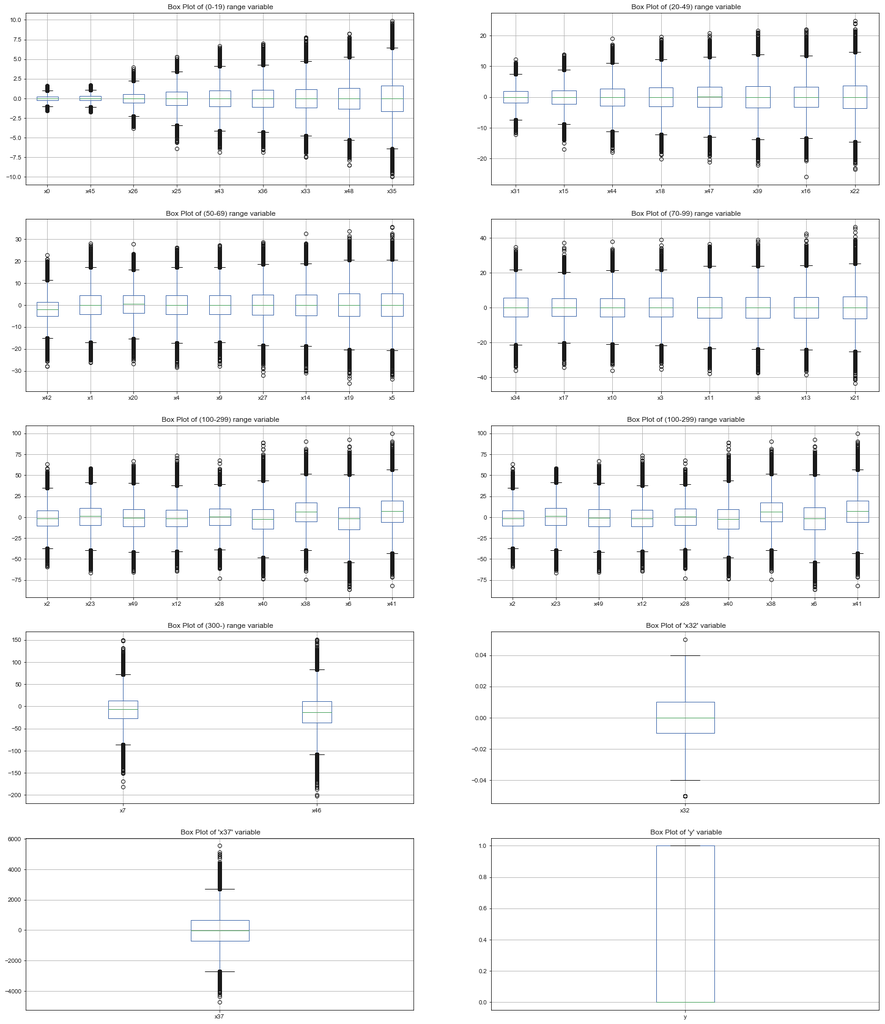

```python
#boxplot for categorical variables
%matplotlib inline
plt.rcParams['figure.figsize']=(25,30)
fig, ax = plt.subplots(5,2, sharey=False) #create subplots that does share the y-axis scale
sns.set()

df_raw[continuous_range_0to19].boxplot(ax=ax[0,0]) ; ax[0,0].set_title(" Box Plot of (0-19) range variable");
df_raw[continuous_range_20to49].boxplot(ax=ax[0,1]) ; ax[0,1].set_title(" Box Plot of (20-49) range variable");

df_raw[continuous_range_50to69].boxplot(ax=ax[1,0]) ; ax[1,0].set_title(" Box Plot of (50-69) range variable");
df_raw[continuous_range_70to99].boxplot(ax=ax[1,1]) ; ax[1,1].set_title(" Box Plot of (70-99) range variable");

df_raw[continuous_range_100to299].boxplot(ax=ax[2,0]) ; ax[2,0].set_title(" Box Plot of (100-299) range variable");
df_raw[continuous_range_100to299].boxplot(ax=ax[2,1]) ; ax[2,1].set_title(" Box Plot of (100-299) range variable");

df_raw[continuous_range_300plus].boxplot(ax=ax[3,0]) ; ax[3,0].set_title(" Box Plot of (300-) range variable");
df_raw[['x32']].boxplot(ax=ax[3,1]) ; ax[3,1].set_title(" Box Plot of 'x32' variable");

df_raw[['x37']].boxplot(ax=ax[4,0]) ; ax[4,0].set_title(" Box Plot of 'x37' variable");
df_raw[['y']].boxplot(ax=ax[4,1]) ; ax[4,1].set_title(" Box Plot of 'y' variable");

plt.show()

# sns.boxplot(x=cred[['PAY_0','PAY_2','PAY_3','PAY_4','PAY_5','PAY_6']],ax=ax[1,0]) ; ax[1,0].set_title('Box Plot of Payment Status (Sept - Apr)')
# sns.boxplot(y=cred['AGE'], ax=ax[0,1]); ax[0,1].set_title('Box Plot of AGE')
```

Because response variable 'y' are only 0 and 1, we can change its dtype to uint8. For all others columns with float64 dtype, we observe that min is not lower than 10^-4 and max is not larger than 10^4. We also do not need a better than seven digits of decimals for these columns, so we will change theirs dtype to float32. We will leave those columns with string, datetime, currency dtype as is for now. These are columns 'x24', 'x29', 'x30', 'x32', and 'x37'.

There are missing data. These plots confirm that the exploratory variables are symmetrical and have normal distribution.

Each of the explanatory variable column does not have all 160000 entries with the correct types. Meaning, there are missing data or data with inappropriate types. The response variable column 'y' has no missing data.

```python
# reduce data type of continuous features to have float32
df_raw[continuous_features] = df_raw[continuous_features].astype(np.float32)
df_raw.info(verbose=True, null_counts=True) #this will print the null_counts
```

```
<class 'pandas.core.frame.DataFrame'>
RangeIndex: 160000 entries, 0 to 159999
Data columns (total 51 columns):
x0     159974 non-null float32
x1     159975 non-null float32
x2     159962 non-null float32
x3     159963 non-null float32
x4     159974 non-null float32
x5     159963 non-null float32
x6     159974 non-null float32
x7     159973 non-null float32
x8     159979 non-null float32
x9     159970 non-null float32
x10    159957 non-null float32
x11    159970 non-null float32
x12    159964 non-null float32
x13    159969 non-null float32
x14    159966 non-null float32
x15    159965 non-null float32
x16    159974 non-null float32
x17    159973 non-null float32
x18    159960 non-null float32
x19    159965 non-null float32
x20    159962 non-null float32
x21    159971 non-null float32
x22    159973 non-null float32
x23    159953 non-null float32
x24    159972 non-null object
x25    159978 non-null float32
x26    159964 non-null float32
x27    159970 non-null float32
x28    159965 non-null float32
x29    159970 non-null object
x30    159970 non-null object
x31    159961 non-null float32
x32    159969 non-null float32
x33    159959 non-null float32
x34    159959 non-null float32
x35    159970 non-null float32
x36    159973 non-null float32
x37    159977 non-null float32
x38    159969 non-null float32
x39    159977 non-null float32
x40    159964 non-null float32
x41    159960 non-null float32
x42    159974 non-null float32
x43    159963 non-null float32
x44    159960 non-null float32
x45    159971 non-null float32
x46    159969 non-null float32
x47    159963 non-null float32
x48    159968 non-null float32
x49    159968 non-null float32
y      160000 non-null int64
dtypes: float32(47), int64(1), object(3)
memory usage: 33.6+ MB
```

Each of the explanatory variable column does not have all 160000 entries with the correct types. Meaning, there are missing data or data with inappropriate types. The response variable column 'y' has no missing data.

```python
size_it(df_raw)
```

```
33.00 Megabyte
```

```python
#print out the clean dataset and save the file
df_raw.to_csv('./final_project_cleaned.csv')
```

# IV. Data Understanding

Back to top

```python
# We can cast types{} to dtype when read in the .csv file to reduce size of data and test_data
# we will use all the data to train
# data=pd.read_csv("final_project.csv", dtype=types)
data_cleaned=pd.read_csv("final_project_cleaned.csv")
```

```python
data_cleaned.head()
```

|  | Unnamed: 0 | x0 | x1 | x2 | x3 | x4 | x5 | x6 | x7 | x8 | ... | x41 | x42 | x43 | x44 | x45 | x46 | x47 | x48 | x49 | y |
| --- | --- | --- | --- | --- | --- | --- | --- | --- | --- | --- | --- | --- | --- | --- | --- | --- | --- | --- | --- | --- | --- |
| 0 | 0 | -0.166563 | -3.961588 | 4.621113 | 2.481908 | -1.800135 | 0.804684 | 6.718751 | -14.789996 | -1.040673 | ... | -1.497117 | 5.414063 | -2.325655 | 1.674827 | -0.264332 | 60.781425 | -7.689696 | 0.151589 | -8.040167 | 0 |
| 1 | 1 | -0.149894 | -0.585676 | 27.839855 | 4.152333 | 6.426802 | -2.426943 | 40.477060 | -6.725709 | 0.896421 | ... | 36.292790 | 4.490914 | 0.762561 | 6.526661 | 1.007927 | 15.805696 | -4.896678 | -0.320283 | 16.719975 | 0 |
| 2 | 2 | -0.321707 | -1.429819 | 12.251561 | 6.586874 | -5.304647 | -11.311089 | 17.812849 | 11.060572 | 5.325881 | ... | -0.368491 | 9.088863 | -0.689886 | -2.731118 | 0.754200 | 30.856417 | -7.428573 | -2.090804 | -7.869421 | 0 |
| 3 | 3 | -0.245594 | 5.076677 | -24.149632 | 3.637307 | 6.505811 | 2.290224 | -35.111750 | -18.913593 | -0.337041 | ... | 15.691545 | -7.467775 | 2.940790 | -6.424112 | 0.419776 | -72.424570 | 5.361375 | 1.806070 | -7.670846 | 0 |
| 4 | 4 | -0.273366 | 0.306326 | -11.352592 | 1.676758 | 2.928441 | -0.616824 | -16.505817 | 27.532282 | 1.199715 | ... | -13.911297 | -5.229937 | 1.783928 | 3.957801 | -0.096988 | -14.085435 | -0.208351 | -0.894942 | 15.724742 | 1 |

5 rows × 52 columns

```python
# as the index object (the columns index) is already regarded as list-like.
data_cleaned.drop(data_cleaned.columns[[0]], axis=1, inplace=True)
```

```python
#check is there is any row has at least 1 missing data NaN
# data_cleaned
print data_cleaned.isnull().any(axis=1).sum()
data_cleaned[data_cleaned.isnull().any(axis = 1)].head()
# 1608 rows with at least 1 missing value
```

```
1608
```

|  | x0 | x1 | x2 | x3 | x4 | x5 | x6 | x7 | x8 | x9 | ... | x41 | x42 | x43 | x44 | x45 | x46 | x47 | x48 | x49 | y |
| --- | --- | --- | --- | --- | --- | --- | --- | --- | --- | --- | --- | --- | --- | --- | --- | --- | --- | --- | --- | --- | --- |
| 29 | -0.321393 | -5.910640 | 6.243552 | -12.936754 | 4.847573 | 11.270850 | 9.077655 | -33.353070 | -5.373054 | 3.055697 | ... | 45.536118 | 5.295248 | NaN | -7.541517 | 0.202396 | -7.226681 | -2.508254 | -3.089376 | -0.269219 | 0 |
| 48 | -0.927155 | -7.290313 | 6.049319 | -3.980340 | -12.851658 | 2.197959 | 8.795256 | NaN | 1.399448 | -0.199977 | ... | 13.029897 | -2.101706 | -0.150942 | -1.161704 | -0.600030 | -21.211359 | 7.546942 | -0.504204 | -4.783417 | 0 |
| 126 | 0.327565 | -0.544186 | -6.928746 | -5.659393 | -3.423373 | -1.850306 | -10.073876 | -8.432450 | 24.492094 | -5.653426 | ... | 16.366108 | -9.924910 | -0.144486 | -1.511031 | -0.057357 | -69.130264 | 1.264002 | 0.317753 | 6.095716 | 0 |
| 151 | 1.062457 | 0.178589 | -1.579185 | -6.073041 | -4.328384 | -12.455219 | -2.296016 | -60.919563 | -10.490058 | 1.430530 | ... | 19.662730 | -8.943095 | 0.503985 | 2.924478 | -0.375100 | -31.947110 | 6.230095 | -2.717568 | -11.463634 | 1 |
| 152 | -0.708330 | 4.782119 | -4.878719 | -0.415667 | -8.783685 | 4.117973 | -7.093290 | 40.410110 | -18.559044 | 5.335397 | ... | -13.945911 | -5.367317 | -0.720417 | 4.093962 | NaN | -64.118230 | -5.258002 | 1.241856 | 1.561127 | 0 |

5 rows × 51 columns

The total of rows with missing value is 1608 rows. This is about 1% of the 160k entries data.

```python
# print out all the missing columns
# data.isnull().sum(axis = 0).max() # max 47 missing - x23
data_cleaned.isnull().sum(axis = 0).sort_values()
```

```
y       0
x8     21
x25    22
x37    23
x39    23
x1     25
x0     26
x16    26
x42    26
x4     26
x6     26
x17    27
x36    27
x22    27
x7     27
x24    28
x21    29
x45    29
x30    30
x29    30
x27    30
x9     30
x11    30
x35    30
x38    31
x13    31
x46    31
x32    31
x48    32
x49    32
x14    34
x19    35
x15    35
x28    35
x40    36
x26    36
x12    36
x43    37
x47    37
x5     37
x3     37
x2     38
x20    38
x31    39
x41    40
x18    40
x44    40
x33    41
x34    41
x10    43
x23    47
dtype: int64
```

This shows the amound of rows with missing value. 'x23' has the most missing rows with 47 rows.

```python
#checking for duplicates:
data_cleaned.duplicated().sum()
```

```
0
```

There is no duplicate row.

```python
# sort the data by continent, month, days, etc.
data_sort = data_cleaned.sort_values(['x24','x29', 'x30',
                              u'x0', u'x1', u'x2', u'x3', u'x4', u'x5', u'x6', u'x7', u'x8', u'x9', u'x10',
                               u'x11', u'x12', u'x13', u'x14', u'x15', u'x16', u'x17', u'x18', u'x19', u'x20',
                               u'x21', u'x22', u'x23', u'x25', u'x26', u'x27', u'x28', u'x31', u'x32', u'x33',
                               u'x34', u'x35', u'x36', u'x37', u'x38', u'x39',u'x40', u'x41', u'x42', u'x43',
                               u'x44', u'x45', u'x46', u'x47', u'x48', u'x49'], na_position='last')
data_sort.tail(10)
```

|  | x0 | x1 | x2 | x3 | x4 | x5 | x6 | x7 | x8 | x9 | ... | x41 | x42 | x43 | x44 | x45 | x46 | x47 | x48 | x49 | y |
| --- | --- | --- | --- | --- | --- | --- | --- | --- | --- | --- | --- | --- | --- | --- | --- | --- | --- | --- | --- | --- | --- |
| 36301 | 0.119338 | 8.922922 | 16.323248 | 4.962071 | 0.495927 | 2.411771 | 23.732775 | 4.920965 | 1.310472 | -0.450529 | ... | -1.776110 | -12.533615 | -0.636971 | -1.105669 | -0.011680 | -67.149300 | -1.403909 | -3.007193 | -24.467705 | 1 |
| 31112 | 0.474457 | 4.397193 | -21.771150 | -9.642420 | -1.720646 | -0.331295 | -31.653618 | -73.341890 | 5.222198 | 12.713231 | ... | 10.403302 | -13.541115 | -2.555547 | 4.271317 | -0.090800 | -17.042970 | -1.308712 | 0.752217 | -7.953823 | 1 |
| 62410 | -0.334016 | -0.976048 | -0.423331 | -1.338120 | -0.434470 | -9.312079 | -0.615492 | 13.085968 | -2.326017 | 4.675254 | ... | -10.070951 | -1.646312 | -2.469946 | 2.440217 | 0.371976 | -40.562855 | 1.251352 | 0.052794 | -16.599934 | 0 |
| 33247 | 0.072650 | -3.016108 | -6.082486 | 17.605106 | 4.996767 | 9.097960 | -8.843477 | -14.650558 | 6.017444 | -1.901501 | ... | -4.194881 | 0.865721 | 0.694207 | 8.011157 | -0.207016 | 31.006420 | 9.086374 | 0.371348 | 12.280221 | 0 |
| 59593 | 0.116587 | 0.089748 | -2.446196 | -6.487805 | 0.628920 | -0.917951 | -3.556585 | -45.005688 | 26.639110 | 7.883479 | ... | 31.268366 | 5.941339 | 1.468780 | 2.048799 | -0.321226 | 48.068108 | -3.184976 | 2.098070 | 19.304527 | 1 |
| 54785 | 0.329696 | 10.705760 | 4.588123 | 7.725557 | 0.878883 | 5.945638 | 6.670786 | 10.460490 | 8.316429 | 13.037018 | ... | -13.972064 | 6.995060 | -2.892459 | -0.857841 | -0.581355 | 46.610195 | 4.762538 | 1.106116 | 13.529853 | 0 |
| 102261 | 0.391648 | 10.169498 | 16.225359 | 10.148273 | 1.181442 | -1.806879 | 23.590452 | 59.810060 | 8.136056 | -1.340492 | ... | -1.924462 | 3.900647 | -0.269205 | -0.440187 | 0.512232 | -34.027237 | -1.858839 | -2.815543 | -12.508802 | 1 |
| 116123 | 0.632526 | 0.172535 | -2.166746 | 3.400813 | 6.590755 | -13.832885 | -3.150285 | -16.715270 | -5.555561 | -3.278799 | ... | 13.208253 | -2.424400 | -1.594492 | 2.178945 | -0.747217 | -7.245642 | -3.992022 | 0.751936 | 2.608647 | 0 |
| 25611 | 0.363907 | -5.866806 | 9.807587 | -10.114038 | 1.600764 | 15.689561 | 14.259495 | 14.035633 | 2.923251 | 0.936867 | ... | 25.601480 | -2.525292 | -0.476684 | -4.767721 | 0.314672 | -11.865158 | 9.102946 | 3.168309 | -17.074938 | 1 |
| 47431 | -0.140303 | -0.115842 | -17.467710 | -12.526853 | -0.780694 | 3.473353 | -25.396740 | -83.393430 | 6.622084 | 0.913771 | ... | 27.526848 | -20.648062 | 1.137355 | 1.769570 | 0.224669 | -56.190224 | -2.606984 | 1.443612 | -12.503040 | 0 |

10 rows × 51 columns

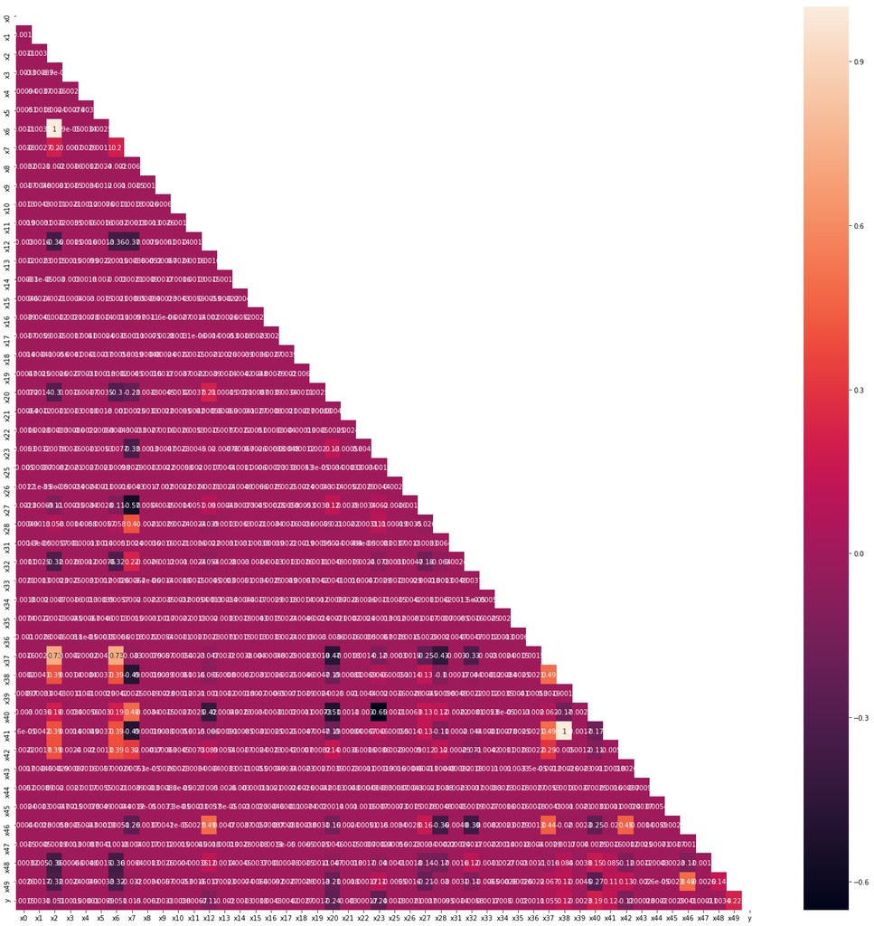

```python
# Heat Map of all correlation of all the attributes - before any one-hot coding and with all the missing value
import matplotlib.pylab as plt
import seaborn as sns
plt.figure(figsize=(25,25))
#sns.heatmap(df_copy.corr(), annot =True)

# trying to mask the upper part
mask = np.zeros_like(data_sort.corr(), dtype=np.bool)
mask[np.triu_indices_from(mask)] = True

# Draw the heatmap with the mask and correct aspect ratio
sns.heatmap(data_sort.corr(), mask=mask,annot =True)
plt.show()
```

From this correlation map, pair columns 'x2' and 'x6' , pair column x41 and x38 are linearly correlated. Since we do not know the meaning of these columns, we will leave them as is. However, multi-collinearity may cause our model's sensitivity to be magnified. Especially if these variables have high weight.

Columns x37 is also highly correlated to columns x2 and x6.

## 1. Exploring Data Missingness

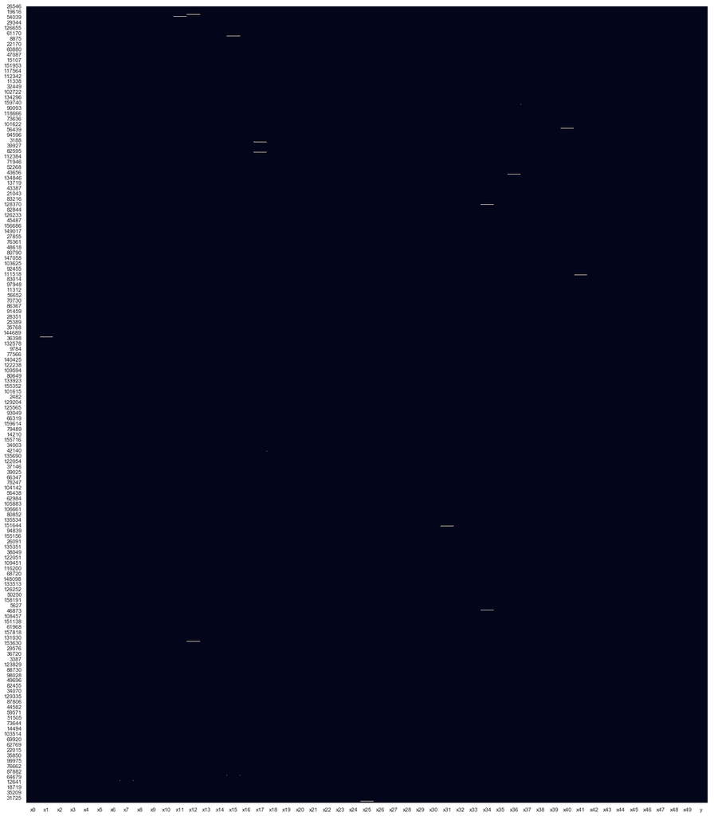

```python
# heatmap
import missingno as msno
sns.heatmap(data_sort.isnull(), cbar=False)
```

The heatmap does not work great for picking out data completeness relationships between variable pairs with larger relationships in our large datasets. In our data set, it seems that all variables are completed.

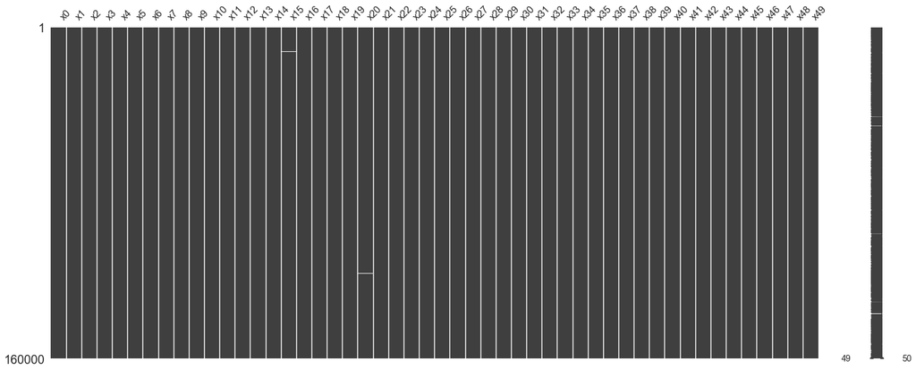

```python
# exclude 'y' since 'y' has no missing data
missingdata_df = data_sort.columns[data_sort.isnull().any()].tolist()
msno.matrix(data_sort[missingdata_df])
```

This nullity matrix is a data-dense display which lets you quickly visually pick out patterns in data completion. In addition to the heatmap, there is a bar on the right side of this diagram. This is a line plot for each row's data completeness. IT summarizes the general shape of the data completeness and points out the maximum and minimum rows.

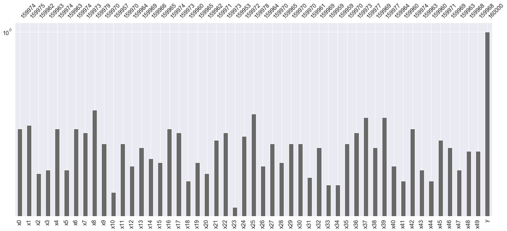

```python
# msno.bar is a simple visualization of nullity by column:
msno.bar(data_sort, log=True)
```

The missingno bar chart is a visualization of the data nullity. We log transformed the data on the y-axis to better visualize features with very large missing values. We can see that 'x23' has the mos missing values, next is 'x10.

```python
# # Dendrogram
# msno.dendrogram(data_sort)
```

## 2. Filling Missing Data

Because of the small amound of missing data, only 1608 vs. 160k entries, we can either drop these rows or fill them with the mean of those continuous variables or the most popular values of those ordinal and categorical variables.

Next, we exam the data sets of the cases where we drop those missing data rows and where we fill NaN with means and popular values.

### Case 1: Removing NaN

```python
data_dropna = data_sort.dropna()
data_dropna.describe()
```

|  | x0 | x1 | x2 | x3 | x4 | x5 | x6 | x7 | x8 | x9 | ... | x41 | x42 | x43 | x44 | x45 | x46 | x47 | x48 | x49 | y |
| --- | --- | --- | --- | --- | --- | --- | --- | --- | --- | --- | --- | --- | --- | --- | --- | --- | --- | --- | --- | --- | --- |
| count | 158392.000000 | 158392.000000 | 158392.000000 | 158392.000000 | 158392.000000 | 158392.000000 | 158392.000000 | 158392.000000 | 158392.000000 | 158392.000000 | ... | 158392.000000 | 158392.000000 | 158392.000000 | 158392.000000 | 158392.000000 | 158392.000000 | 158392.000000 | 158392.000000 | 158392.000000 | 158392.000000 |
| mean | -0.000808 | 0.003705 | -1.148314 | -0.023012 | -0.000266 | 0.013282 | -1.669562 | -7.697877 | -0.028853 | 0.004320 | ... | 6.706030 | -1.832959 | -0.002174 | -0.007254 | 0.000996 | -12.751993 | 0.028262 | 0.000160 | -0.672052 | 0.401195 |
| std | 0.371064 | 6.340297 | 13.274738 | 8.066624 | 6.383306 | 7.672102 | 19.300472 | 30.541562 | 8.904048 | 6.354359 | ... | 18.675642 | 5.110079 | 1.535282 | 4.163766 | 0.396604 | 36.608634 | 4.787974 | 1.935087 | 15.033134 | 0.490142 |
| min | -1.592635 | -26.278301 | -59.394047 | -33.864826 | -28.467535 | -33.822987 | -86.354485 | -181.506970 | -37.691044 | -27.980660 | ... | -82.167220 | -27.933750 | -6.876234 | -17.983488 | -1.753221 | -201.826830 | -21.086334 | -8.490155 | -65.791190 | 0.000000 |
| 25% | -0.251246 | -4.259016 | -10.166609 | -5.453045 | -4.313987 | -5.152419 | -14.781484 | -27.315874 | -6.034095 | -4.260304 | ... | -5.802178 | -5.159340 | -1.039992 | -2.814168 | -0.266369 | -36.432779 | -3.216973 | -1.320800 | -10.929046 | 0.000000 |
| 50% | -0.001818 | 0.010023 | -1.342199 | -0.028470 | -0.001138 | 0.015135 | -1.951457 | -6.959275 | -0.016173 | 0.003098 | ... | 6.847926 | -1.922935 | -0.004279 | -0.012278 | 0.001841 | -12.975088 | 0.036234 | -0.011800 | -0.569139 | 0.000000 |
| 75% | 0.248622 | 4.286606 | 7.878130 | 5.448332 | 4.308644 | 5.191172 | 11.454209 | 12.215119 | 5.978646 | 4.303807 | ... | 19.269856 | 1.452018 | 1.033870 | 2.781096 | 0.269194 | 11.445524 | 3.269134 | 1.318161 | 9.649839 | 1.000000 |
| max | 1.600849 | 27.988178 | 63.545654 | 38.906025 | 26.247812 | 35.550110 | 92.390600 | 149.150630 | 39.049830 | 27.377842 | ... | 100.050430 | 22.668041 | 6.680922 | 19.069760 | 1.669205 | 150.859420 | 20.836853 | 8.226551 | 66.877600 | 1.000000 |

8 rows × 48 columns

**Visualizing pairwise relationships in our dataset**

Pairplot of a sample of 10000 entries of data after dropping all NaN

```python
# %%time
# sns.set()
# sns.pairplot(data_dropna.sample(10000) , hue='y', palette='coolwarm') #hue=’sex’, palette=’coolwarm’
```

**Looking at some of the variables**

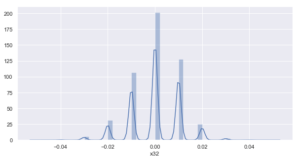

```python
# an example histograms with KDE kernal of 'x32'
plt.rcParams['figure.figsize']=(10,5)
sns.distplot(data_dropna.x32, hist=True, kde=True) # rug=True
# data.hist(column="x32", by="y", bins=50, ax=ax[0,1])
```

Histograms with KDE kernal of 'x32', after dropping NaN, shows normal distribution.

**Check data frequency and possible invalid data of ordinal and categorical variables**

```python
#check each for data frequency and possible invalid data of ordinal and categorical variables
# 'x24' or i == 'x29'or i=='x30' or i=='x32' or i=='x37':
print dict(Counter(data_dropna.x24))
```

```
{'euorpe': 16378, 'america': 4418, 'asia': 137596}
```

```python
print dict(Counter(data_dropna.x29))
```

```
{'Mar': 1221, 'Feb': 139, 'Aug': 29115, 'Nov': 331, 'Apr': 6699, 'January': 9, 'Jun': 40900, 'Dev': 23, 'May': 21708, 'sept.': 10740, 'July': 45122, 'Oct': 2385}
```

```python
print dict(Counter(data_dropna.x30))
```

```
{'thurday': 29164, 'friday': 556, 'tuesday': 27690, 'monday': 484, 'wednesday': 100498}
```

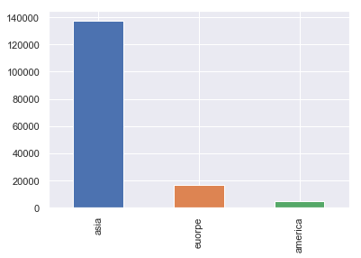

```python
# variables 'x24'
plt.figure(figsize=(6,4))
data_dropna['x24'].value_counts().plot(kind='bar',)
```

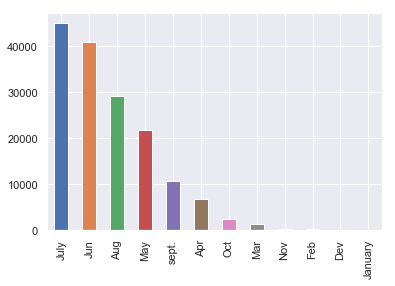

```python
# variables 'x29'
plt.figure(figsize=(6,4))
data_dropna['x29'].value_counts().plot(kind='bar',)
```

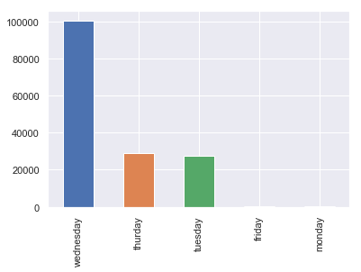

```python
# variables 'x30'
plt.figure(figsize=(6,4))
data_dropna['x30'].value_counts().plot(kind='bar',)
```

### Case 2: Imputate continous variables with their means.

A standard and often very good approach is to replace the missing values with mean, median or mode. This imputation technique works well with when the values are missing completely at random. Since there is no obvious missing pattern, no obvious outliner in our data and variables have normal distribution, replacing the missing values with mean is sufficient.

```python
#make a copy
data_fillna = data_sort.copy()
```

```python
#filling continuous variables with their mean
from sklearn.preprocessing import Imputer
imputer = Imputer(missing_values=np.nan, strategy='mean', axis=0)
# data[['col_name']] = imputer.fit_transform(data[['col_name']])
data_fillna[data_fillna.columns[~data_fillna.columns.isin(['x24' , 'x29', 'x30'])]] = imputer.fit_transform(data_fillna[data_fillna.columns[~data_fillna.columns.isin(['x24' , 'x29', 'x30'])]])
data_fillna.describe()
```

|  | x0 | x1 | x2 | x3 | x4 | x5 | x6 | x7 | x8 | x9 | ... | x41 | x42 | x43 | x44 | x45 | x46 | x47 | x48 | x49 | y |
| --- | --- | --- | --- | --- | --- | --- | --- | --- | --- | --- | --- | --- | --- | --- | --- | --- | --- | --- | --- | --- | --- |
| count | 160000.000000 | 160000.000000 | 160000.000000 | 160000.000000 | 160000.000000 | 160000.000000 | 160000.000000 | 160000.000000 | 160000.000000 | 160000.000000 | ... | 160000.000000 | 160000.000000 | 160000.000000 | 160000.000000 | 160000.000000 | 160000.000000 | 160000.000000 | 160000.000000 | 160000.000000 | 160000.000000 |
| mean | -0.001028 | 0.001358 | -1.150145 | -0.024637 | -0.000549 | 0.013582 | -1.670670 | -7.692795 | -0.030540 | 0.005462 | ... | 6.701076 | -1.833820 | -0.002091 | -0.006250 | 0.000885 | -12.755395 | 0.028622 | -0.000224 | -0.674224 | 0.401231 |
| std | 0.371107 | 6.340137 | 13.271904 | 8.064099 | 6.381775 | 7.669189 | 19.297096 | 30.539687 | 8.900601 | 6.354444 | ... | 18.677861 | 5.110290 | 1.534775 | 4.164075 | 0.396585 | 36.605095 | 4.787604 | 1.935308 | 15.035234 | 0.490149 |
| min | -1.592635 | -26.278301 | -59.394047 | -35.476593 | -28.467535 | -33.822987 | -86.354485 | -181.506970 | -37.691044 | -27.980660 | ... | -82.167220 | -27.933750 | -6.876234 | -17.983488 | -1.753221 | -201.826830 | -21.086334 | -8.490155 | -65.791190 | 0.000000 |
| 25% | -0.251574 | -4.260377 | -10.163721 | -5.452183 | -4.312029 | -5.147177 | -14.777287 | -27.318385 | -6.030219 | -4.259907 | ... | -5.801424 | -5.162268 | -1.039482 | -2.811242 | -0.266411 | -36.425834 | -3.214765 | -1.320470 | -10.930261 | 0.000000 |
| 50% | -0.001980 | 0.004056 | -1.336542 | -0.028386 | -0.000105 | 0.013582 | -1.943830 | -6.961395 | -0.018784 | 0.005462 | ... | 6.835074 | -1.923107 | -0.004096 | -0.009104 | 0.001542 | -12.973675 | 0.034732 | -0.011225 | -0.577987 | 0.000000 |
| 75% | 0.248505 | 4.282958 | 7.868662 | 5.443760 | 4.305730 | 5.188709 | 11.444045 | 12.213263 | 5.971777 | 4.305071 | ... | 19.263640 | 1.452664 | 1.032992 | 2.782384 | 0.268985 | 11.437354 | 3.266938 | 1.317397 | 9.649149 | 1.000000 |
| max | 1.600849 | 27.988178 | 63.545654 | 38.906025 | 26.247812 | 35.550110 | 92.390600 | 149.150630 | 39.049830 | 27.377842 | ... | 100.050430 | 22.668041 | 6.680922 | 19.069760 | 1.669205 | 150.859420 | 20.836853 | 8.226551 | 66.877600 | 1.000000 |

8 rows × 48 columns

**Filling Missing Categorical and Ordinal Values Based on Their Population**

Using the measures of central tendency involves substituting the missing values with the mean or median for numerical variables and the mode for categorical variables. The major limitation of using this method is that it leads to biased estimates of the variances and covariance. The standard errors and test statistics can also be underestimated and overestimated respectively [7].

For continuous variables, because they have normal distribution and our data set is large, filling them with the mean is sufficient. However, to reduce bias, we fill those missing categorical and ordinal values based on their distribution or population of each category.

**Replacing missing values in 'x29'**

There 30 missing data in this 'x29' variable. We will replace these with the below ratio:

Prorated ratio - Summary Table

[output not shown]

```python
# replacing na values in 'x29'
data_fillna['x29'].fillna("July", inplace = True, limit = 10)
data_fillna['x29'].fillna("Jun", inplace = True, limit = 9)
data_fillna['x29'].fillna("Aug", inplace = True, limit = 6)
data_fillna['x29'].fillna("May", inplace = True, limit = 4)
data_fillna['x29'].fillna("sept.", inplace = True, limit = 1)

#
data_fillna['x29'].value_counts()
data_fillna[['x29']].info()
```

```
<class 'pandas.core.frame.DataFrame'>
Int64Index: 160000 entries, 26546 to 47431
Data columns (total 1 columns):
x29    160000 non-null object
dtypes: object(1)
memory usage: 2.4+ MB
```

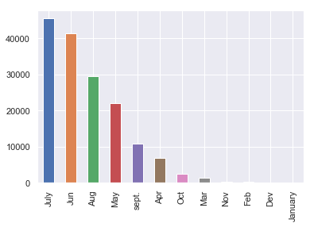

```python
plt.figure(figsize=(6,4))
data_fillna['x29'].value_counts().plot(kind='bar',)
```

**Replacing missing values in 'x30'**

```python
# replacing na values in 'x30'
data_fillna['x30'].fillna("wednesday", inplace = True, limit = 19)
data_fillna['x30'].fillna("thurday", inplace = True, limit = 6)
data_fillna['x30'].fillna("tuesday", inplace = True, limit = 5)
```

```python
data_fillna['x30'].value_counts()
data_fillna[['x30']].info()
```

```
<class 'pandas.core.frame.DataFrame'>
Int64Index: 160000 entries, 26546 to 47431
Data columns (total 1 columns):
x30    160000 non-null object
dtypes: object(1)
memory usage: 2.4+ MB
```

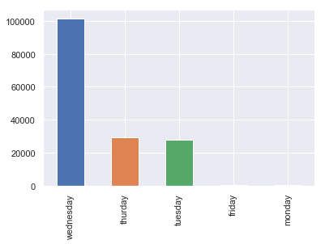

```python
plt.figure(figsize=(6,4))
data_fillna['x30'].value_counts().plot(kind='bar',)
```

**Replacing missing values in 'x24'**

```python
# replacing na values in 'x24'
data_fillna['x24'].fillna("asia", inplace = True, limit = 24)
data_fillna['x24'].fillna("euorpe", inplace = True, limit = 3)
data_fillna['x24'].fillna("america", inplace = True, limit = 1)

data_fillna[['x24']].info()
data_fillna['x24'].value_counts()
```

```
<class 'pandas.core.frame.DataFrame'>
Int64Index: 160000 entries, 26546 to 47431
Data columns (total 1 columns):
x24    160000 non-null object
dtypes: object(1)
memory usage: 2.4+ MB
```

```
asia       138989
euorpe      16541
america      4470
Name: x24, dtype: int64
```

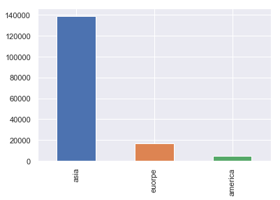

```python
plt.figure(figsize=(6,4))
data_fillna['x24'].value_counts().plot(kind='bar',)
```

```python
data_fillna.describe()
```

|  | x0 | x1 | x2 | x3 | x4 | x5 | x6 | x7 | x8 | x9 | ... | x41 | x42 | x43 | x44 | x45 | x46 | x47 | x48 | x49 | y |
| --- | --- | --- | --- | --- | --- | --- | --- | --- | --- | --- | --- | --- | --- | --- | --- | --- | --- | --- | --- | --- | --- |
| count | 160000.000000 | 160000.000000 | 160000.000000 | 160000.000000 | 160000.000000 | 160000.000000 | 160000.000000 | 160000.000000 | 160000.000000 | 160000.000000 | ... | 160000.000000 | 160000.000000 | 160000.000000 | 160000.000000 | 160000.000000 | 160000.000000 | 160000.000000 | 160000.000000 | 160000.000000 | 160000.000000 |
| mean | -0.001028 | 0.001358 | -1.150145 | -0.024637 | -0.000549 | 0.013582 | -1.670670 | -7.692795 | -0.030540 | 0.005462 | ... | 6.701076 | -1.833820 | -0.002091 | -0.006250 | 0.000885 | -12.755395 | 0.028622 | -0.000224 | -0.674224 | 0.401231 |
| std | 0.371107 | 6.340137 | 13.271904 | 8.064099 | 6.381775 | 7.669189 | 19.297096 | 30.539687 | 8.900601 | 6.354444 | ... | 18.677861 | 5.110290 | 1.534775 | 4.164075 | 0.396585 | 36.605095 | 4.787604 | 1.935308 | 15.035234 | 0.490149 |
| min | -1.592635 | -26.278301 | -59.394047 | -35.476593 | -28.467535 | -33.822987 | -86.354485 | -181.506970 | -37.691044 | -27.980660 | ... | -82.167220 | -27.933750 | -6.876234 | -17.983488 | -1.753221 | -201.826830 | -21.086334 | -8.490155 | -65.791190 | 0.000000 |
| 25% | -0.251574 | -4.260377 | -10.163721 | -5.452183 | -4.312029 | -5.147177 | -14.777287 | -27.318385 | -6.030219 | -4.259907 | ... | -5.801424 | -5.162268 | -1.039482 | -2.811242 | -0.266411 | -36.425834 | -3.214765 | -1.320470 | -10.930261 | 0.000000 |
| 50% | -0.001980 | 0.004056 | -1.336542 | -0.028386 | -0.000105 | 0.013582 | -1.943830 | -6.961395 | -0.018784 | 0.005462 | ... | 6.835074 | -1.923107 | -0.004096 | -0.009104 | 0.001542 | -12.973675 | 0.034732 | -0.011225 | -0.577987 | 0.000000 |
| 75% | 0.248505 | 4.282958 | 7.868662 | 5.443760 | 4.305730 | 5.188709 | 11.444045 | 12.213263 | 5.971777 | 4.305071 | ... | 19.263640 | 1.452664 | 1.032992 | 2.782384 | 0.268985 | 11.437354 | 3.266938 | 1.317397 | 9.649149 | 1.000000 |
| max | 1.600849 | 27.988178 | 63.545654 | 38.906025 | 26.247812 | 35.550110 | 92.390600 | 149.150630 | 39.049830 | 27.377842 | ... | 100.050430 | 22.668041 | 6.680922 | 19.069760 | 1.669205 | 150.859420 | 20.836853 | 8.226551 | 66.877600 | 1.000000 |

8 rows × 48 columns

**Visualizing pairwise relationships in our dataset**

Pairplot of a sample of 10000 entries of data after filling NaN with means and most populous values

```python
# %%time
# sns.set()
# sns.pairplot(data_fillna.sample(10000) , hue='y', palette='coolwarm') #hue=’sex’, palette=’coolwarm’
```

```python
data_fillna.to_csv("final_project_fillna.csv")
```

## 3. Data Exploration

```python
# There is no nan in response variable column y
# print dict(Counter(data.y))
data_fillna = pd.read_csv("final_project_fillna.csv")
data_fillna.drop(data_fillna.columns[[0]], axis=1, inplace=True)
data_fillna.head()
```

|  | x0 | x1 | x2 | x3 | x4 | x5 | x6 | x7 | x8 | x9 | ... | x41 | x42 | x43 | x44 | x45 | x46 | x47 | x48 | x49 | y |
| --- | --- | --- | --- | --- | --- | --- | --- | --- | --- | --- | --- | --- | --- | --- | --- | --- | --- | --- | --- | --- | --- |
| 0 | 0.433876 | 2.910562 | 22.310555 | 6.540488 | 2.903073 | -6.726396 | 32.437870 | 43.500313 | -10.792003 | -8.732554 | ... | 13.735566 | -7.828786 | -1.126729 | 10.997763 | 0.419308 | -127.986840 | 6.176637 | -0.473673 | -35.919422 | 0.0 |
| 1 | -1.112501 | -3.450738 | 10.781852 | 6.184937 | 5.118608 | 0.839718 | 15.676002 | 57.169147 | 2.573205 | 8.433345 | ... | -4.159862 | -4.438887 | -0.697715 | 0.502843 | -1.093398 | -93.097830 | -7.113892 | 1.280425 | -15.563792 | 0.0 |
| 2 | -0.741442 | 3.444253 | -16.737438 | -7.921415 | 1.373968 | 13.904434 | -24.334978 | 13.307492 | 7.669094 | 3.515297 | ... | -16.879923 | -12.161209 | 1.273872 | 5.708061 | 0.413055 | -101.708600 | -12.755991 | 1.655852 | -18.087776 | 0.0 |
| 3 | -0.475384 | 12.301063 | 9.453689 | -14.259572 | 0.693288 | 1.053640 | 13.744953 | -52.310844 | 3.137198 | 0.917666 | ... | 38.963997 | -6.768979 | -0.764783 | 3.737873 | -0.347535 | -102.945305 | -0.605963 | -2.558737 | -25.268002 | 0.0 |
| 4 | -0.456786 | 1.687705 | 0.134832 | -0.499670 | -0.639894 | 3.889339 | 0.196036 | -1.911663 | 3.620222 | 8.274778 | ... | 1.429083 | -6.723292 | -1.590958 | -6.983837 | -0.634940 | -84.423980 | 0.850055 | -0.833823 | -13.953359 | 0.0 |

5 rows × 51 columns

```python
#checking for duplicates:
data_fillna.duplicated().sum()
```

```
0
```

**There is no duplicate**

```python
data_fillna['y'].value_counts()
```

```
0.0    95803
1.0    64197
Name: y, dtype: int64
```

```python
#check each for data frequency and possible invalid data of ordinal and categorical variables
# 'x24' or i == 'x29'or i=='x30' or i=='x32' or i=='x37':
print dict(Counter(data_fillna.x24))
```

```
{'euorpe': 16541, 'america': 4470, 'asia': 138989}
```

```python
print dict(Counter(data_fillna.x29))
```

```
{'Mar': 1231, 'Feb': 140, 'Aug': 29412, 'Nov': 337, 'Apr': 6761, 'January': 9, 'Jun': 41338, 'Dev': 23, 'May': 21943, 'sept.': 10820, 'July': 45579, 'Oct': 2407}
```

```python
print dict(Counter(data_fillna.x30))
```

```
{'thurday': 29435, 'friday': 564, 'tuesday': 27959, 'monday': 488, 'wednesday': 101554}
```

```python
# Rearrange the columns to have y at index 0
data_fillna = data_fillna[['y', u'x0', u'x1', u'x2', u'x3', u'x4', u'x5', u'x6', u'x7', u'x8', u'x9',
       u'x10', u'x11', u'x12', u'x13', u'x14', u'x15', u'x16', u'x17', u'x18',
       u'x19', u'x20', u'x21', u'x22', u'x23', u'x24', u'x25', u'x26', u'x27',
       u'x28', u'x29', u'x30', u'x31', u'x32', u'x33', u'x34', u'x35', u'x36',
       u'x37', u'x38', u'x39', u'x40', u'x41', u'x42', u'x43', u'x44', u'x45',
       u'x46', u'x47', u'x48', u'x49']]
```

[output not shown]

### a. Explore Attribute Relationships with 'y'

**Relationship betweeb x23 vs. y**

```
-----------default count-----------
y            False  True
x23_qrange
very low     11153  15514
low          12902  13765
middle       15281  11385
lower high   17220   9447
high         18978   7688
very higher  20269   6398
------normalized y ratio-----
y               False     True
x23_qrange
very low     0.418232  0.581768
low          0.483819  0.516181
middle       0.573052  0.426948
lower high   0.645742  0.354258
high         0.711693  0.288307
very higher  0.760078  0.239922
CPU times: user 197 ms, sys: 12 ms, total: 209 ms
Wall time: 206 ms
```

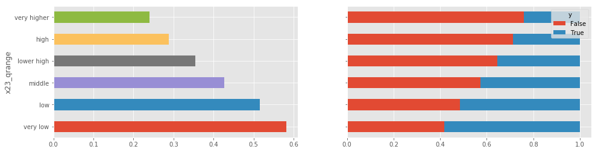

```python
%%time

# we use quantile cut (qcut) here because we want to see how the default status varies for each bins with equals of data
data_fillna['x23_qrange'] = pd.qcut(data_fillna.x23,6,labels=['very low', 'low', 'middle',
                                                            'lower high','high','very higher']) # this creates a new variable

# look at the 'y' distribution within each quantile group.
plt.rcParams['figure.figsize']=(16,4) #set the figure size
fig, ax = plt.subplots(1,2, sharey=True)

plt.style.use('ggplot')
x23_grouped = data_fillna.groupby(by='x23_qrange')

#crosstab
y_x23_xtab= pd.crosstab(data_fillna['x23_qrange'],data_fillna.y.astype(bool))
print ('-----------default count-----------')
print y_x23_xtab

y_rate_x23 = x23_grouped.y.sum()/x23_grouped.y.count()
# default_rate_SD = df_grouped.Survived.sum() / df_grouped.Survived.count()
y_rate_x23.plot(kind='barh', ax=ax[0])

# nomalized
y_x23_norm = y_x23_xtab.div(y_x23_xtab.sum(1),axis=0) # normalize the value, astype(float)
print ('------normalized y ratio-----')
print y_x23_norm

# #nomalized stacked plot
y_x23_norm.plot(kind='barh',stacked=True, ax=ax[1])
```

The above plots show there is evidence of linear relationship between 'x23' and 'y'. When 'x23' value is smaller, there is more True or "1" count in the response'y'. As 'x23' value decreases, the amount of True count in response 'y' increases.

### b. Explore Joint Attributes Relationship:

Examinine the relatioship between 'x20', 'x23'and 'y' with bar plots.

```
-----------default count-----------
y                        False  True
x20_qrange  x23_qrange
very low    very low       981   6044
            low           1459   3971
            middle        1744   2669
            lower high    1868   1793
            high          2039   1171
            very higher   2204    724
low         very low      1115   3632
            low           1669   3040
            middle        2017   2350
            lower high    2489   1757
            high          2912   1281
            very higher   3422    983
middle      very low      1476   2415
            low           1771   2378
            middle        2468   2037
            lower high    2838   1666
            high          3316   1328
            very higher   3905   1068
lower high  very low      2054   1597
            low           2320   1855
            middle        2642   1648
            lower high    3138   1524
            high          3499   1345
            very higher   3846   1199
high        very low      2654   1039
            low           2643   1391
            middle        3059   1419
            lower high    3279   1363
            high          3679   1223
            very higher   3763   1154
very higher very low      2873    787
            low           3040   1130
            middle        3351   1262
            lower high    3608   1344
            high          3533   1340
            very higher   3129   1270
------normalized default ratio-----
```

[output cut: 23 more lines]

```
            lower high   0.673102  0.326898
            high         0.722337  0.277663
            very higher  0.762339  0.237661
high        very low     0.718657  0.281343
            low          0.655181  0.344819
            middle       0.683117  0.316883
            lower high   0.706377  0.293623
            high         0.750510  0.249490
            very higher  0.765304  0.234696
very higher very low     0.784973  0.215027
            low          0.729017  0.270983
            middle       0.726425  0.273575
            lower high   0.728595  0.271405
            high         0.725015  0.274985
            very higher  0.711298  0.288702
```

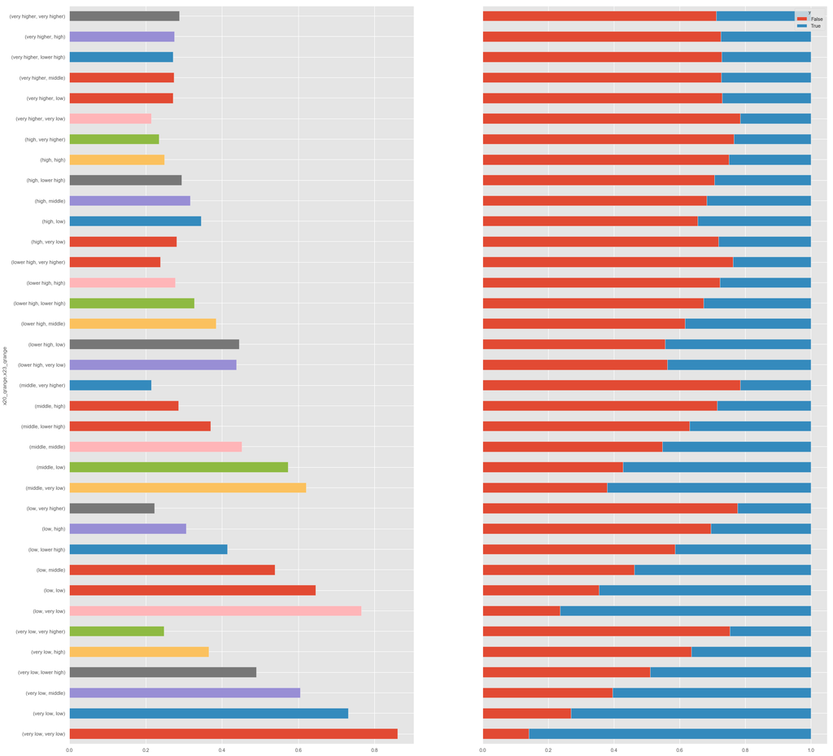

```python
#Let's group SEX and AGE and visualize the default status with bar plots. [2]
plt.rcParams['figure.figsize']=(30,30) #set the figure size
fig, ax = plt.subplots(1,2, sharey=True)

# we use quantile cut (qcut) here because we want to see how the default status varies for each bins with equals of data
data_fillna['x20_qrange'] = pd.qcut(data_fillna.x20,6,labels=['very low', 'low', 'middle',
                                                            'lower high','high','very higher']) # this creates a new variable

plt.style.use('ggplot')
# now lets group
SA_grouped = data_fillna.groupby(['x20_qrange','x23_qrange'])

default_rate_SA = SA_grouped.y.sum()/SA_grouped.y.count()
axis = default_rate_SA.plot(kind='barh', ax=ax[0])

#crosstab
default_nodefault_SA = pd.crosstab([data_fillna['x20_qrange'],data_fillna['x23_qrange']]
                                   ,data_fillna.y.astype(bool))
print ('-----------default count-----------')
print default_nodefault_SA

# normalized
default_nodefault_SA_norm = default_nodefault_SA.div(default_nodefault_SA.sum(1).astype(float),
                             axis=0) # normalize the value
print ('------normalized default ratio-----')
print default_nodefault_SA_norm

#normalized stacked plot
axis2 = default_nodefault_SA_norm.plot(kind='barh',
                   stacked=True, ax=ax[1])
```

The above plots show there is evidence of linear relationship between 'x23', 'x20' and 'y'.

1. When 'x20' value is very high or high, the linear relationship between 'x23', 'x20' and 'y' is diminished.
2. When 'x20' value is lower, the linear relatioship between 'x23', 'x20' and 'y' is similar to that of 'x23' and 'y'. Meaning, when 'x23' and 'x20' value decreases, the amount of True count in response 'y' increases.

**Examinine the relatioship between 'x20', 'x23', 'X48' and 'y' with bar plots**

```
-----------default count-----------
y                                    False  True
x20_qrange  x23_qrange  x48_qrange
very low    very low    very low       152    461
                        low            154    875
                        middle         166   1082
                        lower high     188   1253
                        high           155   1306
                        very higher    166   1067
            low         very low       195    423
                        low            224    539
                        middle         268    605
                        lower high     248    747
                        high           278    843
                        very higher    246    814
            middle      very low       224    319
                        low            267    337
                        middle         275    359
                        lower high     316    444
                        high           356    532
                        very higher    306    678
            lower high  very low       250    279
                        low            309    215
                        middle         304    204
                        lower high     336    237
                        high           331    367
                        very higher    338    491
            high        very low       275    266
                        low            316    146
                        middle         353    123
                        lower high     335    143
                        high           358    193
                        very higher    402    300
...                                    ...    ...
very higher low         very low       581    113
                        low            603    192
                        middle         519    178
                        lower high     449    226
                        high           402    206
                        very higher    486    215
```

[output cut: 77 more lines]

```
                        very higher  0.799547  0.200453
            high        very low     0.611111  0.388889
                        low          0.689394  0.310606
                        middle       0.701005  0.298995
                        lower high   0.719665  0.280335
                        high         0.782082  0.217918
                        very higher  0.832604  0.167396
            very higher very low     0.440000  0.560000
                        low          0.628111  0.371889
                        middle       0.728228  0.271772
                        lower high   0.744681  0.255319
                        high         0.821530  0.178470
                        very higher  0.877390  0.122610

[216 rows x 2 columns]
```

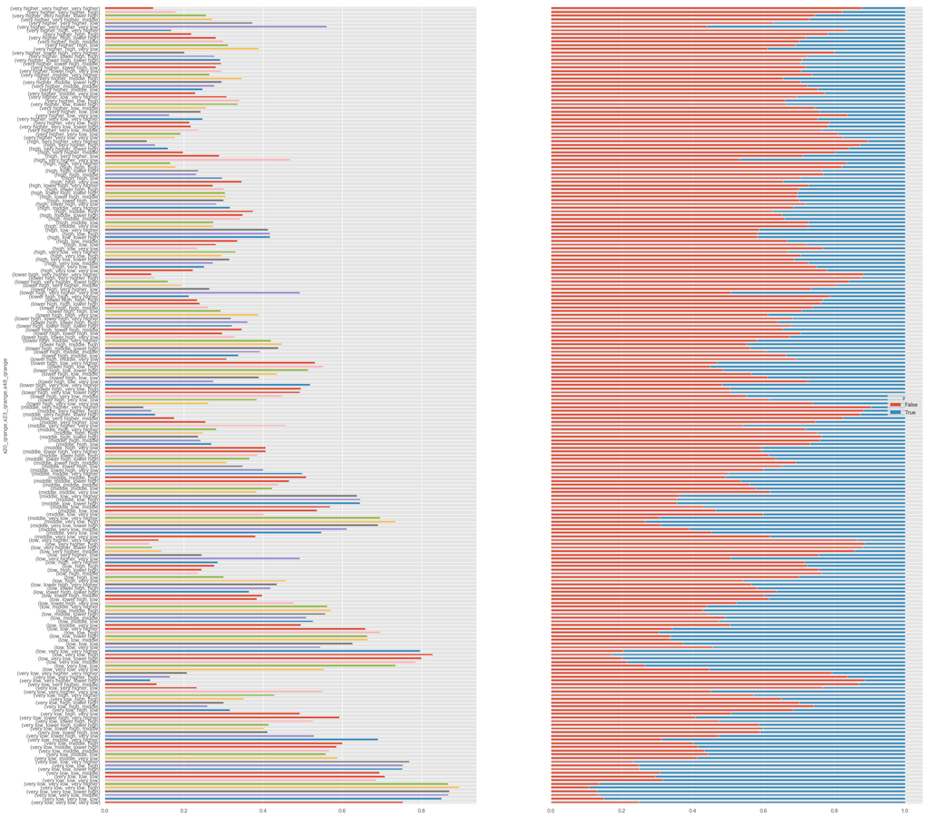

```python
#Let's group SEX and AGE and visualize the default status with bar plots. [2]
plt.rcParams['figure.figsize']=(30,30) #set the figure size
fig, ax = plt.subplots(1,2, sharey=True)

# we use quantile cut (qcut) here because we want to see how the default status varies for each bins with equals of data
# data_fillna['x20_qrange'] = pd.qcut(data_fillna.x20,6,labels=['very low', 'low', 'middle',
#                                                             'lower high','high','very higher']) # this creates a new variable
data_fillna['x48_qrange'] = pd.qcut(data_fillna.x48,6,labels=['very low', 'low', 'middle',
                                                            'lower high','high','very higher']) # this creates a new variable

plt.style.use('ggplot')
# now lets group
SA_grouped = data_fillna.groupby(['x20_qrange','x23_qrange', 'x48_qrange'])

default_rate_SA = SA_grouped.y.sum()/SA_grouped.y.count()
axis = default_rate_SA.plot(kind='barh', ax=ax[0])

#crosstab
default_nodefault_SA = pd.crosstab([data_fillna['x20_qrange'],data_fillna['x23_qrange'],data_fillna['x48_qrange']]
                                   ,data_fillna.y.astype(bool))
print ('-----------default count-----------')
print default_nodefault_SA

# normalized
default_nodefault_SA_norm = default_nodefault_SA.div(default_nodefault_SA.sum(1).astype(float),
                             axis=0) # normalize the value
print ('------normalized default ratio-----')
print default_nodefault_SA_norm

#normalized stacked plot
axis2 = default_nodefault_SA_norm.plot(kind='barh',
                   stacked=True, ax=ax[1])
```

The above plots also show there is evidence of linear relationship between 'x48','x23', 'x20' and 'y'.

## 4. PCA Analysis for continuous variables

We are going to use PCA, and LDA to find the 12 "best" dimensions of this data

```python
#Using scikit-learn for PCA and LDA analysis. [2], [7]
# these are linear transforms to help project the features into something more understandable
from sklearn.decomposition import PCA as sklearnPCA
from sklearn.discriminant_analysis import LinearDiscriminantAnalysis as LDA

# all except y, 'x24', 'x29', 'x30'
continuous_features = [u'x0', u'x1', u'x2', u'x3', u'x4', u'x5', u'x6', u'x7', u'x8', u'x9',
       u'x10', u'x11', u'x12', u'x13', u'x14', u'x15', u'x16', u'x17', u'x18',
       u'x19', u'x20', u'x21', u'x22', u'x23', u'x25', u'x26', u'x27',
       u'x28', u'x31', u'x32', u'x33', u'x34', u'x35', u'x36',
       u'x37', u'x38', u'x39', u'x40', u'x41', u'x42', u'x43', u'x44', u'x45',
       u'x46', u'x47', u'x48', u'x49']

X = data_fillna[continuous_features].values #all the continuous
y = data_fillna[['y']].values # iloc[row slicing, column slicing]

from sklearn.preprocessing import StandardScaler
X_std = StandardScaler().fit_transform(X)

sklearn_pca = sklearnPCA(n_components=12) # first 12 components only explain 25%
Y_sklearn = sklearn_pca.fit_transform(X_std,y)
print ('pca:', sklearn_pca.components_)

lda = LDA(n_components=11) # 5 components
X_lda = lda.fit_transform(X_std,y)
print ('lda:', lda.scalings_.T)
```

[output not shown]

[output cut: 137 more lines]

[output not shown]

```
('lda:', array([[-5.17392467e-04,  8.48511951e-03, -2.58577545e-01,
         6.05570305e-03,  2.08915364e-03, -2.49180098e-03,
        -4.33371517e-01, -5.23898083e-02, -1.18795460e-02,
         4.42271902e-03, -4.87107691e-03,  2.47899376e-03,
        -1.24338016e-01, -4.77325792e-03, -5.65226316e-03,
        -1.22324994e-03,  1.29244451e-02, -6.06009920e-03,
         1.02612999e-02,  8.81315330e-03, -1.70274168e-01,
         6.85007772e-03,  2.63734236e-03, -3.46286734e-01,
         1.02453774e-02, -2.88376551e-03, -4.66644546e-02,
         1.50722163e-01, -6.16495842e-04, -4.94909309e-02,
        -3.15423378e-03,  1.22324537e-02, -3.10029474e-03,
         1.31726892e-03,  3.10077983e-01, -1.88695328e-01,
         3.54872926e-04,  5.13568945e-01,  6.69904916e-01,
        -1.41157544e-01,  4.32658113e-03,  2.06563250e-03,
        -6.30727403e-03, -5.79706714e-02,  1.58058648e-03,
        -4.48075870e-01,  5.10946181e-01]]))
```

```python
print sklearn_pca.explained_variance_ratio_
sklearn_pca.explained_variance_ratio_.sum()
```

```
[0.08322083 0.06566239 0.04408207 0.04005729 0.03259003 0.02414883
 0.02171181 0.02157813 0.02152157 0.02145267 0.02140961 0.02137445]
```

```
0.4188096779388878
```

The best 12 components only explain 42% of the dataset's original information.

```python
comps = pd.DataFrame(sklearn_pca.components_)
comps
```

|  | 0 | 1 | 2 | 3 | 4 | 5 | 6 | 7 | 8 | 9 | ... | 37 | 38 | 39 | 40 | 41 | 42 | 43 | 44 | 45 | 46 |
| --- | --- | --- | --- | --- | --- | --- | --- | --- | --- | --- | --- | --- | --- | --- | --- | --- | --- | --- | --- | --- | --- |
| 0 | 0.001410 | -0.001667 | 0.461326 | 0.000076 | 0.001037 | 0.002393 | 0.461333 | -0.004158 | -0.001158 | 0.002350 | ... | 0.074722 | 0.324342 | 0.169006 | -0.000772 | 0.002282 | -0.000791 | 0.100847 | -0.001230 | -0.108301 | -0.031137 |
| 1 | 0.002510 | -0.003397 | 0.143464 | -0.002620 | 0.002335 | -0.000504 | 0.143505 | 0.502523 | -0.005380 | -0.002223 | ... | 0.411360 | -0.254383 | 0.009838 | -0.000391 | -0.002959 | -0.000715 | -0.301295 | -0.003328 | -0.042658 | -0.192002 |
| 2 | -0.000845 | 0.003871 | 0.022909 | 0.003689 | 0.003197 | 0.002340 | 0.022879 | 0.238659 | 0.003205 | 0.005922 | ... | -0.092621 | -0.350286 | 0.434663 | 0.002170 | -0.003211 | -0.003136 | 0.517736 | -0.006900 | -0.123289 | 0.264836 |
| 3 | 0.001828 | 0.012263 | -0.215780 | -0.007151 | -0.000394 | 0.004843 | -0.215763 | 0.050201 | -0.006158 | 0.013181 | ... | 0.271275 | 0.088408 | -0.187186 | 0.006277 | 0.002340 | 0.000696 | 0.156161 | -0.011057 | 0.434914 | 0.338588 |
| 4 | -0.005395 | 0.044946 | -0.003489 | 0.023828 | 0.026201 | 0.031236 | -0.003475 | 0.223634 | 0.002316 | 0.023825 | ... | -0.383111 | 0.146575 | 0.099524 | 0.023128 | -0.028039 | -0.002333 | -0.177053 | 0.012076 | 0.113687 | 0.367296 |
| 5 | 0.186132 | -0.125145 | -0.064115 | -0.091855 | -0.065199 | -0.086825 | -0.064039 | -0.034520 | -0.098436 | 0.003718 | ... | 0.144131 | 0.033473 | -0.120298 | 0.034963 | 0.054143 | -0.007769 | 0.061566 | -0.091496 | -0.082940 | 0.367461 |
| 6 | 0.055340 | 0.240987 | -0.019515 | -0.248355 | -0.055045 | 0.039799 | -0.019438 | 0.069143 | 0.085723 | -0.131868 | ... | 0.062019 | 0.135014 | 0.274247 | 0.164962 | 0.055894 | 0.104424 | 0.001307 | 0.180452 | 0.157455 | -0.015485 |
| 7 | -0.354874 | 0.162970 | 0.001098 | -0.196881 | -0.094007 | -0.038157 | 0.001096 | 0.008007 | 0.245435 | 0.035307 | ... | 0.005417 | 0.009724 | 0.032587 | -0.056490 | -0.083604 | -0.038493 | -0.002815 | -0.231862 | 0.039848 | -0.007121 |
| 8 | -0.105702 | -0.080604 | 0.001289 | -0.288203 | 0.241710 | -0.009439 | 0.001324 | -0.005997 | -0.298619 | 0.005628 | ... | 0.001928 | -0.009922 | -0.015541 | 0.320031 | -0.043124 | 0.236679 | 0.000903 | -0.054678 | 0.011516 | -0.000137 |
| 9 | 0.238866 | 0.100414 | 0.002617 | -0.150720 | -0.140309 | 0.305140 | 0.002607 | 0.002460 | 0.019083 | 0.036187 | ... | -0.006564 | 0.003432 | 0.010574 | 0.043741 | 0.204379 | -0.084185 | -0.002678 | -0.179520 | 0.001867 | -0.014087 |
| 10 | -0.145757 | 0.039643 | 0.015751 | -0.000118 | 0.101636 | 0.306254 | 0.015801 | -0.029794 | 0.040033 | 0.090376 | ... | -0.028049 | -0.074013 | -0.130150 | -0.004010 | 0.226259 | -0.172017 | -0.001348 | 0.264426 | -0.037808 | -0.016385 |
| 11 | -0.100139 | 0.038002 | 0.000916 | 0.233418 | -0.298155 | -0.141234 | 0.000929 | -0.005756 | 0.230167 | -0.271264 | ... | 0.001047 | -0.011543 | -0.027432 | 0.112707 | 0.004610 | 0.011353 | 0.006356 | -0.027079 | -0.010119 | 0.005408 |

12 rows × 47 columns

From the cumulative variance that equals to 0.4188 we can conclude that we can retain only 42% of the dataset's original information, with 58% of the complexity. Also, from the explained variance ratio we can see that only 8% of the information are compressed in the first component, 6% of the information are compressed in the 2nd components. There is no one variable or one group of variable that hold majority of information in this data set.

This PCA analysis also confirms a majority of our continous variables are random, and are not highly linear correlated.

## 5. One-Hot Coding Column 'x24' , 'x29', and 'x30'

Perform one-hot coding on categorical and ordinal variables using pandas get_dummies() function.

```python
# perform one-hot coding using pandas get_dummies() function.
# get_dummies() automatically deletes 'x24' , 'x29', and 'x30'
cols_to_transform = [ 'x24', 'x29', 'x30' ]
data_w_dummies = pd.get_dummies(data_fillna, columns = cols_to_transform, dummy_na=False) # not encode na

# look at data_with_dummies
data_w_dummies.head()
```

|  | x0 | x1 | x2 | x3 | x4 | x5 | x6 | x7 | x8 | x9 | ... | x29_Mar | x29_May | x29_Nov | x29_Oct | x29_sept. | x30_friday | x30_monday | x30_thurday | x30_tuesday | x30_wednesday |
| --- | --- | --- | --- | --- | --- | --- | --- | --- | --- | --- | --- | --- | --- | --- | --- | --- | --- | --- | --- | --- | --- |
| 26546 | 0.433876 | 2.910562 | 22.310555 | 6.540488 | 2.903073 | -6.726396 | 32.437870 | 43.500313 | -10.792003 | -8.732554 | ... | 0 | 0 | 0 | 0 | 0 | 0 | 1 | 0 | 0 | 0 |
| 26835 | -1.112501 | -3.450738 | 10.781852 | 6.184937 | 5.118608 | 0.839718 | 15.676002 | 57.169147 | 2.573204 | 8.433345 | ... | 0 | 0 | 0 | 0 | 0 | 0 | 0 | 1 | 0 | 0 |
| 138482 | -0.741442 | 3.444253 | -16.737438 | -7.921415 | 1.373968 | 13.904434 | -24.334978 | 13.307492 | 7.669094 | 3.515297 | ... | 0 | 0 | 0 | 0 | 0 | 0 | 0 | 1 | 0 | 0 |
| 88785 | -0.475384 | 12.301063 | 9.453689 | -14.259572 | 0.693288 | 1.053640 | 13.744953 | -52.310844 | 3.137198 | 0.917666 | ... | 0 | 0 | 0 | 0 | 0 | 0 | 0 | 1 | 0 | 0 |
| 134387 | -0.456786 | 1.687705 | 0.134832 | -0.499670 | -0.639894 | 3.889339 | 0.196036 | -1.911663 | 3.620222 | 8.274778 | ... | 0 | 0 | 0 | 0 | 0 | 0 | 0 | 1 | 0 | 0 |

5 rows × 68 columns

```python
#check data frequency and possible invalid data of response variable 'y'
# NOTE: calling describe when not all the data is categorical will cause the
# categorical variables to be removed
data_w_dummies[['y']].describe().transpose()
```

|  | count | mean | std | min | 25% | 50% | 75% | max |
| --- | --- | --- | --- | --- | --- | --- | --- | --- |
| y | 160000.0 | 0.401231 | 0.490149 | 0.0 | 0.0 | 0.0 | 1.0 | 1.0 |

```python
# # Heat Map of all correlation of all the attributes:
# plt.figure(figsize=(25,25))
# # trying to mask the upper part
# mask = np.zeros_like(data_w_dummies.corr(), dtype=np.bool)
# mask[np.triu_indices_from(mask)] = True

# # Draw the heatmap with the mask and correct aspect ratio
# sns.heatmap(data_w_dummies.corr(), mask=mask,annot =True)
# plt.show()
```

```python
#print out the clean dataset and save the file
data_w_dummies.to_csv('./final_project_w_dummies.csv')
```

```python
#read the data set
data_wdummies = pd.read_csv('./final_project_w_dummies.csv')
# data_wdummies.drop(data_wdummies.columns[[0]], inplace=True)
data_wdummies.drop(data_wdummies.columns[[0]], axis=1, inplace=True)

data_wdummies.head()
```

|  | x0 | x1 | x2 | x3 | x4 | x5 | x6 | x7 | x8 | x9 | ... | x29_Mar | x29_May | x29_Nov | x29_Oct | x29_sept. | x30_friday | x30_monday | x30_thurday | x30_tuesday | x30_wednesday |
| --- | --- | --- | --- | --- | --- | --- | --- | --- | --- | --- | --- | --- | --- | --- | --- | --- | --- | --- | --- | --- | --- |
| 0 | 0.433876 | 2.910562 | 22.310555 | 6.540488 | 2.903073 | -6.726396 | 32.437870 | 43.500313 | -10.792003 | -8.732554 | ... | 0 | 0 | 0 | 0 | 0 | 0 | 1 | 0 | 0 | 0 |
| 1 | -1.112501 | -3.450738 | 10.781852 | 6.184937 | 5.118608 | 0.839718 | 15.676002 | 57.169147 | 2.573205 | 8.433345 | ... | 0 | 0 | 0 | 0 | 0 | 0 | 0 | 1 | 0 | 0 |
| 2 | -0.741442 | 3.444253 | -16.737438 | -7.921415 | 1.373968 | 13.904434 | -24.334978 | 13.307492 | 7.669094 | 3.515297 | ... | 0 | 0 | 0 | 0 | 0 | 0 | 0 | 1 | 0 | 0 |
| 3 | -0.475384 | 12.301063 | 9.453689 | -14.259572 | 0.693288 | 1.053640 | 13.744953 | -52.310844 | 3.137198 | 0.917666 | ... | 0 | 0 | 0 | 0 | 0 | 0 | 0 | 1 | 0 | 0 |
| 4 | -0.456786 | 1.687705 | 0.134832 | -0.499670 | -0.639894 | 3.889339 | 0.196036 | -1.911663 | 3.620222 | 8.274778 | ... | 0 | 0 | 0 | 0 | 0 | 0 | 0 | 1 | 0 | 0 |

5 rows × 68 columns

**Check response variable 'y' imbalance**

```python
#check the ratio of default / not default
float(len(data_wdummies[data_wdummies['y']==1]))/len(data_wdummies)*100.0 # yes = 1, no = 0
```

```
40.123125
```

```
Text(0.5,1,'Frequency of 1 vs. 0')
```

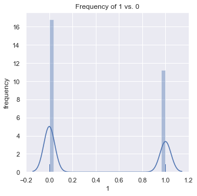

```python
#histogram plot for frequency
sns.set()
plt.figure(figsize=(5,5))
sns.distplot(data_wdummies.y, hist=True, kde=True,rug=True) # rug=True
plt.xlabel('1')
plt.ylabel('frequency')
plt.title("Frequency of 1 vs. 0")
# data.hist(column="x32", by="y", bins=50, ax=ax[0,1])
```

Our categorical variable is slightly imbalanced with 40% of Positive (1) value and 60% of Negative (0) value.

**Check the distribution of explanatory variable with 'y' value**

Distribution of 'x0' vs. 'y' values

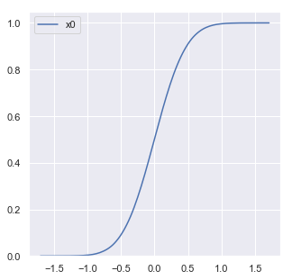

```python
# Cumulative distibution function plot of x0
sns.set()
plt.figure(figsize=(5,5))
sns.kdeplot(data_wdummies.x0,cumulative=True)
# Cumulative distibution function plot above shows that more than 90% of the x0 group is under xxx.
```

```
count    160000.000000
mean         -0.001028
std           0.371107
min          -1.592635
25%          -0.251574
50%          -0.001980
75%           0.248505
max           1.600849
Name: x0, dtype: float64
```

```
array([<matplotlib.axes._subplots.AxesSubplot object at 0x1c27d55850>,
      dtype=object)
```

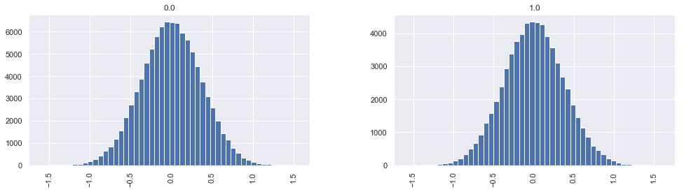

```python
# histogram
sns.set()
plt.figure(figsize=(5,5))
print data_wdummies['x0'].describe()
data_wdummies.hist(column="x0",by="y",bins=50)
```

The above histograms confirm our observation in the above that the our data is random and that distribution of the explanatory variable in each of the response 'y' classification is very similar. Both have normal distribution.

## 6. Feature Important

We will use Random Forest (RF) to fit our data. We do not normalize the data since RF does not require or needs to normalize the data set.

```python
data_wdummies.head()
# Rearrange the columns
df_new = data_wdummies[['y', u'x0', u'x1', u'x2', u'x3', u'x4', u'x5', u'x6', u'x7', u'x8', u'x9',
       u'x10', u'x11', u'x12', u'x13', u'x14', u'x15', u'x16', u'x17', u'x18',
       u'x19', u'x20', u'x21', u'x22', u'x23', u'x25', u'x26', u'x27', u'x28',
       u'x31', u'x32', u'x33', u'x34', u'x35', u'x36', u'x37', u'x38', u'x39',
       u'x40', u'x41', u'x42', u'x43', u'x44', u'x45', u'x46', u'x47', u'x48',
       u'x49', u'x24_america', u'x24_asia', u'x24_euorpe', u'x29_Apr',
       u'x29_Aug', u'x29_Dev', u'x29_Feb', u'x29_January', u'x29_July',
       u'x29_Jun', u'x29_Mar', u'x29_May', u'x29_Nov', u'x29_Oct',
       u'x29_sept.', u'x30_friday', u'x30_monday', u'x30_thurday',
       u'x30_tuesday', u'x30_wednesday']]
df_new.head()
```

|  | y | x0 | x1 | x2 | x3 | x4 | x5 | x6 | x7 | x8 | ... | x29_Mar | x29_May | x29_Nov | x29_Oct | x29_sept. | x30_friday | x30_monday | x30_thurday | x30_tuesday | x30_wednesday |
| --- | --- | --- | --- | --- | --- | --- | --- | --- | --- | --- | --- | --- | --- | --- | --- | --- | --- | --- | --- | --- | --- |
| 0 | 0.0 | 0.433876 | 2.910562 | 22.310555 | 6.540488 | 2.903073 | -6.726396 | 32.437870 | 43.500313 | -10.792003 | ... | 0 | 0 | 0 | 0 | 0 | 0 | 1 | 0 | 0 | 0 |
| 1 | 0.0 | -1.112501 | -3.450738 | 10.781852 | 6.184937 | 5.118608 | 0.839718 | 15.676002 | 57.169147 | 2.573205 | ... | 0 | 0 | 0 | 0 | 0 | 0 | 0 | 1 | 0 | 0 |
| 2 | 0.0 | -0.741442 | 3.444253 | -16.737438 | -7.921415 | 1.373968 | 13.904434 | -24.334978 | 13.307492 | 7.669094 | ... | 0 | 0 | 0 | 0 | 0 | 0 | 0 | 1 | 0 | 0 |
| 3 | 0.0 | -0.475384 | 12.301063 | 9.453689 | -14.259572 | 0.693288 | 1.053640 | 13.744953 | -52.310844 | 3.137198 | ... | 0 | 0 | 0 | 0 | 0 | 0 | 0 | 1 | 0 | 0 |
| 4 | 0.0 | -0.456786 | 1.687705 | 0.134832 | -0.499670 | -0.639894 | 3.889339 | 0.196036 | -1.911663 | 3.620222 | ... | 0 | 0 | 0 | 0 | 0 | 0 | 0 | 1 | 0 | 0 |

5 rows × 68 columns

```
[7.57702827e-03 7.47854398e-03 2.95442048e-02 7.63975431e-03
 7.43706330e-03 7.47682739e-03 2.91279953e-02 3.96379453e-02
 7.55782920e-03 7.57803587e-03 7.48686318e-03 7.48858882e-03
 4.82519439e-02 7.59524349e-03 7.56642212e-03 7.62283208e-03
 7.44052564e-03 7.39032086e-03 7.52107137e-03 7.55013828e-03
 6.32311619e-02 7.47663944e-03 7.51644185e-03 7.24103764e-02
 7.43357282e-03 7.53011714e-03 4.51176119e-02 4.73962287e-02
 7.49768143e-03 2.61338688e-02 7.64761860e-03 7.46341333e-03
 7.55242795e-03 7.54452991e-03 4.35664861e-02 3.51945013e-02
 7.61146044e-03 4.40766473e-02 3.36262213e-02 4.98572396e-02
 7.50067893e-03 7.54800313e-03 7.47638287e-03 3.46028152e-02
 7.41201597e-03 5.95034079e-02 5.67558402e-02 1.35790737e-03
 3.87900532e-03 3.36452676e-03 4.69705395e-04 8.17362947e-04
 6.49811489e-06 3.85071826e-05 1.17932136e-05 8.80264170e-04
 8.74232207e-04 1.94941294e-04 7.67547837e-04 8.21258196e-05
 3.12100624e-04 5.69215729e-04 1.24017738e-04 1.12847877e-04
 8.08247376e-04 7.76610552e-04 8.99974673e-04]
CPU times: user 3min 41s, sys: 2.8 s, total: 3min 44s
Wall time: 3min 47s
```

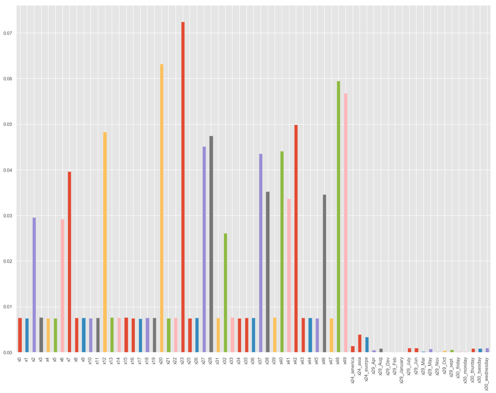

```python
%%time
from sklearn.model_selection import StratifiedKFold, cross_val_score
from sklearn.ensemble import RandomForestClassifier
from sklearn.preprocessing import StandardScaler
from sklearn import metrics as mt

from sklearn.metrics import classification_report, roc_auc_score, accuracy_score, roc_curve, auc
from sklearn import svm, datasets
from sklearn.preprocessing import label_binarize
from sklearn.multiclass import OneVsRestClassifier

from sklearn.model_selection import cross_val_score

columns = df_new[df_new.columns[~df_new.columns.isin(['y'])]].columns

y_WT = np.array(df_new.iloc[:160000,0])
x_WT = np.array(df_new.iloc[:160000,1:]) # this is faster than columns = df_new[df_new.columns[~df_new.columns.isin(['y'])]].columns

forest = RandomForestClassifier(n_estimators=150,random_state=1)
forest.fit(x_WT, y_WT)
# importances = forest.feature_importances_

print(forest.feature_importances_) # call .cross_val_score() to get this .feature_importances_()
weights = pd.Series(forest.feature_importances_, index=columns) #
plt.figure(figsize=(20,15))
weights.plot(kind='bar')
```

The plot shows columns x20, x23, x48 and x49 have the heaviest weight. Column x23 variable has the biggest weight. Those categorial and ordinal variables, have the lowest weight, close to 0.

The score tells us how much each feature influences the response variable. The higher the value in absolute value, the higher the influence on the response variable.

However, columns 'x2' and 'x6' are highly correlated. Columns x41 and x38 are also highly correlated. Columns x37 is also correlated to columns x2 and x6. In this case, the high weights of these variables does not really mean that these features have the biggest influence on the response variable. Moreover, these highest weight are not dominant. This is also observed in PCA analysis, where the top 12 heaviest weight variables only explain 42% or the original information.

We do not drop any variable since there are no obvious significant high weight features or obvious insignificant low weigh features.

# V. Modelling

Back to top

## 1. Training and Splitting

We chose StratifiedKFold to address the imbalanced binary response classes. Almost 60% of the data is a false response (0) for 'y' classification. In StratifiedKFold, data don't overlap in folds and it will always be different in each fold. This reduce bias in our test result, with more false (0) in 'y' classification.

However, StratifiedKFold can be a problem if the data set if small, preventing the effectiveness of randomization. We will be using a Stratified 3-Fold Cross Validation for our analysis, where we create 3 subsamples to produce a more significant number of samples. We then separate one of the subsamples for testing and the remaining subsamples for training, do this for every possible combination of testing/training folds and average the results. This is called cross-validation. 3-fold cross-validation splits our data 3 times, and then averaging. A small sample might not benefit from 10-fold cross-validation, but with 160,000 data, our data set is relatively large and does benefit from this cross-validation. The large size of our data provides a better scenario to ensure bias is minimized. 3-fold cross-validation is also suffficient for our large data set.

With this unbalanced design, if we use normal randomized groups, we will likely end up building models with fewer data points from the positive class. When we are building a model that is trained on data that have very few positives, the model won't be able to effectively predict the rare group. The stratified cross-validation allows for randomization while making sure that the split unbalanced datasets have equally represented classes. Stratification rearranges the data to ensure each fold is a good representation of a whole. Even though, a random split is a quicker way of estimating, but might be more prone to sampling bias than k-fold cross-validation. The bottom line is, Stratification minimizes sample selection bias and ensures certain segments of the population are not overrepresented or underrepresented. Stratified 3-Fold Cross Validation not only provides us with a thorough method of splitting, training, and testing our models against our data set but also ensures our model maintains a similar level of accuracy as it is being developed.

To test model prediction accuracy, the binary response of the dataset is used stratified k-fold for cross validation. This will also address the imbalanced binary response.

Back to top

```python
#read the data set
data_wdummies = pd.read_csv('./final_project_w_dummies.csv')
# data_wdummies.drop(data_wdummies.columns[[0]], inplace=True)
data_wdummies.drop(data_wdummies.columns[[0]], axis=1, inplace=True)

# Rearrange the columns
df_new = data_wdummies[['y', u'x0', u'x1', u'x2', u'x3', u'x4', u'x5', u'x6', u'x7', u'x8', u'x9',
       u'x10', u'x11', u'x12', u'x13', u'x14', u'x15', u'x16', u'x17', u'x18',
       u'x19', u'x20', u'x21', u'x22', u'x23', u'x25', u'x26', u'x27', u'x28',
       u'x31', u'x32', u'x33', u'x34', u'x35', u'x36', u'x37', u'x38', u'x39',
       u'x40', u'x41', u'x42', u'x43', u'x44', u'x45', u'x46', u'x47', u'x48',
       u'x49', u'x24_america', u'x24_asia', u'x24_euorpe', u'x29_Apr',
       u'x29_Aug', u'x29_Dev', u'x29_Feb', u'x29_January', u'x29_July',
       u'x29_Jun', u'x29_Mar', u'x29_May', u'x29_Nov', u'x29_Oct',
       u'x29_sept.', u'x30_friday', u'x30_monday', u'x30_thurday',
       u'x30_tuesday', u'x30_wednesday']]
df_new.head()
```

|  | y | x0 | x1 | x2 | x3 | x4 | x5 | x6 | x7 | x8 | ... | x29_Mar | x29_May | x29_Nov | x29_Oct | x29_sept. | x30_friday | x30_monday | x30_thurday | x30_tuesday | x30_wednesday |
| --- | --- | --- | --- | --- | --- | --- | --- | --- | --- | --- | --- | --- | --- | --- | --- | --- | --- | --- | --- | --- | --- |
| 0 | 0.0 | 0.433876 | 2.910562 | 22.310555 | 6.540488 | 2.903073 | -6.726396 | 32.437870 | 43.500313 | -10.792003 | ... | 0 | 0 | 0 | 0 | 0 | 0 | 1 | 0 | 0 | 0 |
| 1 | 0.0 | -1.112501 | -3.450738 | 10.781852 | 6.184937 | 5.118608 | 0.839718 | 15.676002 | 57.169147 | 2.573205 | ... | 0 | 0 | 0 | 0 | 0 | 0 | 0 | 1 | 0 | 0 |
| 2 | 0.0 | -0.741442 | 3.444253 | -16.737438 | -7.921415 | 1.373968 | 13.904434 | -24.334978 | 13.307492 | 7.669094 | ... | 0 | 0 | 0 | 0 | 0 | 0 | 0 | 1 | 0 | 0 |
| 3 | 0.0 | -0.475384 | 12.301063 | 9.453689 | -14.259572 | 0.693288 | 1.053640 | 13.744953 | -52.310844 | 3.137198 | ... | 0 | 0 | 0 | 0 | 0 | 0 | 0 | 1 | 0 | 0 |
| 4 | 0.0 | -0.456786 | 1.687705 | 0.134832 | -0.499670 | -0.639894 | 3.889339 | 0.196036 | -1.911663 | 3.620222 | ... | 0 | 0 | 0 | 0 | 0 | 0 | 0 | 1 | 0 | 0 |

5 rows × 68 columns

```python
%%time
# make a copy of the data
df_copy1 = df_new.copy()

# Let's start with a simple classifier and ten fold cross validation, calculating accuracy to start.
start = time.time()

from sklearn.neighbors import KNeighborsClassifier
from sklearn.model_selection import StratifiedKFold
from sklearn.preprocessing import StandardScaler
from sklearn import metrics as mt

# create variables we are more familiar with
y1 = df_copy1['y'].values # get the predictor values
del df_copy1['y'] # get rid of the class label
X1 = df_copy1.values # use everything else to predict! - after deleting 'y' in the df

y1_hat = np.zeros(y1.shape) # we will fill this with predictions

scl = StandardScaler()
X1 = scl.fit_transform(X1)

# create cross validation iterator by by performing 10 fold cross validation
cv = StratifiedKFold(n_splits=3, random_state=7) # starting out with random_state=7 so that we will always get the same output the first time we make the split. We want reproducible results.

print(cv)
print cv.get_n_splits(X1,y1)

print 'It took', time.time()-start, 'seconds.'
```

```
StratifiedKFold(n_splits=3, random_state=7, shuffle=False)
3
It took 0.624388933182 seconds.
CPU times: user 758 ms, sys: 376 ms, total: 1.13 s
Wall time: 678 ms
```

## 2. Grid Search CV for Random Forest

Back to top

```python
# get up a function for Grid Search CV. [14] - [17]

from sklearn.datasets import make_classification
from sklearn.ensemble import RandomForestClassifier
from sklearn.linear_model import LogisticRegression
from sklearn.model_selection import GridSearchCV
from sklearn.ensemble import GradientBoostingClassifier
# from xgboost import XGBClassifier # does not work. Kernel keeps crashing down

def grid_searcher(X, y, model, params, cv_object, score_metric): # score_metric = 'roc_auc'
    clf = GridSearchCV(model, params, cv=cv_object,n_jobs=-1, scoring=score_metric)
    clf.fit(X, y)
    return clf
```

**Grid Seach CV for Random Forest**

In our case, because the dataset is relatively large, we can try with higher n_estimators of 10, 50, 150, 200 and max_depth of 10, 30, 50, 100

```
n_estimators = number of trees in the foreset
max_features = max number of features considered for splitting a node
max_depth = max number of levels in each decision tree
min_samples_split = min number of data points placed in a node before the node is split
min_samples_leaf = min number of data points allowed in a leaf node
bootstrap = method for sampling data points (with or without replacement)
```

```python
%%time
# Let's start with RF and 3 fold cross validation, calculating roc to start.
start = time.time()

# RF: set parameters for grid search to test all the different combinations
model = RandomForestClassifier() # oob_score: (default=False) whether to use out-of-bag samples to estimate the generalization accuracy.
params = {
    'n_estimators': [10,50,150,200],
    #'max_features': ['auto', 'sqrt', 'log2'],
    'max_depth': [10, 30, 50, 100]
}

# call the function: score_metric = 'roc_auc'
rfc_clf = grid_searcher(X1, y1, model, params,cv.get_n_splits(X1,y1),'roc_auc') # n_splits=3, can use: cv.get_n_splits(X1,y1)

print(rfc_clf.grid_scores_ )
print("The best estimator: ",rfc_clf.best_estimator_)
print("The best roc score is: ", rfc_clf.best_score_)
print("The best parameters of model is: ",rfc_clf.best_params_)

print 'It took', time.time()-start, 'seconds.'
```

```
[mean: 0.92543, std: 0.00463, params: {'n_estimators': 10, 'max_depth': 10}, mean: 0.93717, std: 0.00301, params: {'n_estimators': 50, 'max_depth': 10}, mean: 0.93761, std: 0.00271, params: {'n_estimators': 150, 'max_depth': 10}, mean: 0.93765, std: 0.00354, params: {'n_estimators': 200, 'max_depth'…
('The best estimator: ', RandomForestClassifier(bootstrap=True, class_weight=None, criterion='gini',
            max_depth=30, max_features='auto', max_leaf_nodes=None,
            min_impurity_decrease=0.0, min_impurity_split=None,
            min_samples_leaf=1, min_samples_split=2,
            min_weight_fraction_leaf=0.0, n_estimators=200, n_jobs=1,
            oob_score=False, random_state=None, verbose=0,
            warm_start=False))
('The best roc score is: ', 0.9711277897385077)
('The best parameters of model is: ', {'n_estimators': 200, 'max_depth': 30})
It took 2094.30704808 seconds.
CPU times: user 4min 27s, sys: 2.43 s, total: 4min 30s
Wall time: 34min 54s
```

**Grid search reveals:**

```
Best n_estimators is 200. This makes sense because the higher value of n_estimators returns better model overall performance. However, at certain point, the time efficiency may be too excessive for a very large value of n_estimators. Since our data set is large, our regular computer cannot handle the task for higher n_estimators.
Best max_depth is 30. This is also reasonable since our data is bias. The best roc score is 97.11%.
Others parameters are recommended as default.
```

## 3. Grid Seach CV for Logistic Regression

For logistic regression, the following parameters will be optimized during the analysis:

- Penalty {l1, l2}
- Cost {.001,.1,1,10,100,1000}: a small cost implies stronger regulation
- class_weight {(None, 'balanced')}

Others additional parameters are available for further configuration. For our dataset, these will be set as default.

Back to top

```python
%%time
# Let's start with RF and 3 fold cross validation, calculating roc to start.
start = time.time()

# LR: set parameters for grid search to test all the different combinations
c_values = [.001,.1,1,10,100,1000]#np.arange(.01, .1, 0.01) # cost
model = LogisticRegression()
params = {'penalty':('l1','l2'), 'C':c_values, 'class_weight':(None, 'balanced')}

#run search and return results
# X1, y1, model, params,cv.get_n_splits(X1,y1),'roc_auc'
logit_clf = grid_searcher(X1, y1, model, params, cv.get_n_splits(X1,y1),'roc_auc') # n_splits=3, can use: cv.get_n_splits(X1,y1)

print(logit_clf.grid_scores_)
print("The best estimator: ",logit_clf.best_estimator_)
print("The best roc score is: ", logit_clf.best_score_)
print("The best parameters of model is: ",logit_clf.best_params_)

print 'It took', time.time()-start, 'seconds.'
```

[output not shown]

**Grid search reveals:**

```
Penalty - l1 was selected over l2, which means that the objective function that is minimized is better for L1, which is the sum of errors, rather than L2, which is the sum of squared errors. L1 is less sensitive to outliers. L1 makes sense since there is no obvious outliner in our data set.

C=0.1 value indicates a smaller value is needed to improve the models ability to not fit to noise. This is understandable as the data is normalized data.

Class_weight selection of 'balanced' over None, means balanced adds accuracy to the fit, likely because 'balanced' model uses the values of y to automatically adjust weights inversely proportional to class frequencies in the input data"

The best roc score is 74.28%. Others parameters are recommended as default.
```

## 4. Grid Seach CV for Gradient Boosting

Sklearn's GradientBoost is a gradient boosting implementation.

The various steps to be performed are [8]:

```
- Choose a relatively high learning rate. Generally a learning rate of 0.1 works but somewhere between 0.05 to 0.3 should work for different problems.
    learning_rate': 0.1
- Determine the optimum number of trees for this learning rate. GradientBoost has a very useful function called as “cv” which performs cross-validation at each boosting iteration and thus returns the optimum number of trees required.
    cv = 3
- Tune tree-specific parameters for decided learning rate and number of trees.

    - max_depth: [3, 5, 7]

    - n_estimators: [150, 500, 1000]

    - max_features: 0.3

    - min_samples_leaf: 1
```

Back to top

```python
%%time
from sklearn.ensemble import GradientBoostingClassifier

start = time.time()

#     learning_rate: # Choose a relatively high learning rate. Generally a learning rate of 0.1 works but somewhere between 0.05 to 0.3 should work for different problems.
#     max_depth: This should be between 3-10. I’ve started with 5 but you can choose a different number as well. 4-6 can be good starting points.
#     min_child_weight: A smaller value is chosen because it is a highly imbalanced class problem and leaf nodes can have smaller size groups.

params = {'max_depth': [3, 5, 7], 'n_estimators': [150, 500, 1000],  #
         'min_samples_leaf' : [1],'learning_rate': [0.1], 'max_features': [0.3]}

# params = {'max_depth': [3,5,7], 'min_child_weight': [1,3,5], 'n_estimators': [200, 500],
#          'learning_rate': [0.1], 'max_features': [0.3], 'min_samples_leaf' : [5]}

model = GradientBoostingClassifier()

#run search and return results
# X1, y1, model, params,cv.get_n_splits(X1,y1),'roc_auc'
xgb_clf = grid_searcher(X1, y1, model, params, cv.get_n_splits(X1,y1),'roc_auc') # n_splits=3, can use: cv.get_n_splits(X1,y1)

print(xgb_clf.grid_scores_)
print("The best estimator: ",xgb_clf .best_estimator_)
print("The best roc score is: ", xgb_clf .best_score_)
print("The best parameters of model is: ",xgb_clf .best_params_)

print 'It took', time.time()-start, 'seconds.'
```

```
[mean: 0.91651, std: 0.00424, params: {'max_features': 0.3, 'n_estimators': 150, 'learning_rate': 0.1, 'max_depth': 3, 'min_samples_leaf': 1}, mean: 0.94776, std: 0.00286, params: {'max_features': 0.3, 'n_estimators': 500, 'learning_rate': 0.1, 'max_depth': 3, 'min_samples_leaf': 1}, mean: 0.95815, …
('The best estimator: ', GradientBoostingClassifier(criterion='friedman_mse', init=None,
              learning_rate=0.1, loss='deviance', max_depth=7,
              max_features=0.3, max_leaf_nodes=None,
              min_impurity_decrease=0.0, min_impurity_split=None,
              min_samples_leaf=1, min_samples_split=2,
              min_weight_fraction_leaf=0.0, n_estimators=1000,
              presort='auto', random_state=None, subsample=1.0, verbose=0,
              warm_start=False))
('The best roc score is: ', 0.979738827529023)
('The best parameters of model is: ', {'max_features': 0.3, 'n_estimators': 1000, 'learning_rate': 0.1, 'max_depth': 7, 'min_samples_leaf': 1})
It took 7945.17397904 seconds.
CPU times: user 23min 51s, sys: 5.56 s, total: 23min 57s
Wall time: 2h 12min 25s
```

**Grid search reveals:**

```
Best n_estimators is 1000. This makes sense because the higher value of n_estimators returns better model metric result. However, at certain point, the time efficiency may be too excessive for a very large value of n_estimators, with our data set, our regular computer may not be able to handle the task.
Best max_depth is 7. This is also reasonable since our data is bias and is large.
The best roc score is 97.97%. This is a better roc score than RF and LR's best roc scores.
min_samples_leaf' equals 1 works for our  imbalanced data set
```

## 5. Keras Deep Learning

The model of choice is Sequential(). We will vary different layer stacking configurations, activation functions, epochs and batch size , kernel initializers, and optimizers to find the best combination. To validate the models, we use the test data and the predict() function. We then compare the results based on our model with the actual results in the test data.

Implement Steps:

[output not shown]

Back to top

```python
for train_indices, test_indices in cv.split(X1,y1):
        # I will create new variables here so that it is more obvious what
        # the code is doing (you can compact this syntax and avoid duplicating memory,
        # but it makes this code less readable)
        X_train = X1[train_indices]
        y_train = y1[train_indices]

        X_test = X1[test_indices]
        y_test = y1[test_indices]
```

```python
# %%time
start_time = time.time()

# Libraries
# conda install -c conda-forge keras
# conda install -c anaconda keras
from keras.models import Sequential
from keras.layers.core import Dense, Dropout, Activation
from keras.optimizers import SGD
from sklearn.metrics import roc_auc_score
from keras import optimizers
#

# 2. Define Model
#Begin
# layer 1 - input layer
model = Sequential()
model.add(Dense(50, input_dim=X_train.shape[1], kernel_initializer='uniform')) # X_train.shape[1] == 28 here # 4: change kernel_initializer=
model.add(Activation('sigmoid')) # change sigmoid to "tanh" or "ReLu" or whatever you can find (googling)

# layer 2 - a hidden layer
model.add(Dropout(0.10))
model.add(Dense(50, kernel_initializer='uniform'))
model.add(Activation('sigmoid')) # change sigmoid to "tanh" or "ReLu" or whatever you can find (googling)
model.add(Dropout(0.10))

# output layer
model.add(Dense(1, kernel_initializer='uniform'))
model.add(Activation('sigmoid')) # change sigmoid to "tanh" or "ReLu" or whatever you can find (googling)

# 3. Compile model
sgd = SGD(lr=0.1, decay=1e-6, momentum=0.9, nesterov=True)
model.compile(loss='binary_crossentropy', metrics=['accuracy'], optimizer=sgd) # also, optimizer='adam'

# 4. Fit the model
model.fit(X_train, y_train, epochs=5, batch_size=1000) # you can change batch_size

# 5&6. calculater roc_auc_score
roc = roc_auc_score(y_test,model.predict(X_test)) # false positive
print roc
#end

# time
elapsed_time = time.time() - start_time
print elapsed_time
```

```
0.7164177504602706
6.87065601349
```

```python
%%time
model.summary()
elapsed_time
```

```
_________________________________________________________________
Layer (type)                 Output Shape              Param #
=================================================================
dense_7 (Dense)              (None, 50)                3400
_________________________________________________________________
activation_7 (Activation)    (None, 50)                0
_________________________________________________________________
dropout_5 (Dropout)          (None, 50)                0
_________________________________________________________________
dense_8 (Dense)              (None, 50)                2550
_________________________________________________________________
activation_8 (Activation)    (None, 50)                0
_________________________________________________________________
dropout_6 (Dropout)          (None, 50)                0
_________________________________________________________________
dense_9 (Dense)              (None, 1)                 51
_________________________________________________________________
activation_9 (Activation)    (None, 1)                 0
=================================================================
Total params: 6,001
Trainable params: 6,001
Non-trainable params: 0
_________________________________________________________________
CPU times: user 11.7 ms, sys: 2.92 ms, total: 14.6 ms
Wall time: 17.1 ms
```

We do this with a batch_size of 1000 and only for 5 epochs to prevent overfits. We train the model longer later on to find the optimized parameter.

### a. Different Layer and Neurons Architectures

Number of layers: it's difficult to know exactly how many layers and their types for any model. In this case study, we go through a process of trial and error experimentation. We will add 2, 3, 4 hidden layers to try the optimized layer structure. Between them, we are using dropout rate of 10% to prevent overfitting.

We add more layer to the model, each time with an increase of 10 neurons in the adding layer.

The net we use is Dense, meaning that each neuron in a layer is connected to all neurons located in the previous layer and to all the neurons in the following layer.

Back to top

#### Adding 1 more layer of 60 neurons

```python
# %%time
start_time = time.time()

# layer 1
model = Sequential()
model.add(Dense(50, input_dim=X_train.shape[1], kernel_initializer='uniform')) # X_train.shape[1] == 28 here # 4: change kernel_initializer=
model.add(Activation('sigmoid'))

# layer 2 - a hidden layer
model.add(Dropout(0.10))
model.add(Dense(50, kernel_initializer='uniform'))
model.add(Activation('sigmoid'))

# add layer 3 - a hidden layer
model.add(Dropout(0.10))
model.add(Dense(60, kernel_initializer='uniform'))
model.add(Activation('sigmoid'))

# Output has 1 neuron
model.add(Dense(1, kernel_initializer='uniform'))
model.add(Activation('sigmoid'))
#1 layer
# model.add(Dense(50, input_dim=x.shape[1], kernel_initializer='uniform')) # X_train.shape[1] == 28 here # 50 or 100 or whatever is ok
# model.add(Activation('sigmoid')) # change sigmoid to "tanh" or "ReLu" or whatever you can find (googling)
# model.add(Dropout(0.10))
### closer to 1, it's harder

sgd = SGD(lr=0.1, decay=1e-6, momentum=0.9, nesterov=True)
model.compile(loss='binary_crossentropy', metrics=['accuracy'], optimizer=sgd)

model.fit(X_train, y_train, epochs=5, batch_size=1000) # you can change batch_size and epochs
# and add validation_data = (x_test, y_test): model.fit(x, y, epochs=5, batch_size=1000, validation_data = (x_test, y_test))

roc = roc_auc_score(y_test,model.predict(X_test)) # false positive
print roc
#end

elapsed_time = time.time() - start_time
print elapsed_time
```

```
0.568408346232985
6.97552204132
```

#### Adding 2 more layers of 60 neurons and 70 neurons

```python
# %%time
start_time = time.time()

#Begin
# layer 1
model = Sequential()
model.add(Dense(50, input_dim=X_train.shape[1], kernel_initializer='uniform')) # X_train.shape[1] == 28 here # 4: change kernel_initializer=
model.add(Activation('sigmoid'))

# layer 2 - a hidden layer
model.add(Dropout(0.10))
model.add(Dense(50, kernel_initializer='uniform'))
model.add(Activation('sigmoid'))

# add layer 3 - a hidden layer
model.add(Dropout(0.10))
model.add(Dense(60, kernel_initializer='uniform'))
model.add(Activation('sigmoid'))

# add layer 4 - a hidden layer
model.add(Dropout(0.10))
model.add(Dense(70, kernel_initializer='uniform'))
model.add(Activation('sigmoid'))

# Output
model.add(Dense(1, kernel_initializer='uniform'))
model.add(Activation('sigmoid'))
#1 layer
# model.add(Dense(50, input_dim=x.shape[1], kernel_initializer='uniform')) # X_train.shape[1] == 28 here # 50 or 100 or whatever is ok
# model.add(Activation('sigmoid')) # change sigmoid to "tanh" or "ReLu" or whatever you can find (googling)
# model.add(Dropout(0.10))
### closer to 1, it's harder

sgd = SGD(lr=0.1, decay=1e-6, momentum=0.9, nesterov=True)
model.compile(loss='binary_crossentropy', metrics=['accuracy'], optimizer=sgd)

model.fit(X_train, y_train, epochs=5, batch_size=1000) # you can change batch_size and epochs
# and add validation_data = (x_test, y_test): model.fit(x, y, epochs=5, batch_size=1000, validation_data = (x_test, y_test))

roc = roc_auc_score(y_test,model.predict(X_test)) # false positive
print roc
#end

elapsed_time = time.time() - start_time
print elapsed_time
```

```
0.5524504328906816
8.98406410217
```

#### Adding 3 more layers of 60, 70, and 80 neurons

```python
# %%time
start_time = time.time()

#Begin
# layer 1
model = Sequential()
model.add(Dense(50, input_dim=X_train.shape[1], kernel_initializer='uniform')) # X_train.shape[1] == 28 here # 4: change kernel_initializer=
model.add(Activation('sigmoid'))

# layer 2 - a hidden layer
model.add(Dropout(0.10))
model.add(Dense(50, kernel_initializer='uniform'))
model.add(Activation('sigmoid'))

# add layer 3 - a hidden layer
model.add(Dropout(0.10))
model.add(Dense(60, kernel_initializer='uniform'))
model.add(Activation('sigmoid'))

# add layer 4 - a hidden layer
model.add(Dropout(0.10))
model.add(Dense(70, kernel_initializer='uniform'))
model.add(Activation('sigmoid'))

# add layer 5 - a hidden layer
model.add(Dropout(0.10))
model.add(Dense(80, kernel_initializer='uniform'))
model.add(Activation('sigmoid'))

# Output
model.add(Dense(1, kernel_initializer='uniform'))
model.add(Activation('sigmoid'))
#1 layer
# model.add(Dense(50, input_dim=x.shape[1], kernel_initializer='uniform')) # X_train.shape[1] == 28 here # 50 or 100 or whatever is ok
# model.add(Activation('sigmoid')) # change sigmoid to "tanh" or "ReLu" or whatever you can find (googling)
# model.add(Dropout(0.10))
### closer to 1, it's harder

sgd = SGD(lr=0.1, decay=1e-6, momentum=0.9, nesterov=True)
model.compile(loss='binary_crossentropy', metrics=['accuracy'], optimizer=sgd)

model.fit(X_train, y_train, epochs=5, batch_size=1000) # you can change batch_size and epochs
# and add validation_data = (x_test, y_test): model.fit(x, y, epochs=5, batch_size=1000, validation_data = (x_test, y_test))

roc = roc_auc_score(y_test,model.predict(X_test)) # false positive
print roc
#end

elapsed_time = time.time() - start_time
print elapsed_time
```

```
0.5092210722959016
11.4038288593
```

Adding more layers and neurons does not give better roc for our data set. The best model has 1 input layer, 1 hidden layer, 1 output layer.

#### 3 layers structure with an increased number of neuron (60 neurons) in 2nd layer

```python
# %%time
start_time = time.time()

#Begin
# layer 1
model = Sequential()
model.add(Dense(50, input_dim=X_train.shape[1], kernel_initializer='uniform')) # X_train.shape[1] == 28 here # 4: change kernel_initializer=
model.add(Activation('sigmoid'))

# layer 2 - a hidden layer
model.add(Dropout(0.10))
model.add(Dense(60, kernel_initializer='uniform'))
model.add(Activation('sigmoid'))

# Output
model.add(Dense(1, kernel_initializer='uniform'))
model.add(Activation('sigmoid'))
#1 layer
# model.add(Dense(50, input_dim=x.shape[1], kernel_initializer='uniform')) # X_train.shape[1] == 28 here # 50 or 100 or whatever is ok
# model.add(Activation('sigmoid')) # change sigmoid to "tanh" or "ReLu" or whatever you can find (googling)
# model.add(Dropout(0.10))
### closer to 1, it's harder

sgd = SGD(lr=0.1, decay=1e-6, momentum=0.9, nesterov=True)
model.compile(loss='binary_crossentropy', metrics=['accuracy'], optimizer=sgd)

model.fit(X_train, y_train, epochs=5, batch_size=1000) # you can change batch_size and epochs
# and add validation_data = (x_test, y_test): model.fit(x, y, epochs=5, batch_size=1000, validation_data = (x_test, y_test))

roc = roc_auc_score(y_test,model.predict(X_test)) # false positive
print roc
#end

elapsed_time = time.time() - start_time
print elapsed_time
# start_time = time.time()
```

```
0.7001619666090542
5.55453515053
```

With an increase of neuron in 2nd layer to 60 neurons, the model does not perform better. It is faster to train this model compare to the model with 50 neurons in the 2nd layer. The more layer and neurons added, the longer the training time, lower the roc result.

Keras Neural Net Grid Search - Summary Table

[output not shown]

### b. Activation Function Optimization

```
- Sigmoid: neuron can use the sigmoid for computing the nonlinear function. A neuron with sigmoid activation has a behavior similar to the perceptron, but the changes are gradual and output values.
- Tanh: is a hyperbolic tangent activation function.
- Rectified linear unit (ReLU): is a simple, nonlinear function. The function is zero for negative values, and it grows linearly for positive values.
- Softmax: is a generalization of the sigmoid function. Softmax squashes a k-dimensional vector of arbitrary real values into a k-dimensional vector of real values in the range (0, 1). In our case, it aggregates 50 answers provided by the previous layer with 50 neurons.
```

Back to top

#### Tanh activation function:

**3 layers model and 50-50-1 neurons structure**

```python
# %%time
# **3 layers model and 50-50-1 neurons structure**
start_time = time.time()

#Begin
# layer 1
model = Sequential()
model.add(Dense(50, input_dim=X_train.shape[1], kernel_initializer='uniform')) # X_train.shape[1] == 28 here # 4: change kernel_initializer=
model.add(Activation('tanh'))

# layer 2 - a hidden layer
model.add(Dropout(0.10))
model.add(Dense(50, kernel_initializer='uniform'))
model.add(Activation('tanh'))

# Output
model.add(Dense(1, kernel_initializer='uniform'))
model.add(Activation('tanh'))
#1 layer
# model.add(Dense(50, input_dim=x.shape[1], kernel_initializer='uniform')) # X_train.shape[1] == 28 here # 50 or 100 or whatever is ok
# model.add(Activation('sigmoid')) # change sigmoid to "tanh" or "ReLu" or whatever you can find (googling)
# model.add(Dropout(0.10))
### closer to 1, it's harder

sgd = SGD(lr=0.1, decay=1e-6, momentum=0.9, nesterov=True)
model.compile(loss='binary_crossentropy', metrics=['accuracy'], optimizer=sgd)

model.fit(X_train, y_train, epochs=5, batch_size=1000) # you can change batch_size and epochs
# and add validation_data = (x_test, y_test): model.fit(x, y, epochs=5, batch_size=1000, validation_data = (x_test, y_test))

roc = roc_auc_score(y_test,model.predict(X_test)) # false positive
print roc
#end

elapsed_time = time.time() - start_time
print elapsed_time
# start_time = time.time()
```

```
0.5
6.53933691978
```

**4 layers model and 50-50-60-1 neurons structure**

```python
# %%time
# 4 layers model and 50-50-60-1 neurons structure
start_time = time.time()

#Begin
# layer 1
model = Sequential()
model.add(Dense(50, input_dim=X_train.shape[1], kernel_initializer='uniform')) # X_train.shape[1] == 28 here # 4: change kernel_initializer=
model.add(Activation('tanh'))

# layer 2 - a hidden layer
model.add(Dropout(0.10))
model.add(Dense(50, kernel_initializer='uniform'))
model.add(Activation('tanh'))

# add layer 3 - a hidden layer
model.add(Dropout(0.10))
model.add(Dense(60, kernel_initializer='uniform'))
model.add(Activation('tanh'))

# Output
model.add(Dense(1, kernel_initializer='uniform'))
model.add(Activation('tanh'))
#1 layer
# model.add(Dense(50, input_dim=x.shape[1], kernel_initializer='uniform')) # X_train.shape[1] == 28 here # 50 or 100 or whatever is ok
# model.add(Activation('sigmoid')) # change sigmoid to "tanh" or "ReLu" or whatever you can find (googling)
# model.add(Dropout(0.10))
### closer to 1, it's harder

sgd = SGD(lr=0.1, decay=1e-6, momentum=0.9, nesterov=True)
model.compile(loss='binary_crossentropy', metrics=['accuracy'], optimizer=sgd)

model.fit(X_train, y_train, epochs=5, batch_size=1000) # you can change batch_size and epochs
# and add validation_data = (x_test, y_test): model.fit(x, y, epochs=5, batch_size=1000, validation_data = (x_test, y_test))

roc = roc_auc_score(y_test,model.predict(X_test)) # false positive
print roc
#end

elapsed_time = time.time() - start_time
print elapsed_time
# start_time = time.time()
```

```
0.5
7.47361111641
```

**5 layers model and 50-50-60-70-1 neurons structure**

```python
# %%time
# 5 layers model and 50-50-60-70-1 neurons structure
start_time = time.time()

#Begin
# layer 1
model = Sequential()
model.add(Dense(50, input_dim=X_train.shape[1], kernel_initializer='uniform')) # X_train.shape[1] == 28 here # 4: change kernel_initializer=
model.add(Activation('tanh'))

# layer 2 - a hidden layer
model.add(Dropout(0.10))
model.add(Dense(50, kernel_initializer='uniform'))
model.add(Activation('tanh'))

# add layer 3 - a hidden layer
model.add(Dropout(0.10))
model.add(Dense(60, kernel_initializer='uniform'))
model.add(Activation('tanh'))

# add layer 4 - a hidden layer
model.add(Dropout(0.10))
model.add(Dense(70, kernel_initializer='uniform'))
model.add(Activation('tanh'))

# Output
model.add(Dense(1, kernel_initializer='uniform'))
model.add(Activation('tanh'))

sgd = SGD(lr=0.1, decay=1e-6, momentum=0.9, nesterov=True)
model.compile(loss='binary_crossentropy', metrics=['accuracy'], optimizer=sgd)

model.fit(X_train, y_train, epochs=5, batch_size=1000) # you can change batch_size and epochs
# and add validation_data = (x_test, y_test): model.fit(x, y, epochs=5, batch_size=1000, validation_data = (x_test, y_test))

roc = roc_auc_score(y_test,model.predict(X_test)) # false positive
print roc
#end

elapsed_time = time.time() - start_time
print elapsed_time
# start_time = time.time()
```

```
0.5
11.0145900249
```

**The 3 layers structure with 60 neurons at layer 2**

```python
# %%time
# The 3 layers structure with 60 neurons at layer 2
start_time = time.time()

#Begin
# layer 1
model = Sequential()
model.add(Dense(50, input_dim=X_train.shape[1], kernel_initializer='uniform')) # X_train.shape[1] == 28 here # 4: change kernel_initializer=
model.add(Activation('tanh'))

# layer 2 - a hidden layer
model.add(Dropout(0.10))
model.add(Dense(60, kernel_initializer='uniform'))
model.add(Activation('tanh'))

# Output
model.add(Dense(1, kernel_initializer='uniform'))
model.add(Activation('tanh'))
#1 layer
# model.add(Dense(50, input_dim=x.shape[1], kernel_initializer='uniform')) # X_train.shape[1] == 28 here # 50 or 100 or whatever is ok
# model.add(Activation('sigmoid')) # change sigmoid to "tanh" or "ReLu" or whatever you can find (googling)
# model.add(Dropout(0.10))
### closer to 1, it's harder

sgd = SGD(lr=0.1, decay=1e-6, momentum=0.9, nesterov=True)
model.compile(loss='binary_crossentropy', metrics=['accuracy'], optimizer=sgd)

model.fit(X_train, y_train, epochs=5, batch_size=1000) # you can change batch_size and epochs
# and add validation_data = (x_test, y_test): model.fit(x, y, epochs=5, batch_size=1000, validation_data = (x_test, y_test))

roc = roc_auc_score(y_test,model.predict(X_test)) # false positive
print roc
#end

elapsed_time = time.time() - start_time
print elapsed_time
# start_time = time.time()
```

```
0.5
11.3709199429
```

Tanh activation fucntion does not improve the accuracy and the elapsed time is longer with tanh.

**Keras Neural Net Grid Search - Summary Table**

[output not shown]

Back to top

#### ReLu activation function:

**3 layers model and 50-50-1 neurons structure**

Back to top

```python
# %%time
# 3 layers model and 50-50-1 neurons structure
start_time = time.time()

#Begin
# layer 1
model = Sequential()
model.add(Dense(50, input_dim=X_train.shape[1], kernel_initializer='uniform')) # X_train.shape[1] == 28 here # 4: change kernel_initializer=
model.add(Activation('relu'))

# layer 2 - a hidden layer
model.add(Dropout(0.10))
model.add(Dense(50, kernel_initializer='uniform'))
model.add(Activation('relu'))

# Output
model.add(Dense(1, kernel_initializer='uniform'))
model.add(Activation('relu'))

sgd = SGD(lr=0.1, decay=1e-6, momentum=0.9, nesterov=True)
model.compile(loss='binary_crossentropy', metrics=['accuracy'], optimizer=sgd)

model.fit(X_train, y_train, epochs=5, batch_size=1000) # you can change batch_size and epochs
# and add validation_data = (x_test, y_test): model.fit(x, y, epochs=5, batch_size=1000, validation_data = (x_test, y_test))

roc = roc_auc_score(y_test,model.predict(X_test)) # false positive
print roc
#end

elapsed_time = time.time() - start_time
print elapsed_time
# start_time = time.time()
```

```
0.5402309585884081
6.04118609428
```

**4 layers model and 50-50-60-1 neurons structure**

```python
# %%time
# 4 layers model and 50-50-60-1 neurons structure
start_time = time.time()

#Begin
# layer 1
model = Sequential()
model.add(Dense(50, input_dim=X_train.shape[1], kernel_initializer='uniform')) # X_train.shape[1] == 28 here # 4: change kernel_initializer=
model.add(Activation('relu'))

# layer 2 - a hidden layer
model.add(Dropout(0.10))
model.add(Dense(50, kernel_initializer='uniform'))
model.add(Activation('relu'))

# add layer 3 - a hidden layer
model.add(Dropout(0.10))
model.add(Dense(60, kernel_initializer='uniform'))
model.add(Activation('relu'))

# Output
model.add(Dense(1, kernel_initializer='uniform'))
model.add(Activation('relu'))

sgd = SGD(lr=0.1, decay=1e-6, momentum=0.9, nesterov=True)
model.compile(loss='binary_crossentropy', metrics=['accuracy'], optimizer=sgd)

model.fit(X_train, y_train, epochs=5, batch_size=1000) # you can change batch_size and epochs
# and add validation_data = (x_test, y_test): model.fit(x, y, epochs=5, batch_size=1000, validation_data = (x_test, y_test))

roc = roc_auc_score(y_test,model.predict(X_test)) # false positive
print roc
#end

elapsed_time = time.time() - start_time
print elapsed_time
# start_time = time.time()
```

```
0.572042629408739
8.08677887917
```

**5 layers model and 50-50-60-70-1 neurons structure**

```python
# %%time
# 5 layers model and 50-50-60-70-1 neurons structure
start_time = time.time()

#Begin
# layer 1
model = Sequential()
model.add(Dense(50, input_dim=X_train.shape[1], kernel_initializer='uniform')) # X_train.shape[1] == 28 here # 4: change kernel_initializer=
model.add(Activation('relu'))

# layer 2 - a hidden layer
model.add(Dropout(0.10))
model.add(Dense(50, kernel_initializer='uniform'))
model.add(Activation('relu'))

# add layer 3 - a hidden layer
model.add(Dropout(0.10))
model.add(Dense(60, kernel_initializer='uniform'))
model.add(Activation('relu'))

# add layer 4 - a hidden layer
model.add(Dropout(0.10))
model.add(Dense(70, kernel_initializer='uniform'))
model.add(Activation('relu'))

# Output
model.add(Dense(1, kernel_initializer='uniform'))
model.add(Activation('relu'))

sgd = SGD(lr=0.1, decay=1e-6, momentum=0.9, nesterov=True)
model.compile(loss='binary_crossentropy', metrics=['accuracy'], optimizer=sgd)

model.fit(X_train, y_train, epochs=5, batch_size=1000) # you can change batch_size and epochs
# and add validation_data = (x_test, y_test): model.fit(x, y, epochs=5, batch_size=1000, validation_data = (x_test, y_test))

roc = roc_auc_score(y_test,model.predict(X_test)) # false positive
print roc
#end

elapsed_time = time.time() - start_time
print elapsed_time
# start_time = time.time()
```

```
0.5913448524768652
8.97856712341
```

**The 3 layers structure with 60 neurons at layer 2**

```python
# %%time
# The 3 layers structure with 60 neurons at layer 2
start_time = time.time()

#Begin
# layer 1
model = Sequential()
model.add(Dense(50, input_dim=X_train.shape[1], kernel_initializer='uniform')) # X_train.shape[1] == 28 here # 4: change kernel_initializer=
model.add(Activation('relu'))

# layer 2 - a hidden layer
model.add(Dropout(0.10))
model.add(Dense(60, kernel_initializer='uniform'))
model.add(Activation('relu'))

# Output
model.add(Dense(1, kernel_initializer='uniform'))
model.add(Activation('relu'))


sgd = SGD(lr=0.1, decay=1e-6, momentum=0.9, nesterov=True)
model.compile(loss='binary_crossentropy', metrics=['accuracy'], optimizer=sgd)

model.fit(X_train, y_train, epochs=5, batch_size=1000) # you can change batch_size and epochs
# and add validation_data = (x_test, y_test): model.fit(x, y, epochs=5, batch_size=1000, validation_data = (x_test, y_test))

roc = roc_auc_score(y_test,model.predict(X_test)) # false positive
print roc
#end

elapsed_time = time.time() - start_time
print elapsed_time
# start_time = time.time()
```

```
0.5778259896655338
7.95502400398
```

Keras Neural Net Grid Search - Summary Table

[output not shown]

Back to top

#### Relu and sigmoid activation functions

**3 layers model and 50-50-1 neurons structure**

```python
# %%time
# 3 layers model and 50-50-1 neurons structure
start_time = time.time()

#Begin
# layer 1
model = Sequential()
model.add(Dense(50, input_dim=X_train.shape[1], kernel_initializer='uniform')) # X_train.shape[1] == 28 here # 4: change kernel_initializer=
model.add(Activation('relu'))

# layer 2 - a hidden layer
model.add(Dropout(0.10))
model.add(Dense(50, kernel_initializer='uniform'))
model.add(Activation('relu'))

# Output
model.add(Dense(1, kernel_initializer='uniform'))
model.add(Activation('sigmoid'))

sgd = SGD(lr=0.1, decay=1e-6, momentum=0.9, nesterov=True)
model.compile(loss='binary_crossentropy', metrics=['accuracy'], optimizer=sgd)

model.fit(X_train, y_train, epochs=5, batch_size=1000) # you can change batch_size and epochs
# and add validation_data = (x_test, y_test): model.fit(x, y, epochs=5, batch_size=1000, validation_data = (x_test, y_test))

roc = roc_auc_score(y_test,model.predict(X_test)) # false positive
print roc
#end

elapsed_time = time.time() - start_time
print elapsed_time
# start_time = time.time()
```

```
0.9237851567034493
7.26331496239
```

**4 layers model and 50-50-60-1 neurons structure**

```python
# %%time
# 4 layers model and 50-50-60-1 neurons structure
start_time = time.time()

#Begin
# layer 1
model = Sequential()
model.add(Dense(50, input_dim=X_train.shape[1], kernel_initializer='uniform')) # X_train.shape[1] == 28 here # 4: change kernel_initializer=
model.add(Activation('relu'))

# layer 2 - a hidden layer
model.add(Dropout(0.10))
model.add(Dense(50, kernel_initializer='uniform'))
model.add(Activation('relu'))

# add layer 3 - a hidden layer
model.add(Dropout(0.10))
model.add(Dense(60, kernel_initializer='uniform'))
model.add(Activation('relu'))

# Output
model.add(Dense(1, kernel_initializer='uniform'))
model.add(Activation('sigmoid'))

sgd = SGD(lr=0.1, decay=1e-6, momentum=0.9, nesterov=True)
model.compile(loss='binary_crossentropy', metrics=['accuracy'], optimizer=sgd)

model.fit(X_train, y_train, epochs=5, batch_size=1000) # you can change batch_size and epochs
# and add validation_data = (x_test, y_test): model.fit(x, y, epochs=5, batch_size=1000, validation_data = (x_test, y_test))

roc = roc_auc_score(y_test,model.predict(X_test)) # false positive
print roc
#end

elapsed_time = time.time() - start_time
print elapsed_time
# start_time = time.time()
```

```
0.9250872619529871
8.48586392403
```

**5 layers model and 50-50-60-70-1 neurons structure**

```python
# %%time
# 5 layers model and 50-50-60-70-1 neurons structure
start_time = time.time()

#Begin
# layer 1
model = Sequential()
model.add(Dense(50, input_dim=X_train.shape[1], kernel_initializer='uniform')) # X_train.shape[1] == 28 here # 4: change kernel_initializer=
model.add(Activation('relu'))

# layer 2 - a hidden layer
model.add(Dropout(0.10))
model.add(Dense(50, kernel_initializer='uniform'))
model.add(Activation('relu'))

# add layer 3 - a hidden layer
model.add(Dropout(0.10))
model.add(Dense(60, kernel_initializer='uniform'))
model.add(Activation('relu'))

# add layer 4 - a hidden layer
model.add(Dropout(0.10))
model.add(Dense(70, kernel_initializer='uniform'))
model.add(Activation('relu'))

# Output
model.add(Dense(1, kernel_initializer='uniform'))
model.add(Activation('sigmoid'))

sgd = SGD(lr=0.1, decay=1e-6, momentum=0.9, nesterov=True)
model.compile(loss='binary_crossentropy', metrics=['accuracy'], optimizer=sgd)

model.fit(X_train, y_train, epochs=5, batch_size=1000) # you can change batch_size and epochs
# and add validation_data = (x_test, y_test): model.fit(x, y, epochs=5, batch_size=1000, validation_data = (x_test, y_test))

roc = roc_auc_score(y_test,model.predict(X_test)) # false positive
print roc
#end

elapsed_time = time.time() - start_time
print elapsed_time
# start_time = time.time()
```

```
0.715210771370117
11.4358730316
```

**3 layers structure with 60 neurons at layer 2**

```python
# %%time
# The 3 layers structure with 60 neurons at layer 2
start_time = time.time()

#Begin
# layer 1
model = Sequential()
model.add(Dense(50, input_dim=X_train.shape[1], kernel_initializer='uniform')) # X_train.shape[1] == 28 here # 4: change kernel_initializer=
model.add(Activation('relu'))

# layer 2 - a hidden layer
model.add(Dropout(0.10))
model.add(Dense(60, kernel_initializer='uniform'))
model.add(Activation('relu'))

# Output
model.add(Dense(1, kernel_initializer='uniform'))
model.add(Activation('sigmoid'))
#1 layer
# model.add(Dense(50, input_dim=x.shape[1], kernel_initializer='uniform')) # X_train.shape[1] == 28 here # 50 or 100 or whatever is ok
# model.add(Activation('sigmoid')) # change sigmoid to "tanh" or "ReLu" or whatever you can find (googling)
# model.add(Dropout(0.10))
### closer to 1, it's harder

sgd = SGD(lr=0.1, decay=1e-6, momentum=0.9, nesterov=True)
model.compile(loss='binary_crossentropy', metrics=['accuracy'], optimizer=sgd)

model.fit(X_train, y_train, epochs=5, batch_size=1000) # you can change batch_size and epochs
# and add validation_data = (x_test, y_test): model.fit(x, y, epochs=5, batch_size=1000, validation_data = (x_test, y_test))

roc = roc_auc_score(y_test,model.predict(X_test)) # false positive
print roc
#end

elapsed_time = time.time() - start_time
print elapsed_time
# start_time = time.time()
```

```
0.9266248997487643
7.61968612671
```

The combination of relu and sigmoid activation functions seems to work well with our dataset. The highest ROC is 0.9266 with the 3 layers structure. The elapsed time is similar to that of models with tanh and sigmoid as activation functions.

Overall, the combination of relu and sigmoid activation functions perform better than each of the sigmoid, tanh, and relu at each neuron-layer structure. The roc is also drop significantly when the layer is higher to 5.

Keras Neural Net Grid Search - Summary Table

[output not shown]

Back to top

#### Tanh and sigmoid activation functions

**3 layers model and 50-50-1 neurons structure**

```python
# %%time
start_time = time.time()

#Begin
# layer 1
model = Sequential()
model.add(Dense(50, input_dim=X_train.shape[1], kernel_initializer='uniform')) # X_train.shape[1] == 28 here # 4: change kernel_initializer=
model.add(Activation('tanh'))

# layer 2 - a hidden layer
model.add(Dropout(0.10))
model.add(Dense(50, kernel_initializer='uniform'))
model.add(Activation('tanh'))

# Output
model.add(Dense(1, kernel_initializer='uniform'))
model.add(Activation('sigmoid'))

sgd = SGD(lr=0.1, decay=1e-6, momentum=0.9, nesterov=True)
model.compile(loss='binary_crossentropy', metrics=['accuracy'], optimizer=sgd)

model.fit(X_train, y_train, epochs=5, batch_size=1000) # you can change batch_size and epochs
# and add validation_data = (x_test, y_test): model.fit(x, y, epochs=5, batch_size=1000, validation_data = (x_test, y_test))

roc = roc_auc_score(y_test,model.predict(X_test)) # false positive
print roc
#end

elapsed_time = time.time() - start_time
print elapsed_time
# start_time = time.time()
```

```
0.8278260503952564
7.72508692741
```

**4 layers model and 50-50-60-1 neurons structure**

```python
# %%time
# 4 layers model and 50-50-60-1 neurons structure
start_time = time.time()

#Begin
# layer 1
model = Sequential()
model.add(Dense(50, input_dim=X_train.shape[1], kernel_initializer='uniform')) # X_train.shape[1] == 28 here # 4: change kernel_initializer=
model.add(Activation('tanh'))

# layer 2 - a hidden layer
model.add(Dropout(0.10))
model.add(Dense(50, kernel_initializer='uniform'))
model.add(Activation('tanh'))

# add layer 3 - a hidden layer
model.add(Dropout(0.10))
model.add(Dense(60, kernel_initializer='uniform'))
model.add(Activation('tanh'))

# Output
model.add(Dense(1, kernel_initializer='uniform'))
model.add(Activation('sigmoid'))

sgd = SGD(lr=0.1, decay=1e-6, momentum=0.9, nesterov=True)
model.compile(loss='binary_crossentropy', metrics=['accuracy'], optimizer=sgd)

model.fit(X_train, y_train, epochs=5, batch_size=1000) # you can change batch_size and epochs
# and add validation_data = (x_test, y_test): model.fit(x, y, epochs=5, batch_size=1000, validation_data = (x_test, y_test))

roc = roc_auc_score(y_test,model.predict(X_test)) # false positive
print roc
#end

elapsed_time = time.time() - start_time
print elapsed_time
# start_time = time.time()
```

```
0.7529706060855286
9.12131404877
```

**5 layers model and 50-50-60-70-1 neurons structure**

```python
# %%time
# 5 layers model and 50-50-60-70-1 neurons structure
start_time = time.time()

#Begin
# layer 1
model = Sequential()
model.add(Dense(50, input_dim=X_train.shape[1], kernel_initializer='uniform')) # X_train.shape[1] == 28 here # 4: change kernel_initializer=
model.add(Activation('tanh'))

# layer 2 - a hidden layer
model.add(Dropout(0.10))
model.add(Dense(50, kernel_initializer='uniform'))
model.add(Activation('tanh'))

# add layer 3 - a hidden layer
model.add(Dropout(0.10))
model.add(Dense(60, kernel_initializer='uniform'))
model.add(Activation('tanh'))

# add layer 4 - a hidden layer
model.add(Dropout(0.10))
model.add(Dense(70, kernel_initializer='uniform'))
model.add(Activation('tanh'))

# Output
model.add(Dense(1, kernel_initializer='uniform'))
model.add(Activation('sigmoid'))

sgd = SGD(lr=0.1, decay=1e-6, momentum=0.9, nesterov=True)
model.compile(loss='binary_crossentropy', metrics=['accuracy'], optimizer=sgd)

model.fit(X_train, y_train, epochs=5, batch_size=1000) # you can change batch_size and epochs
# and add validation_data = (x_test, y_test): model.fit(x, y, epochs=5, batch_size=1000, validation_data = (x_test, y_test))

roc = roc_auc_score(y_test,model.predict(X_test)) # false positive
print roc
#end

elapsed_time = time.time() - start_time
print elapsed_time
# start_time = time.time()
```

```
0.7289166531912534
9.66566491127
```

**3 layers structure with 60 neurons at layer 2**

```python
# %%time
# The 3 layers structure with 60 neurons at layer 2
start_time = time.time()

#Begin
# layer 1
model = Sequential()
model.add(Dense(50, input_dim=X_train.shape[1], kernel_initializer='uniform')) # X_train.shape[1] == 28 here # 4: change kernel_initializer=
model.add(Activation('tanh'))

# layer 2 - a hidden layer
model.add(Dropout(0.10))
model.add(Dense(60, kernel_initializer='uniform'))
model.add(Activation('tanh'))

# Output
model.add(Dense(1, kernel_initializer='uniform'))
model.add(Activation('sigmoid'))

sgd = SGD(lr=0.1, decay=1e-6, momentum=0.9, nesterov=True)
model.compile(loss='binary_crossentropy', metrics=['accuracy'], optimizer=sgd)

model.fit(X_train, y_train, epochs=5, batch_size=1000) # you can change batch_size and epochs
# and add validation_data = (x_test, y_test): model.fit(x, y, epochs=5, batch_size=1000, validation_data = (x_test, y_test))

roc = roc_auc_score(y_test,model.predict(X_test)) # false positive
print roc
#end

elapsed_time = time.time() - start_time
print elapsed_time
# start_time = time.time()
```

```
0.8001121637001252
9.59025001526
```

The combination of tanh and sigmoid activation functions does not work as well with our dataset as the combination of ReLu and sigmoid. The highest ROC is 0.8278 with the 3 layers 50-50-1 neurons structure. The elapsed time is similar to that of models with tanh, sigmoid, and relu-sigmoid as activation functions.

Keras Neural Net Grid Search - Summary Table

[output not shown]

Back to top

### c. Kernel initializer optimization

Initializations define the way to set the initial random weights of Keras layers [9].

```
- Random Normal: Initializer that generates tensors with a normal distribution. Weights are initialized according to a Gaussian, symmetric bell curve shape, with a zero mean and small standard deviation of 0.05
- Random Uniform: Initializer that generates tensors with a uniform distribution.Weights are initialized to uniformly random small values in (-0.05, 0.05). In other words, any value within (-0.05, 0.05) is equally likely to be drawn.
- Glorot uniform initializer: also called Xavier uniform initializer. It draws samples from a uniform distribution within [-limit, limit] where limit is sqrt(6/(fan_in + fan_out)) where fan_in is the number of input units in the weight tensor and fan_out is the number of output units in the weight tensor.
- LeCun uniform initializer: draws samples from a uniform distribution within [-limit, limit] where limit is sqrt(3 / fan_in) where fan_in is the number of input units in the weight tensor.
- He normal initializer: draws samples from a truncated normal distribution centered on 0 with stddev = sqrt(2/fan_in) where fan_in is the number of input units in the weight tensor.
```

Back to top

```python
# %%time
# The 3 layers structure with 60 neurons at layer 2
start_time = time.time()

#Begin
# layer 1
model = Sequential()
model.add(Dense(50, input_dim=X_train.shape[1], kernel_initializer='uniform')) # X_train.shape[1] == 28 here # 4: change kernel_initializer=
model.add(Activation('relu'))

# layer 2 - a hidden layer
model.add(Dropout(0.10))
model.add(Dense(60, kernel_initializer='uniform'))
model.add(Activation('relu'))

# Output
model.add(Dense(1, kernel_initializer='uniform'))
model.add(Activation('sigmoid'))
#1 layer
# model.add(Dense(50, input_dim=x.shape[1], kernel_initializer='uniform')) # X_train.shape[1] == 28 here # 50 or 100 or whatever is ok
# model.add(Activation('sigmoid')) # change sigmoid to "tanh" or "ReLu" or whatever you can find (googling)
# model.add(Dropout(0.10))
### closer to 1, it's harder

sgd = SGD(lr=0.1, decay=1e-6, momentum=0.9, nesterov=True)
model.compile(loss='binary_crossentropy', metrics=['accuracy'], optimizer=sgd)

model.fit(X_train, y_train, epochs=5, batch_size=1000) # you can change batch_size and epochs
# and add validation_data = (x_test, y_test): model.fit(x, y, epochs=5, batch_size=1000, validation_data = (x_test, y_test))

roc = roc_auc_score(y_test,model.predict(X_test)) # false positive
print roc
#end

elapsed_time = time.time() - start_time
print elapsed_time
# start_time = time.time()
```

```
WARNING:tensorflow:From /Users/heidinguyen/anaconda2/lib/python2.7/site-packages/keras/backend/tensorflow_backend.py:1299: calling reduce_mean (from tensorflow.python.ops.math_ops) with keep_dims is deprecated and will be removed in a future version.
Instructions for updating:
keep_dims is deprecated, use keepdims instead
WARNING:tensorflow:Variable *= will be deprecated. Use variable.assign_mul if you want assignment to the variable value or 'x = x * y' if you want a new python Tensor object.
0.9169507390899426
6.80364704132
```

**random_uniform kernel initializer**

```python
# %%time
start_time = time.time()

#Begin
# layer 1
model = Sequential()
model.add(Dense(50, input_dim=X_train.shape[1], kernel_initializer='random_uniform')) # X_train.shape[1] == 28 here # 4: change kernel_initializer=
model.add(Activation('relu'))

# layer 2 - a hidden layer
model.add(Dropout(0.10))
model.add(Dense(50, kernel_initializer='random_uniform'))
model.add(Activation('relu'))

# add layer 3 - a hidden layer
model.add(Dropout(0.10))
model.add(Dense(60, kernel_initializer='random_uniform'))
model.add(Activation('relu'))

# Output has 1 neuron
model.add(Dense(1, kernel_initializer='random_uniform'))
model.add(Activation('sigmoid'))
#1 layer
# model.add(Dense(50, input_dim=x.shape[1], kernel_initializer='uniform')) # X_train.shape[1] == 28 here # 50 or 100 or whatever is ok
# model.add(Activation('sigmoid')) # change sigmoid to "tanh" or "ReLu" or whatever you can find (googling)
# model.add(Dropout(0.10))
### closer to 1, it's harder

sgd = SGD(lr=0.1, decay=1e-6, momentum=0.9, nesterov=True)
model.compile(loss='binary_crossentropy', metrics=['accuracy'], optimizer=sgd)

model.fit(X_train, y_train, epochs=5, batch_size=1000) # you can change batch_size and epochs
# and add validation_data = (x_test, y_test): model.fit(x, y, epochs=5, batch_size=1000, validation_data = (x_test, y_test))

roc = roc_auc_score(y_test,model.predict(X_test)) # false positive
print roc
#end

elapsed_time = time.time() - start_time
print elapsed_time
```

```
0.9356698456056997
7.54356694221
```

**random_normal kernel initializer**

```python
# %%time
start_time = time.time()

#Begin
# layer 1
model = Sequential()
model.add(Dense(50, input_dim=X_train.shape[1], kernel_initializer='random_normal')) # X_train.shape[1] == 28 here # 4: change kernel_initializer=
model.add(Activation('relu'))

# layer 2 - a hidden layer
model.add(Dropout(0.10))
model.add(Dense(50, kernel_initializer='random_normal'))
model.add(Activation('relu'))

# add layer 3 - a hidden layer
model.add(Dropout(0.10))
model.add(Dense(60, kernel_initializer='random_normal'))
model.add(Activation('relu'))

# Output has 1 neuron
model.add(Dense(1, kernel_initializer='random_normal'))
model.add(Activation('sigmoid'))
#1 layer
# model.add(Dense(50, input_dim=x.shape[1], kernel_initializer='uniform')) # X_train.shape[1] == 28 here # 50 or 100 or whatever is ok
# model.add(Activation('sigmoid')) # change sigmoid to "tanh" or "ReLu" or whatever you can find (googling)
# model.add(Dropout(0.10))
### closer to 1, it's harder

sgd = SGD(lr=0.1, decay=1e-6, momentum=0.9, nesterov=True)
model.compile(loss='binary_crossentropy', metrics=['accuracy'], optimizer=sgd)

model.fit(X_train, y_train, epochs=5, batch_size=1000) # you can change batch_size and epochs
# and add validation_data = (x_test, y_test): model.fit(x, y, epochs=5, batch_size=1000, validation_data = (x_test, y_test))

roc = roc_auc_score(y_test,model.predict(X_test)) # false positive
print roc
#end

elapsed_time = time.time() - start_time
print elapsed_time
```

```
0.9425014433113662
7.21307587624
```

**glorot_uniform kernel initializer**

```python
# %%time
start_time = time.time()

#Begin
# layer 1
model = Sequential()
model.add(Dense(50, input_dim=X_train.shape[1], kernel_initializer='glorot_uniform')) # X_train.shape[1] == 28 here # 4: change kernel_initializer=
model.add(Activation('relu'))

# layer 2 - a hidden layer
model.add(Dropout(0.10))
model.add(Dense(50, kernel_initializer='glorot_uniform'))
model.add(Activation('relu'))

# add layer 3 - a hidden layer
model.add(Dropout(0.10))
model.add(Dense(60, kernel_initializer='glorot_uniform'))
model.add(Activation('relu'))

# Output has 1 neuron
model.add(Dense(1, kernel_initializer='glorot_uniform'))
model.add(Activation('sigmoid'))
#1 layer
# model.add(Dense(50, input_dim=x.shape[1], kernel_initializer='uniform')) # X_train.shape[1] == 28 here # 50 or 100 or whatever is ok
# model.add(Activation('sigmoid')) # change sigmoid to "tanh" or "ReLu" or whatever you can find (googling)
# model.add(Dropout(0.10))
### closer to 1, it's harder

sgd = SGD(lr=0.1, decay=1e-6, momentum=0.9, nesterov=True)
model.compile(loss='binary_crossentropy', metrics=['accuracy'], optimizer=sgd)

model.fit(X_train, y_train, epochs=5, batch_size=1000) # you can change batch_size and epochs
# and add validation_data = (x_test, y_test): model.fit(x, y, epochs=5, batch_size=1000, validation_data = (x_test, y_test))

roc = roc_auc_score(y_test,model.predict(X_test)) # false positive
print roc
#end

elapsed_time = time.time() - start_time
print elapsed_time
```

```
0.9637718625428064
7.63072681427
```

**lecun_uniform kernel initializer**

```python
# %%time
start_time = time.time()

#Begin
# layer 1
model = Sequential()
model.add(Dense(50, input_dim=X_train.shape[1], kernel_initializer='lecun_uniform')) # X_train.shape[1] == 28 here # 4: change kernel_initializer=
model.add(Activation('relu'))

# layer 2 - a hidden layer
model.add(Dropout(0.10))
model.add(Dense(50, kernel_initializer='lecun_uniform'))
model.add(Activation('relu'))

# add layer 3 - a hidden layer
model.add(Dropout(0.10))
model.add(Dense(60, kernel_initializer='lecun_uniform'))
model.add(Activation('relu'))

# Output has 1 neuron
model.add(Dense(1, kernel_initializer='lecun_uniform'))
model.add(Activation('sigmoid'))
#1 layer
# model.add(Dense(50, input_dim=x.shape[1], kernel_initializer='uniform')) # X_train.shape[1] == 28 here # 50 or 100 or whatever is ok
# model.add(Activation('sigmoid')) # change sigmoid to "tanh" or "ReLu" or whatever you can find (googling)
# model.add(Dropout(0.10))
### closer to 1, it's harder

sgd = SGD(lr=0.1, decay=1e-6, momentum=0.9, nesterov=True)
model.compile(loss='binary_crossentropy', metrics=['accuracy'], optimizer=sgd)

model.fit(X_train, y_train, epochs=5, batch_size=1000) # you can change batch_size and epochs
# and add validation_data = (x_test, y_test): model.fit(x, y, epochs=5, batch_size=1000, validation_data = (x_test, y_test))

roc = roc_auc_score(y_test,model.predict(X_test)) # false positive
print roc
#end

elapsed_time = time.time() - start_time
print elapsed_time
```

```
0.9472821456052727
8.19813299179
```

**he_uniform kernel initializer**

```python
# %%time
start_time = time.time()

#Begin
# layer 1
model = Sequential()
model.add(Dense(50, input_dim=X_train.shape[1], kernel_initializer='he_uniform')) # X_train.shape[1] == 28 here # 4: change kernel_initializer=
model.add(Activation('relu'))

# layer 2 - a hidden layer
model.add(Dropout(0.10))
model.add(Dense(50, kernel_initializer='he_uniform'))
model.add(Activation('relu'))

# add layer 3 - a hidden layer
model.add(Dropout(0.10))
model.add(Dense(60, kernel_initializer='he_uniform'))
model.add(Activation('relu'))

# Output has 1 neuron
model.add(Dense(1, kernel_initializer='he_uniform'))
model.add(Activation('sigmoid'))
#1 layer
# model.add(Dense(50, input_dim=x.shape[1], kernel_initializer='uniform')) # X_train.shape[1] == 28 here # 50 or 100 or whatever is ok
# model.add(Activation('sigmoid')) # change sigmoid to "tanh" or "ReLu" or whatever you can find (googling)
# model.add(Dropout(0.10))
### closer to 1, it's harder

sgd = SGD(lr=0.1, decay=1e-6, momentum=0.9, nesterov=True)
model.compile(loss='binary_crossentropy', metrics=['accuracy'], optimizer=sgd)

model.fit(X_train, y_train, epochs=5, batch_size=1000) # you can change batch_size and epochs
# and add validation_data = (x_test, y_test): model.fit(x, y, epochs=5, batch_size=1000, validation_data = (x_test, y_test))

roc = roc_auc_score(y_test,model.predict(X_test)) # false positive
print roc
#end

elapsed_time = time.time() - start_time
print elapsed_time
```

```
0.9451222805841197
8.05819296837
```

Keras Neural Net Grid Search - Summary Table

[output not shown]

Back to top

### d. Optimizers Optimization

Back to top

```
- Stochastic gradient descent (SGD) optimizer: includes support for momentum, learning rate decay, and Nesterov momentum [9].
- RMSProp optimizer: this optimizer is usually a good choice for recurrent neural networks [9].
- Adagrad optimizer: is an optimizer with parameter-specific learning rates, which are adapted relative to how frequently a parameter gets updated during training. The more updates a parameter receives, the smaller the updates [9].
- Adadelta optimizer: is a more robust extension of Adagrad that adapts learning rates based on a moving window of gradient updates, instead of accumulating all past gradients. This way, Adadelta continues learning even when many updates have been done. Compared to Adagrad, in the original version of Adadelta you don't have to set an initial learning rate. In this version, initial learning rate and decay factor can be set, as in most other Keras optimizers [9].
- Adam optimizer: a stochastic Optimization [9].
- Adamax optimizer: is a variant of Adam based on the infinity norm [9].
- Nesterov Adam (Nadam) optimizer: much like Adam is essentially RMSprop with momentum, Nadam is Adam RMSprop with Nesterov momentum [9].
```

Back to top

**Adam optimizer**

```python
# %%time
start_time = time.time()

#Begin
# layer 1
model = Sequential()
model.add(Dense(50, input_dim=X_train.shape[1], kernel_initializer='glorot_uniform')) # X_train.shape[1] == 28 here # 4: change kernel_initializer=
model.add(Activation('relu'))

# layer 2 - a hidden layer
model.add(Dropout(0.10))
model.add(Dense(50, kernel_initializer='glorot_uniform'))
model.add(Activation('relu'))

# add layer 3 - a hidden layer
model.add(Dropout(0.10))
model.add(Dense(60, kernel_initializer='glorot_uniform'))
model.add(Activation('relu'))

# Output has 1 neuron
model.add(Dense(1, kernel_initializer='glorot_uniform'))
model.add(Activation('sigmoid'))


# sgd = SGD(lr=0.1, decay=1e-6, momentum=0.9, nesterov=True)
adam = optimizers.Adam() # Adam(lr=0.001)
model.compile(loss='binary_crossentropy', metrics=['accuracy'], optimizer=adam)

model.fit(X_train, y_train, epochs=5, batch_size=1000) # you can change batch_size and epochs
# and add validation_data = (x_test, y_test): model.fit(x, y, epochs=5, batch_size=1000, validation_data = (x_test, y_test))

roc = roc_auc_score(y_test,model.predict(X_test)) # false positive
print roc
#end

elapsed_time = time.time() - start_time
print elapsed_time
# start_time = time.time()
```

```
0.9443575616741868
8.38016295433
```

**Adamax optimizer**

```python
# %%time
start_time = time.time()

#Begin
# layer 1
model = Sequential()
model.add(Dense(50, input_dim=X_train.shape[1], kernel_initializer='glorot_uniform')) # X_train.shape[1] == 28 here # 4: change kernel_initializer=
model.add(Activation('relu'))

# layer 2 - a hidden layer
model.add(Dropout(0.10))
model.add(Dense(50, kernel_initializer='glorot_uniform'))
model.add(Activation('relu'))

# add layer 3 - a hidden layer
model.add(Dropout(0.10))
model.add(Dense(60, kernel_initializer='glorot_uniform'))
model.add(Activation('relu'))

# Output has 1 neuron
model.add(Dense(1, kernel_initializer='glorot_uniform'))
model.add(Activation('sigmoid'))

# sgd = SGD(lr=0.1, decay=1e-6, momentum=0.9, nesterov=True)
adamax = optimizers.Adamax()
model.compile(loss='binary_crossentropy', metrics=['accuracy'], optimizer= adamax)

model.fit(X_train, y_train, epochs=5, batch_size=1000) # you can change batch_size and epochs
# and add validation_data = (x_test, y_test): model.fit(x, y, epochs=5, batch_size=1000, validation_data = (x_test, y_test))

roc = roc_auc_score(y_test,model.predict(X_test)) # false positive
print roc
#end

elapsed_time = time.time() - start_time
print elapsed_time
# start_time = time.time()
```

```
0.9225538337747535
8.38255310059
```

**Nadam optimizer**

```python
# %%time
start_time = time.time()

#Begin
# layer 1
model = Sequential()
model.add(Dense(50, input_dim=X_train.shape[1], kernel_initializer='glorot_uniform')) # X_train.shape[1] == 28 here # 4: change kernel_initializer=
model.add(Activation('relu'))

# layer 2 - a hidden layer
model.add(Dropout(0.10))
model.add(Dense(50, kernel_initializer='glorot_uniform'))
model.add(Activation('relu'))

# add layer 3 - a hidden layer
model.add(Dropout(0.10))
model.add(Dense(60, kernel_initializer='glorot_uniform'))
model.add(Activation('relu'))

# Output has 1 neuron
model.add(Dense(1, kernel_initializer='glorot_uniform'))
model.add(Activation('sigmoid'))

# sgd = SGD(lr=0.1, decay=1e-6, momentum=0.9, nesterov=True)
nadam = optimizers.Nadam()
model.compile(loss='binary_crossentropy', metrics=['accuracy'], optimizer= nadam)

model.fit(X_train, y_train, epochs=5, batch_size=1000) # you can change batch_size and epochs
# and add validation_data = (x_test, y_test): model.fit(x, y, epochs=5, batch_size=1000, validation_data = (x_test, y_test))

roc = roc_auc_score(y_test,model.predict(X_test)) # false positive
print roc
#end

elapsed_time = time.time() - start_time
print elapsed_time
# start_time = time.time()
```

```
0.9578198880405566
7.83030891418
```

**RMSprop optimizer**

```python
# %%time
start_time = time.time()

#Begin
# layer 1
model = Sequential()
model.add(Dense(50, input_dim=X_train.shape[1], kernel_initializer='glorot_uniform')) # X_train.shape[1] == 28 here # 4: change kernel_initializer=
model.add(Activation('relu'))

# layer 2 - a hidden layer
model.add(Dropout(0.10))
model.add(Dense(50, kernel_initializer='glorot_uniform'))
model.add(Activation('relu'))

# add layer 3 - a hidden layer
model.add(Dropout(0.10))
model.add(Dense(60, kernel_initializer='glorot_uniform'))
model.add(Activation('relu'))

# Output has 1 neuron
model.add(Dense(1, kernel_initializer='glorot_uniform'))
model.add(Activation('sigmoid'))

# sgd = SGD(lr=0.1, decay=1e-6, momentum=0.9, nesterov=True)
rmsprop = optimizers.RMSprop()
model.compile(loss='binary_crossentropy', metrics=['accuracy'], optimizer=rmsprop)

model.fit(X_train, y_train, epochs=5, batch_size=1000) # you can change batch_size and epochs
# and add validation_data = (x_test, y_test): model.fit(x, y, epochs=5, batch_size=1000, validation_data = (x_test, y_test))

roc = roc_auc_score(y_test,model.predict(X_test)) # false positive
print roc
#end

elapsed_time = time.time() - start_time
print elapsed_time
# start_time = time.time()
```

```
0.9354012270676043
8.18051290512
```

**Adagrad optimizer**

```python
# %%time
start_time = time.time()

#Begin
# layer 1
model = Sequential()
model.add(Dense(50, input_dim=X_train.shape[1], kernel_initializer='glorot_uniform')) # X_train.shape[1] == 28 here # 4: change kernel_initializer=
model.add(Activation('relu'))

# layer 2 - a hidden layer
model.add(Dropout(0.10))
model.add(Dense(50, kernel_initializer='glorot_uniform'))
model.add(Activation('relu'))

# add layer 3 - a hidden layer
model.add(Dropout(0.10))
model.add(Dense(60, kernel_initializer='glorot_uniform'))
model.add(Activation('relu'))

# Output has 1 neuron
model.add(Dense(1, kernel_initializer='glorot_uniform'))
model.add(Activation('sigmoid'))

# sgd = SGD(lr=0.1, decay=1e-6, momentum=0.9, nesterov=True)
adagrad = optimizers.Adagrad()
model.compile(loss='binary_crossentropy', metrics=['accuracy'], optimizer= adagrad)

model.fit(X_train, y_train, epochs=5, batch_size=1000) # you can change batch_size and epochs
# and add validation_data = (x_test, y_test): model.fit(x, y, epochs=5, batch_size=1000, validation_data = (x_test, y_test))

roc = roc_auc_score(y_test,model.predict(X_test)) # false positive
print roc
#end

elapsed_time = time.time() - start_time
print elapsed_time
# start_time = time.time()
```

```
0.9148074788919656
7.93302297592
```

**Adadelta optimizer**

```python
# %%time
start_time = time.time()

#Begin
# layer 1
model = Sequential()
model.add(Dense(50, input_dim=X_train.shape[1], kernel_initializer='glorot_uniform')) # X_train.shape[1] == 28 here # 4: change kernel_initializer=
model.add(Activation('relu'))

# layer 2 - a hidden layer
model.add(Dropout(0.10))
model.add(Dense(50, kernel_initializer='glorot_uniform'))
model.add(Activation('relu'))

# add layer 3 - a hidden layer
model.add(Dropout(0.10))
model.add(Dense(60, kernel_initializer='glorot_uniform'))
model.add(Activation('relu'))

# Output has 1 neuron
model.add(Dense(1, kernel_initializer='glorot_uniform'))
model.add(Activation('relu'))

# sgd = SGD(lr=0.1, decay=1e-6, momentum=0.9, nesterov=True)
adadelta = optimizers.Adadelta()
model.compile(loss='binary_crossentropy', metrics=['accuracy'], optimizer= adadelta)

model.fit(X_train, y_train, epochs=5, batch_size=1000) # you can change batch_size and epochs
# and add validation_data = (x_test, y_test): model.fit(x, y, epochs=5, batch_size=1000, validation_data = (x_test, y_test))

roc = roc_auc_score(y_test,model.predict(X_test)) # false positive
print roc
#end

elapsed_time = time.time() - start_time
print elapsed_time
# start_time = time.time()
```

```
0.6684542767806654
8.19341611862
```

Keras Neural Net Grid Search - Summary Table

[output not shown]

Back to top

### e. Model Optimization - Epochs and Batch Size Optimization

From the previous session, the model with 3 layers, 50-60-1 neurons structure, relu-sigmoid activation functions, 'glorot_uniform' kernel and sgd optimizer, performs best in the above optimization tests. This is the model to be used in this session. The ROC of this model with epochs=5 is as below:

| Layers# | Neurons# | upper layers' activation func | output layer's activation func | kernel initializer | batch size | optimizer | epochs | ROC | elapsed time |
| --- | --- | --- | --- | --- | --- | --- | --- | --- | --- |
| 3 | 50-60-1 | Relu | sigmoid | glorot_uniform | 1000 | sgd | 5 | **0.9638** | 7.63 |

Back to top

**epochs=5, batch_size=100**

```python
# %%time
start_time = time.time()

#Begin
# layer 1
model = Sequential()
model.add(Dense(50, input_dim=X_train.shape[1], kernel_initializer='glorot_uniform')) # X_train.shape[1] == 28 here # 4: change kernel_initializer=
model.add(Activation('relu'))

# layer 2 - a hidden layer
model.add(Dropout(0.10))
model.add(Dense(50, kernel_initializer='glorot_uniform'))
model.add(Activation('relu'))

# add layer 3 - a hidden layer
model.add(Dropout(0.10))
model.add(Dense(60, kernel_initializer='glorot_uniform'))
model.add(Activation('relu'))

# Output has 1 neuron
model.add(Dense(1, kernel_initializer='glorot_uniform'))
model.add(Activation('sigmoid'))
#1 layer
# model.add(Dense(50, input_dim=x.shape[1], kernel_initializer='uniform')) # X_train.shape[1] == 28 here # 50 or 100 or whatever is ok
# model.add(Activation('sigmoid')) # change sigmoid to "tanh" or "ReLu" or whatever you can find (googling)
# model.add(Dropout(0.10))
### closer to 1, it's harder

sgd = SGD(lr=0.1, decay=1e-6, momentum=0.9, nesterov=True)
model.compile(loss='binary_crossentropy', metrics=['accuracy'], optimizer=sgd)

model.fit(X_train, y_train, epochs=5, batch_size=100) # you can change batch_size and epochs
# and add validation_data = (x_test, y_test): model.fit(x, y, epochs=5, batch_size=1000, validation_data = (x_test, y_test))

roc = roc_auc_score(y_test,model.predict(X_test)) # false positive
print roc
#end

elapsed_time = time.time() - start_time
print elapsed_time
```

```
0.9699479136242356
22.3015170097
```

Reducing batch size to 100 gives better roc 97% vs. 96.38% for batch size 1000 at the computation expense. The elapse time is 3x longer with batch size 100 compared to that of batch size of 1000

**epochs=5, batch_size=10000**

```python
# %%time
start_time = time.time()

#Begin
# layer 1
model = Sequential()
model.add(Dense(50, input_dim=X_train.shape[1], kernel_initializer='glorot_uniform')) # X_train.shape[1] == 28 here # 4: change kernel_initializer=
model.add(Activation('relu'))

# layer 2 - a hidden layer
model.add(Dropout(0.10))
model.add(Dense(50, kernel_initializer='glorot_uniform'))
model.add(Activation('relu'))

# add layer 3 - a hidden layer
model.add(Dropout(0.10))
model.add(Dense(60, kernel_initializer='glorot_uniform'))
model.add(Activation('relu'))

# Output has 1 neuron
model.add(Dense(1, kernel_initializer='glorot_uniform'))
model.add(Activation('sigmoid'))
#1 layer
# model.add(Dense(50, input_dim=x.shape[1], kernel_initializer='uniform')) # X_train.shape[1] == 28 here # 50 or 100 or whatever is ok
# model.add(Activation('sigmoid')) # change sigmoid to "tanh" or "ReLu" or whatever you can find (googling)
# model.add(Dropout(0.10))
### closer to 1, it's harder

sgd = SGD(lr=0.1, decay=1e-6, momentum=0.9, nesterov=True)
model.compile(loss='binary_crossentropy', metrics=['accuracy'], optimizer=sgd)

model.fit(X_train, y_train, epochs=5, batch_size=10000) # you can change batch_size and epochs
# and add validation_data = (x_test, y_test): model.fit(x, y, epochs=5, batch_size=1000, validation_data = (x_test, y_test))

roc = roc_auc_score(y_test,model.predict(X_test)) # false positive
print roc
#end

elapsed_time = time.time() - start_time
print elapsed_time
```

```
0.8011083689470718
6.12555789948
```

Increasing batch size to 10000 does not improve the performance. Next, we is trying to find the range of best batch size by varying the batch size lower than 100 to confirm if the optimal batch size is in the lower of higher range of 100.

**epochs=5, batch_size=50**

```python
# %%time
start_time = time.time()

#Begin
# layer 1
model = Sequential()
model.add(Dense(50, input_dim=X_train.shape[1], kernel_initializer='glorot_uniform')) # X_train.shape[1] == 28 here # 4: change kernel_initializer=
model.add(Activation('relu'))

# layer 2 - a hidden layer
model.add(Dropout(0.10))
model.add(Dense(50, kernel_initializer='glorot_uniform'))
model.add(Activation('relu'))

# add layer 3 - a hidden layer
model.add(Dropout(0.10))
model.add(Dense(60, kernel_initializer='glorot_uniform'))
model.add(Activation('relu'))

# Output has 1 neuron
model.add(Dense(1, kernel_initializer='glorot_uniform'))
model.add(Activation('sigmoid'))
#1 layer
# model.add(Dense(50, input_dim=x.shape[1], kernel_initializer='uniform')) # X_train.shape[1] == 28 here # 50 or 100 or whatever is ok
# model.add(Activation('sigmoid')) # change sigmoid to "tanh" or "ReLu" or whatever you can find (googling)
# model.add(Dropout(0.10))
### closer to 1, it's harder

sgd = SGD(lr=0.1, decay=1e-6, momentum=0.9, nesterov=True)
model.compile(loss='binary_crossentropy', metrics=['accuracy'], optimizer=sgd)

model.fit(X_train, y_train, epochs=5, batch_size=50) # you can change batch_size and epochs
# and add validation_data = (x_test, y_test): model.fit(x, y, epochs=5, batch_size=1000, validation_data = (x_test, y_test))

roc = roc_auc_score(y_test,model.predict(X_test)) # false positive
print roc
#end

elapsed_time = time.time() - start_time
print elapsed_time
```

```
0.9643985625488324
31.6275320053
```

Decreasing batch size lower than 100 does not show any improvement. We will gradually from 100 to 1000 to observe the best batch size.

**epochs=5, batch_size=200**

```python
# %%time
start_time = time.time()

#Begin
# layer 1
model = Sequential()
model.add(Dense(50, input_dim=X_train.shape[1], kernel_initializer='glorot_uniform')) # X_train.shape[1] == 28 here # 4: change kernel_initializer=
model.add(Activation('relu'))

# layer 2 - a hidden layer
model.add(Dropout(0.10))
model.add(Dense(50, kernel_initializer='glorot_uniform'))
model.add(Activation('relu'))

# add layer 3 - a hidden layer
model.add(Dropout(0.10))
model.add(Dense(60, kernel_initializer='glorot_uniform'))
model.add(Activation('relu'))

# Output has 1 neuron
model.add(Dense(1, kernel_initializer='glorot_uniform'))
model.add(Activation('sigmoid'))
#1 layer
# model.add(Dense(50, input_dim=x.shape[1], kernel_initializer='uniform')) # X_train.shape[1] == 28 here # 50 or 100 or whatever is ok
# model.add(Activation('sigmoid')) # change sigmoid to "tanh" or "ReLu" or whatever you can find (googling)
# model.add(Dropout(0.10))
### closer to 1, it's harder

sgd = SGD(lr=0.1, decay=1e-6, momentum=0.9, nesterov=True)
model.compile(loss='binary_crossentropy', metrics=['accuracy'], optimizer=sgd)

model.fit(X_train, y_train, epochs=5, batch_size=200) # you can change batch_size and epochs
# and add validation_data = (x_test, y_test): model.fit(x, y, epochs=5, batch_size=1000, validation_data = (x_test, y_test))

roc = roc_auc_score(y_test,model.predict(X_test)) # false positive
print roc
#end

elapsed_time = time.time() - start_time
print elapsed_time
```

```
0.974122659136626
13.1274609566
```

Increasing batch size to 200 slightly improve the performance to 97.41% roc vs. 97% roc of batch size 100.

**epochs=5, batch_size=300**

```python
# %%time
start_time = time.time()

#Begin
# layer 1
model = Sequential()
model.add(Dense(50, input_dim=X_train.shape[1], kernel_initializer='glorot_uniform')) # X_train.shape[1] == 28 here # 4: change kernel_initializer=
model.add(Activation('relu'))

# layer 2 - a hidden layer
model.add(Dropout(0.10))
model.add(Dense(50, kernel_initializer='glorot_uniform'))
model.add(Activation('relu'))

# add layer 3 - a hidden layer
model.add(Dropout(0.10))
model.add(Dense(60, kernel_initializer='glorot_uniform'))
model.add(Activation('relu'))

# Output has 1 neuron
model.add(Dense(1, kernel_initializer='glorot_uniform'))
model.add(Activation('sigmoid'))
#1 layer
# model.add(Dense(50, input_dim=x.shape[1], kernel_initializer='uniform')) # X_train.shape[1] == 28 here # 50 or 100 or whatever is ok
# model.add(Activation('sigmoid')) # change sigmoid to "tanh" or "ReLu" or whatever you can find (googling)
# model.add(Dropout(0.10))
### closer to 1, it's harder

sgd = SGD(lr=0.1, decay=1e-6, momentum=0.9, nesterov=True)
model.compile(loss='binary_crossentropy', metrics=['accuracy'], optimizer=sgd)

model.fit(X_train, y_train, epochs=5, batch_size=300) # you can change batch_size and epochs
# and add validation_data = (x_test, y_test): model.fit(x, y, epochs=5, batch_size=1000, validation_data = (x_test, y_test))

roc = roc_auc_score(y_test,model.predict(X_test)) # false positive
print roc
#end

elapsed_time = time.time() - start_time
print elapsed_time
```

```
0.9698748506462227
12.6562411785
```

Back to top

**epochs=10, batch_size=200**

```python
# %%time
start_time = time.time()

#Begin
# layer 1
model = Sequential()
model.add(Dense(50, input_dim=X_train.shape[1], kernel_initializer='glorot_uniform')) # X_train.shape[1] == 28 here # 4: change kernel_initializer=
model.add(Activation('relu'))

# layer 2 - a hidden layer
model.add(Dropout(0.10))
model.add(Dense(50, kernel_initializer='glorot_uniform'))
model.add(Activation('relu'))

# add layer 3 - a hidden layer
model.add(Dropout(0.10))
model.add(Dense(60, kernel_initializer='glorot_uniform'))
model.add(Activation('relu'))

# Output has 1 neuron
model.add(Dense(1, kernel_initializer='glorot_uniform'))
model.add(Activation('sigmoid'))
#1 layer
# model.add(Dense(50, input_dim=x.shape[1], kernel_initializer='uniform')) # X_train.shape[1] == 28 here # 50 or 100 or whatever is ok
# model.add(Activation('sigmoid')) # change sigmoid to "tanh" or "ReLu" or whatever you can find (googling)
# model.add(Dropout(0.10))
### closer to 1, it's harder

sgd = SGD(lr=0.1, decay=1e-6, momentum=0.9, nesterov=True)
model.compile(loss='binary_crossentropy', metrics=['accuracy'], optimizer=sgd)

model.fit(X_train, y_train, epochs=10, batch_size=200) # you can change batch_size and epochs
# and add validation_data = (x_test, y_test): model.fit(x, y, epochs=5, batch_size=1000, validation_data = (x_test, y_test))

roc = roc_auc_score(y_test,model.predict(X_test)) # false positive
print roc
#end

elapsed_time = time.time() - start_time
print elapsed_time
```

```
0.9760403010984912
28.9771521091
```

Increasing epoch to 10 improves the roc very slightly to 97.60% vs. 97.41 with epoch of 5 while the elapsed time has doubled from 13s to 28s.

Back to top

**epochs=20, batch_size=200**

```python
# %%time
start_time = time.time()

#Begin
# layer 1
model = Sequential()
model.add(Dense(50, input_dim=X_train.shape[1], kernel_initializer='glorot_uniform')) # X_train.shape[1] == 28 here # 4: change kernel_initializer=
model.add(Activation('relu'))

# layer 2 - a hidden layer
model.add(Dropout(0.10))
model.add(Dense(50, kernel_initializer='glorot_uniform'))
model.add(Activation('relu'))

# add layer 3 - a hidden layer
model.add(Dropout(0.10))
model.add(Dense(60, kernel_initializer='glorot_uniform'))
model.add(Activation('relu'))

# Output has 1 neuron
model.add(Dense(1, kernel_initializer='glorot_uniform'))
model.add(Activation('sigmoid'))
#1 layer
# model.add(Dense(50, input_dim=x.shape[1], kernel_initializer='uniform')) # X_train.shape[1] == 28 here # 50 or 100 or whatever is ok
# model.add(Activation('sigmoid')) # change sigmoid to "tanh" or "ReLu" or whatever you can find (googling)
# model.add(Dropout(0.10))
### closer to 1, it's harder

sgd = SGD(lr=0.1, decay=1e-6, momentum=0.9, nesterov=True)
model.compile(loss='binary_crossentropy', metrics=['accuracy'], optimizer=sgd)

model.fit(X_train, y_train, epochs=20, batch_size=200) # you can change batch_size and epochs
# and add validation_data = (x_test, y_test): model.fit(x, y, epochs=5, batch_size=1000, validation_data = (x_test, y_test))

roc = roc_auc_score(y_test,model.predict(X_test)) # false positive
print roc
#end

elapsed_time = time.time() - start_time
print elapsed_time
```

```
0.9776729596912423
53.4296438694
```

Back to top

**epochs=30, batch_size=200**

```python
# %%time
start_time = time.time()

#Begin
# layer 1
model = Sequential()
model.add(Dense(50, input_dim=X_train.shape[1], kernel_initializer='glorot_uniform')) # X_train.shape[1] == 28 here # 4: change kernel_initializer=
model.add(Activation('relu'))

# layer 2 - a hidden layer
model.add(Dropout(0.10))
model.add(Dense(50, kernel_initializer='glorot_uniform'))
model.add(Activation('relu'))

# add layer 3 - a hidden layer
model.add(Dropout(0.10))
model.add(Dense(60, kernel_initializer='glorot_uniform'))
model.add(Activation('relu'))

# Output has 1 neuron
model.add(Dense(1, kernel_initializer='glorot_uniform'))
model.add(Activation('sigmoid'))
#1 layer
# model.add(Dense(50, input_dim=x.shape[1], kernel_initializer='uniform')) # X_train.shape[1] == 28 here # 50 or 100 or whatever is ok
# model.add(Activation('sigmoid')) # change sigmoid to "tanh" or "ReLu" or whatever you can find (googling)
# model.add(Dropout(0.10))
### closer to 1, it's harder

sgd = SGD(lr=0.1, decay=1e-6, momentum=0.9, nesterov=True)
model.compile(loss='binary_crossentropy', metrics=['accuracy'], optimizer=sgd)

model.fit(X_train, y_train, epochs=30, batch_size=200) # you can change batch_size and epochs
# and add validation_data = (x_test, y_test): model.fit(x, y, epochs=5, batch_size=1000, validation_data = (x_test, y_test))

roc = roc_auc_score(y_test,model.predict(X_test)) # false positive
print roc
#end

elapsed_time = time.time() - start_time
print elapsed_time
```

```
0.9758544703425345
72.9130001068
```

Increasing epoch to 30 does not improve the roc performance. Roc is recorded at 97.58% with epoch of 30 vs. 97.76% of epoch of 20.

The optimal combination of parameter for our model has 3 layers, 50-60-1 neutrons structure, Relu-sigmoid activation functions, 'glorot_uniform' kernel initializer, batch size 200, epoch# 20.

Keras Neural Net Hyperparameter Tuning - Summary Table

[output not shown]

Back to top

# VI. Comparing all Models

We are comparing the performace of each of our models, Random Forest, Logistic Regression, Gradient Boosting, Keras Neural Net, with respect to our data set. Gaussian Naive Bayes is used as the baseline. Naive Bayes does not need any hyperparameter tuning.

We fit Random Forest, Logistic Regression, Gradient Boosting, Keras Neural Net, and Gaussian Naive Bayes on the training data using all 50 features with the same 3-fold cross validation. We use the test data and the predict() function for valuation and comparison. We compare the results based on our model with the actual results in the test data using ROC for overall performance. We also measure the effectiveness of our algorithms of the prediction using accuracy, area under the curve (AUC), recall, precision, and f-measure.

Grid Search - Summary Table

| Model | Grid Search Result | ROC | ACC | Recall | F1 | Elapsed Time |
| --- | --- | --- | --- | --- | --- | --- |
| Random Forest | {'n_estimators': 200, 'max_depth': 30} | 0.9711 | NA | NA | NA | 2094.30s |
| Logistic Regression | {'penalty': 'l1', 'C': 0.1, 'class_weight': 'balanced'}) | 0.7428 | NA | NA | NA | 3519.90s |
| Gradient Boosting | {'max_features': 0.3, 'n_estimators': 1000, 'learning_rate': 0.1, 'max_depth': 7, 'min_samples_leaf': 1}) | 0.9797 | NA | NA | NA | 7945.17s |
| Keras Neural Net | {Layer: 3, NN: 50-60-1, activation func: Relu-sigmoid, initializer: glorot_uniform, batch size: 200, optimizer: sgd, epochs: 20} | 0.9776 | NA | NA | NA | 53.43s |
| Naives Bayes | None | NA | NA | NA | NA | NA |

Back to top

**Creating KerasClassifier() for Optimal Keras Neural Net Model**

```python
# creating KerasClassifier()
start_time = time.time()

from keras.wrappers.scikit_learn import KerasClassifier
from keras.optimizers import SGD

def keras_model():
    #Begin
    # layer 1
    model = Sequential()
    model.add(Dense(50, input_dim=X_train.shape[1], kernel_initializer='glorot_uniform')) # X_train.shape[1] == 28 here # 4: change kernel_initializer=
    model.add(Activation('relu'))

    # layer 2 - a hidden layer
    model.add(Dropout(0.10))
    model.add(Dense(50, kernel_initializer='glorot_uniform'))
    model.add(Activation('relu'))

    # add layer 3 - a hidden layer
    model.add(Dropout(0.10))
    model.add(Dense(60, kernel_initializer='glorot_uniform'))
    model.add(Activation('relu'))

    # Output has 1 neuron
    model.add(Dense(1, kernel_initializer='glorot_uniform'))
    model.add(Activation('sigmoid'))

    # compile
    sgd = SGD(lr=0.1, decay=1e-6, momentum=0.9, nesterov=True)
    model.compile(loss='binary_crossentropy', metrics=['accuracy'], optimizer=sgd)

    return model

keras_Classifier = KerasClassifier(build_fn=keras_model, epochs=20, batch_size=200, verbose=0)

keras_Classifier.fit(X_train, y_train) # you can change batch_size and epochs

y_pred = keras_Classifier.predict(X_test) # this is . get test set predictions. --> use y1_hat = np.zeros(y1.shape) # we will fill this with predictions
y_score = keras_Classifier.predict_proba(X_test)[:,1]


print 'roc_auc_score \t:' , metrics.roc_auc_score(y_test, y_score)
print 'matthews_corrcoef \t:', metrics.matthews_corrcoef(y_test, y_pred),
print 'precision_score \t:', metrics.precision_score(y_test, y_pred),
print 'recall_score \t:', metrics.recall_score(y_test, y_pred),
print 'f1_score \t:', metrics.f1_score(y_test, y_pred),
print 'accuracy \t:', metrics.accuracy_score(y_test, y_pred),
print 'elapsed time \t:', [time.time()-start] # Heidi 8/10 added in
```

```
roc_auc_score 	: 0.9720250508612889
matthews_corrcoef 	: 0.7872551754880234 precision_score 	: 0.8009484199479147 recall_score 	: 0.9629421935604467 f1_score 	: 0.874506641768875 accuracy 	: 0.8891118069487934 elapsed time 	: [2206.240234851837]
```

### Comparision of Model Performance with 3-Fold Validation

Back to top

```
Computing KerasClassifier
It took 57.7158420086 seconds.
Computing LogisticRegression
It took 64.6146450043 seconds.
Computing RandomForest
It took 159.830659866 seconds.
Computing GaussianNB
It took 0.159993886948 seconds.
Computing GradientBoosting
It took 1171.90339589 seconds.
```

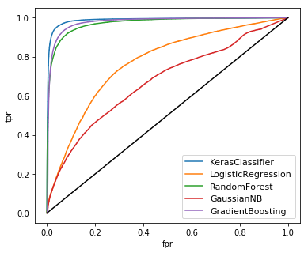

```
Computing KerasClassifier
It took 56.4888899326 seconds.
Computing LogisticRegression
It took 80.9717438221 seconds.
Computing RandomForest
It took 158.824050188 seconds.
Computing GaussianNB
It took 0.168772935867 seconds.
Computing GradientBoosting
It took 1096.89813209 seconds.
```

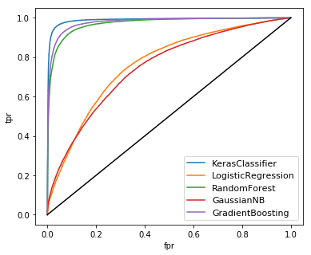

```
Computing KerasClassifier
It took 56.220156908 seconds.
Computing LogisticRegression
It took 72.230479002 seconds.
Computing RandomForest
It took 160.991761923 seconds.
Computing GaussianNB
It took 0.162863969803 seconds.
Computing GradientBoosting
It took 1243.74892902 seconds.
```

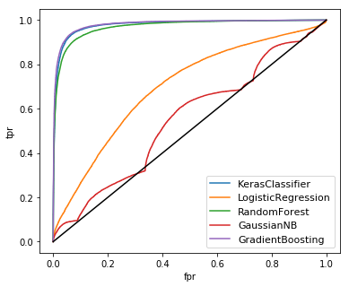

```python
from sklearn.ensemble import GradientBoostingClassifier, RandomForestClassifier
from sklearn.model_selection import train_test_split, cross_val_score
from sklearn import preprocessing, metrics
from sklearn.linear_model import LogisticRegression
from sklearn.naive_bayes import GaussianNB
import itertools
from collections import defaultdict

#best hyperparameters of each model:
clfs = {
        'KerasClassifier': KerasClassifier(build_fn=keras_model, epochs=20, batch_size=200, verbose=0), #(20, 200) verbose=0 not to see progress
        'GradientBoosting': GradientBoostingClassifier(learning_rate= 0.1, max_depth= 7,
                                                        n_estimators=1000, max_features = 0.3,
                                                        min_samples_leaf = 1), # ready
        'LogisticRegression' : LogisticRegression(penalty='l1', C=0.1, class_weight='balanced'), # ready -- {'penalty': 'l1', 'C': 0.1, 'class_weight': 'balanced'}
        'GaussianNB': GaussianNB(), # No hyperparameters. This is the baseline
        'RandomForest': RandomForestClassifier(n_estimators=200, max_depth=30), # ready n_estimators=200, max_depth=30
        }

# report
cols = ['model','matthews_corrcoef', 'roc_auc_score', 'precision_score',
        'recall_score','f1_score', 'accuracy', 'conf_matrix']
models_report = pd.DataFrame(columns = cols)
feature_importance = pd.DataFrame()

# split the data set for training and testing, 3-fold cross validation
for train_indices, test_indices in cv.split(X1,y1):
    # I will create new variables here so that it is more obvious what
    # the code is doing (you can compact this syntax and avoid duplicating memory,
    # but it makes this code less readable)
    X_train = X1[train_indices]
    y_train = y1[train_indices]

    X_test = X1[test_indices]
    y_test = y1[test_indices]

    # dictionary to save conf_matrix
    conf_matrix = dict()

    for clf, clf_name in zip(clfs.values(), clfs.keys()):

        #  stratifing means making a split so that the proportion of values in the sample produced
        # will be the same as the proportion of values provided to parameter stratify.
        # For example, if variable y is a binary categorical variable with values 0 and 1
        # and there are 25% of zeros and 75% of ones, stratify=y will make sure
        # that your random split has 25% of 0's and 75% of 1's.
        print('Computing {}'.format(clf_name))

        # fitting the model
        start = time.time() # start timing
        clf.fit(X_train,y_train) # train_features, train_labels

        #print model fitting time
        print 'It took', time.time()-start, 'seconds.'   # fitting time

        #getting predictions and metrics
        y_pred = clf.predict(X_test) # this is . get test set predictions. --> use y1_hat = np.zeros(y1.shape) # we will fill this with predictions
        y_score = clf.predict_proba(X_test)[:,1]


        #adding to confusion matrix
        if clf_name in conf_matrix.keys():
        # append the new number to the existing array at this slot
            continue
        else:
            # create a new array in this slot
            conf_matrix[clf_name] = { 'True': sum(y_test), 'Predicted': sum(y_pred)}

        if (clf_name == 'RandomForest') | (clf_name == 'GradientBoosting'):
            tmp_fi = pd.Series(clf.feature_importances_)
            feature_importance[clf_name] = tmp_fi

        tmp = pd.Series({
                         'model': clf_name,
                         'roc_auc_score' : metrics.roc_auc_score(y_test, y_score), # roc_auc_score(y_test,model.predict(X_test))
                         'matthews_corrcoef': metrics.matthews_corrcoef(y_test, y_pred),
                         'precision_score': metrics.precision_score(y_test, y_pred),
                         'recall_score': metrics.recall_score(y_test, y_pred),
                         'f1_score': metrics.f1_score(y_test, y_pred),
                         'accuracy': metrics.accuracy_score(y_test, y_pred),
                         'conf_matrix':  metrics.confusion_matrix(y_test, y_pred)}
                       )

        models_report = models_report.append(tmp, ignore_index = True)

        precision, recall, _ = metrics.precision_recall_curve(y_test, y_score)
        fpr, tpr, _ = metrics.roc_curve(y_test, y_score, drop_intermediate = False, pos_label = 1)
        # _ has 5 main conventional uses in Python:
        #     1. To hold the result of the last executed expression(/statement) in an interactive interpreter session. This precedent was set by the standard CPython interpreter, and other interpreters have followed suit
        #     2. For translation lookup in i18n (see the gettext documentation for example), as in code like: raise forms.ValidationError(_("Please enter a correct username"))
        #     3. Often used: as a general purpose "throwaway" variable name to indicate that part of a function result is being deliberately ignored, as in code like: label, has_label, _ = text.partition(':')
        # The latter two purposes can conflict, so it is necessary to avoid using _ as a throwaway variable in any code block that also uses it for i18n translation (many folks prefer a double-underscore, __, as their throwaway variable for exactly this reason).
        # here are 5 cases for using the underscore in Python.
        #     4. To give special meanings and functions to name of vartiables or functions.
        #     5. To separate the digits of number literal value.

        plt.figure(1, figsize = (6,5))
        plt.xlabel('fpr')
        plt.ylabel('tpr')
        plt.plot(fpr, tpr, label = clf_name)
        plt.legend(prop={'size':11})

    plt.plot([0,1], [0,1], c = 'black')
    plt.show()
```

In each of the validations, Keras Classifier, Gradient Boosting, and Random Forest decisively perform the best in term of ROC, where the ROC curves are pull the left top corner. Keras Classifier and Gradient Boosting seem to give slightly better roc in each of the 3-fold validations.

Gaussian Naive Bayes and Logistic Regression are not working very well with our data set, the ROC curves are in central region of the graph.

In term of efficiency, Gradient Boosting takes much longer to complete, compared to other models. A more detail result table is in the below.

```python
models_report
```

|  | model | matthews_corrcoef | roc_auc_score | precision_score | recall_score | f1_score | accuracy | conf_matrix |
| --- | --- | --- | --- | --- | --- | --- | --- | --- |
| 0 | KerasClassifier | 0.910487 | 0.988105 | 0.949006 | 0.943595 | 0.946293 | 0.957026 | [[30850, 1085], [1207, 20192]] |
| 1 | LogisticRegression | 0.418055 | 0.768577 | 0.654174 | 0.646011 | 0.650067 | 0.720947 | [[24627, 7308], [7575, 13824]] |
| 2 | RandomForest | 0.827396 | 0.971820 | 0.927142 | 0.861676 | 0.893211 | 0.917332 | [[30486, 1449], [2960, 18439]] |
| 3 | GaussianNB | 0.114519 | 0.672731 | 0.428605 | 0.862938 | 0.572740 | 0.483425 | [[7317, 24618], [2933, 18466]] |
| 4 | GradientBoosting | 0.858207 | 0.977368 | 0.927020 | 0.901678 | 0.914173 | 0.932070 | [[30416, 1519], [2104, 19295]] |
| 5 | KerasClassifier | 0.919001 | 0.989252 | 0.952468 | 0.950465 | 0.951465 | 0.961094 | [[30919, 1015], [1060, 20339]] |
| 6 | LogisticRegression | 0.408384 | 0.763486 | 0.617998 | 0.708912 | 0.660340 | 0.707386 | [[22557, 9377], [6229, 15170]] |
| 7 | RandomForest | 0.824334 | 0.971026 | 0.920834 | 0.864807 | 0.891941 | 0.915924 | [[30343, 1591], [2893, 18506]] |
| 8 | GaussianNB | 0.359729 | 0.748667 | 0.613820 | 0.623487 | 0.618616 | 0.691542 | [[23540, 8394], [8057, 13342]] |
| 9 | GradientBoosting | 0.859155 | 0.978802 | 0.922270 | 0.908220 | 0.915191 | 0.932462 | [[30296, 1638], [1964, 19435]] |
| 10 | KerasClassifier | 0.833499 | 0.978020 | 0.848532 | 0.961821 | 0.901632 | 0.915793 | [[28260, 3674], [817, 20582]] |
| 11 | LogisticRegression | 0.308306 | 0.696318 | 0.567647 | 0.639376 | 0.601380 | 0.659910 | [[21513, 10421], [7717, 13682]] |
| 12 | RandomForest | 0.826129 | 0.969850 | 0.926337 | 0.860928 | 0.892436 | 0.916731 | [[30469, 1465], [2976, 18423]] |
| 13 | GaussianNB | 0.033783 | 0.549924 | 0.456556 | 0.093556 | 0.155290 | 0.591622 | [[29551, 2383], [19397, 2002]] |
| 14 | GradientBoosting | 0.870702 | 0.981361 | 0.927784 | 0.916772 | 0.922245 | 0.937975 | [[30407, 1527], [1781, 19618]] |

**Plot The confusion Matrix of the Last Validation**

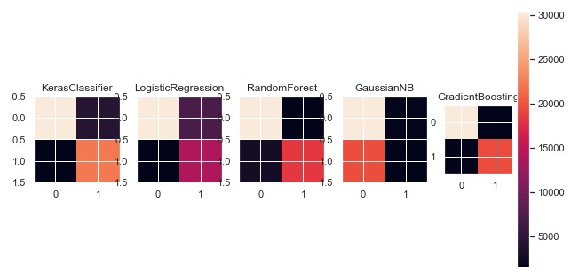

```python
import numpy as np
import matplotlib.pyplot as plt

w=10
h=10
fig=plt.figure(figsize=(10, 10))
columns = 5
rows = 1
for i in range(1, columns*rows +1):
    if 9+i > 14:
        break
    else:
        img = models_report['conf_matrix'][9+i]
        fig.add_subplot(rows, columns, i).set_title(models_report['model'][9+i])
        plt.imshow(img) # cmap='gray'
#         plt.colorbar()

plt.colorbar()
plt.show()
```

The color bar has darker color for lower counts and lighter color for higher count.

```python
models_report_model = models_report.groupby(models_report['model']).describe().transpose()
models_report_model
```

|  | model | GaussianNB | GradientBoosting | KerasClassifier | LogisticRegression | RandomForest |
| --- | --- | --- | --- | --- | --- | --- |
| accuracy | count | 3.000000 | 3.000000 | 3.000000 | 3.000000 | 3.000000 |
|  | mean | 0.588863 | 0.934169 | 0.944637 | 0.696081 | 0.916662 |
|  | std | 0.104086 | 0.003302 | 0.025062 | 0.032050 | 0.000706 |
|  | min | 0.483425 | 0.932070 | 0.915793 | 0.659910 | 0.915924 |
|  | 25% | 0.537524 | 0.932266 | 0.936409 | 0.683648 | 0.916328 |
|  | 50% | 0.591622 | 0.932462 | 0.957026 | 0.707386 | 0.916731 |
|  | 75% | 0.641582 | 0.935218 | 0.959060 | 0.714166 | 0.917032 |
|  | max | 0.691542 | 0.937975 | 0.961094 | 0.720947 | 0.917332 |
| f1_score | count | 3.000000 | 3.000000 | 3.000000 | 3.000000 | 3.000000 |
|  | mean | 0.448882 | 0.917203 | 0.933130 | 0.637263 | 0.892529 |
|  | std | 0.255291 | 0.004396 | 0.027401 | 0.031497 | 0.000640 |
|  | min | 0.155290 | 0.914173 | 0.901632 | 0.601380 | 0.891941 |
|  | 25% | 0.364015 | 0.914682 | 0.923962 | 0.625724 | 0.892189 |
|  | 50% | 0.572740 | 0.915191 | 0.946293 | 0.650067 | 0.892436 |
|  | 75% | 0.595678 | 0.918718 | 0.948879 | 0.655204 | 0.892823 |
|  | max | 0.618616 | 0.922245 | 0.951465 | 0.660340 | 0.893211 |
| matthews_corrcoef | count | 3.000000 | 3.000000 | 3.000000 | 3.000000 | 3.000000 |
|  | mean | 0.169344 | 0.862688 | 0.887662 | 0.378248 | 0.825953 |
|  | std | 0.169749 | 0.006956 | 0.047100 | 0.060765 | 0.001539 |
|  | min | 0.033783 | 0.858207 | 0.833499 | 0.308306 | 0.824334 |
|  | 25% | 0.074151 | 0.858681 | 0.871993 | 0.358345 | 0.825231 |
|  | 50% | 0.114519 | 0.859155 | 0.910487 | 0.408384 | 0.826129 |
|  | 75% | 0.237124 | 0.864929 | 0.914744 | 0.413220 | 0.826762 |
|  | max | 0.359729 | 0.870702 | 0.919001 | 0.418055 | 0.827396 |
| precision_score | count | 3.000000 | 3.000000 | 3.000000 | 3.000000 | 3.000000 |
|  | mean | 0.499660 | 0.925692 | 0.916669 | 0.613273 | 0.924771 |
|  | std | 0.099848 | 0.002988 | 0.059033 | 0.043456 | 0.003433 |
|  | min | 0.428605 | 0.922270 | 0.848532 | 0.567647 | 0.920834 |
|  | 25% | 0.442581 | 0.924645 | 0.898769 | 0.592823 | 0.923586 |
|  | 50% | 0.456556 | 0.927020 | 0.949006 | 0.617998 | 0.926337 |
|  | 75% | 0.535188 | 0.927402 | 0.950737 | 0.636086 | 0.926740 |
|  | max | 0.613820 | 0.927784 | 0.952468 | 0.654174 | 0.927142 |
| recall_score | count | 3.000000 | 3.000000 | 3.000000 | 3.000000 | 3.000000 |
|  | mean | 0.526660 | 0.908890 | 0.951960 | 0.664766 | 0.862470 |
|  | std | 0.393724 | 0.007569 | 0.009204 | 0.038375 | 0.002058 |
|  | min | 0.093556 | 0.901678 | 0.943595 | 0.639376 | 0.860928 |
|  | 25% | 0.358521 | 0.904949 | 0.947030 | 0.642694 | 0.861302 |
|  | 50% | 0.623487 | 0.908220 | 0.950465 | 0.646011 | 0.861676 |
|  | 75% | 0.743212 | 0.912496 | 0.956143 | 0.677462 | 0.863241 |
|  | max | 0.862938 | 0.916772 | 0.961821 | 0.708912 | 0.864807 |
| roc_auc_score | count | 3.000000 | 3.000000 | 3.000000 | 3.000000 | 3.000000 |
|  | mean | 0.657107 | 0.979177 | 0.985126 | 0.742793 | 0.970899 |
|  | std | 0.100289 | 0.002023 | 0.006181 | 0.040330 | 0.000991 |
|  | min | 0.549924 | 0.977368 | 0.978020 | 0.696318 | 0.969850 |
|  | 25% | 0.611327 | 0.978085 | 0.983062 | 0.729902 | 0.970438 |
|  | 50% | 0.672731 | 0.978802 | 0.988105 | 0.763486 | 0.971026 |
|  | 75% | 0.710699 | 0.980082 | 0.988679 | 0.766031 | 0.971423 |
|  | max | 0.748667 | 0.981361 | 0.989252 | 0.768577 | 0.971820 |

Looking at the average result of all 3 cross validations, KerasClassifier performs the best in term of ROC. GradientBoosting, Keras Neural Net, and Random Forest have very similar average roc results. Keras Neural Net also gives the best accuracy score, recall, and F1.

Gradient Boosting gives the best precision score. Random Fores also give very similar high precision score compared to that produced by Gradient Boosting.

Average Result - 3 Folds Cross Validation

| Model | Optimal Model Parameters | ROC | Accuracy | Recall | Precision | F1 | Average Elapsed Time |
| --- | --- | --- | --- | --- | --- | --- | --- |
| Random Forest | {'n_estimators': 200, 'max_depth': 30} | 0.970899 | 0.916662 | 0.862470 | 0.924771 | 0.892529 | 159.88s |
| Logistic Regression | {'penalty': 'l1', 'C': 0.1, 'class_weight': 'balanced'}) | 0.742793 | 0.696081 | 0.664766 | 0.613273 | 0.637263 | 72.61s |
| Gradient Boosting | {'max_features': 0.3, 'n_estimators': 1000, 'learning_rate': 0.1, 'max_depth': 7, 'min_samples_leaf': 1}) | 0.979177 | 0.934169 | 0.908890 | 0.925692 | 0.917203 | 1170.85s |
| Keras Neural Net | {Layer: 3, NN: 50-60-1, activation func: Relu-sigmoid, initializer: glorot_uniform, batch size: 200, optimizer: sgd, epochs: 20} | **0.985126** | **0.944637** | **0.951960** | 0.916669 | **0.933130** | 56.80s |
| GaussianNB | None | 0.657107 | 0.588863 | 0.526660 | 0.499660 | 0.448882 | 0.16s |

# VII. Results and Model Selection

Back to top

## Hyperparameter Tuning Results

For Random Forest model, our parameters grid has n_estimators' in (10,50,150,200), and 'max_depth' in (10, 30, 50, 100) values. The Grid Search returns with the best n_estimators is 200. This makes sense because the higher value of n_estimators returns better model overall performance. However, at certain point, the time efficiency may be too excessive for a very large value of n_estimators. Since our data set is relatively large, it'd take too long to go to higher n_estimators. We decide to stop at n_estimators 200. Best max_depth is 30. This is also reasonable since our data is bias. Others parameters are recommended as default.

For Logistic Regression model, our parameters grid has c_values in (.001,.1,1,10,100,1000), 'penalty' in ('l1','l2'), and 'class_weight'in (None, 'balanced'). The Grid Search returns with penalty - l1, which means that the objective function that is minimized is better for L1, which is the sum of errors, rather than L2, which is the sum of squared errors. L1 is less sensitive to outliers. L1 makes sense since there is no obvious outliner in our data set. C=0.1 value indicates a smaller value is needed to improve the models ability to not fit to noise. This is understandable as the data is normalized data. Class_weight selection of 'balanced' over None, means balanced adds accuracy to the fit, likely because 'balanced' model uses the values of y to automatically adjust weights inversely proportional to class frequencies in the input data"

For Gradient Boosting, our parameters grid has 'max_depth'in (3, 5, 7), 'n_estimators' in (150, 500, 1000),'min_samples_leaf' is 1,'learning_rate' is 0.1, and max_features' is 0.3. The Grid Search reveals the best n_estimators is 1000. This makes sense because the higher value of n_estimators returns better model metric result. However, Gradient Boosting is computationally expensive, the time efficiency may be too excessive for a very large value of n_estimators. With our relatively large data set, with the elapsed time is already more than 30mins with n_estimators 1000. Therefore, we decide to stop at n_estimators 1000. Similarly, the gridsearch returns with th best max_depth is 7. This is also reasonable since our data is bias and is large. min_samples_leaf' equals 1 works for our imbalanced data set.

For Keras Neural Net, the best combination is the model of 3 layers with 50-60-1 neuron structure, relu in all the input and hidden layer and sigmoid in the output layer, 'glorot_uniform' kernel initializer, batch size 200, SGD optimizer, and 20 epochs. Overall, with our data set, changing the activation function (relu in the lower layers and sigmoid in the output layer) and kernel initializer ('glorot_uniform') improves the roc result the most. Varying epoch number and batch size also improve the performance, but not very significant. Increasing the number of epochs can improve the performance until the model shows signs of overfitting. Increasing the number of internal neurons and epochs creates more complex models and requires more expensive computations, but it does not provide any performance gains.

Table 2. Optimal Parameter Results

| Model | Optimal Model Parameters |
| --- | --- |
| Random Forest | {'n_estimators': 200, 'max_depth': 30} |
| Logistic Regression | {'penalty': 'l1', 'C': 0.1, 'class_weight': 'balanced'}) |
| Gradient Boosting | {'max_features': 0.3, 'n_estimators': 1000, 'learning_rate': 0.1, 'max_depth': 7, 'min_samples_leaf': 1}) |
| Keras Neural Net | {Layer: 3, NN: 50-60-1, activation func: Relu-sigmoid, initializer: glorot_uniform, batch size: 200, optimizer: sgd, epochs: 20} |

Back to top

## Model Selection

[figure not shown]

```python
import glob
import matplotlib.pyplot as plt
import matplotlib.image as mpimg
%matplotlib inline

images = [mpimg.imread('/Users/heidinguyen/Downloads/Validation_1.png'), # convert image to float
         mpimg.imread('/Users/heidinguyen/Downloads/Validation_2.png'), # convert image to float
         mpimg.imread('/Users/heidinguyen/Downloads/Validation_3.png')] # convert image to float

title = ["1st Validation ROC Result", "2nd Validation ROC Result", "3rd Validation ROC Result"]
plt.figure(figsize=(40,20))
columns = 3

plt.suptitle('3-Fold Cross Validation - ROC Result', fontsize=36)
plt.tight_layout()
plt.subplots_adjust(top=0.88)
for i, image in enumerate(images):
    plt.subplot(len(images) / columns + 1, columns, i + 1)
    plt.title(title[i])
    plt.imshow(image)
```

In each of the validations (see above plots), Keras Classifier, Gradient Boosting, and Random Forest decisively perform the best in term of ROC, where the ROC curves are pull the left top corner. Keras Classifier and Gradient Boosting seem to give slightly better roc in each of the 3-fold validations. Gaussian Naive Bayes and Logistic Regression are not working very well with our data set, the ROC curves are in central region of the graph.

Looking at the average result of all 3 cross validations (see Table 2 below), KerasClassifier performs the best in term of average ROC. GradientBoosting, Keras Neural Net, and Random Forest have very similar average ROC results. Keras Neural Net also gives the best accuracy score, recall, and F1. Gradient Boosting gives the best precision score. Random Fores also give very similar high precision score compared to that produced by Gradient Boosting.

In term of efficiency, Gradient Boosting takes much longer to complete, compared to other models. A more detail result table is in the below.

For model selection, we only consider Gradient Boosting, Keras Neural Net, and Random Forest. These are models that give good ROC results, which is the objective of this exercise. Depending on the business case, a proper measure of the metrics needs to take into account the cost of being wrong. Since the evaluation metric for this case study is ROC, we assume the cost of predicting positive wrong is more costly than predicting negative wrong. This means that the false positives (FP) are costlier than false negatives FN). Furthermore, this means that the recall measurement should be minimized while maximizing precision. Meaning, the best model is the one that gives the highest ROC and highest F1.

For our data set, the best overall model for our data set is Keras Neural Net, with 4 best results: best average ROC, accuracy, recall, and F1. best average ROC (98.51%), accuracy (94.46%), recall(95.20%), and F1 (93.31%). Keras Neural Net is also time and computation effective, with the fast executing time (56.80s).

Table 2. Average Result - 3 Folds Cross Validation

| Model | Optimal Model Parameters | Avg. ROC | Avg. Accuracy | Avg. Recall | Avg. Precision | Avg. F1 | Avg. Average Elapsed Time |
| --- | --- | --- | --- | --- | --- | --- | --- |
| Random Forest | {'n_estimators': 200, 'max_depth': 30} | 0.970899 | 0.916662 | 0.862470 | 0.924771 | 0.892529 | 159.88s |
| Logistic Regression | {'penalty': 'l1', 'C': 0.1, 'class_weight': 'balanced'}) | 0.742793 | 0.696081 | 0.664766 | 0.613273 | 0.637263 | 72.61s |
| Gradient Boosting | {'max_features': 0.3, 'n_estimators': 1000, 'learning_rate': 0.1, 'max_depth': 7, 'min_samples_leaf': 1}) | 0.979177 | 0.934169 | 0.908890 | **0.925692** | 0.917203 | 1170.85s |
| Keras Neural Net | {Layer: 3, NN: 50-60-1, activation func: Relu-sigmoid, initializer: glorot_uniform, batch size: 200, optimizer: sgd, epochs: 20} | **0.985126** | **0.944637** | **0.951960** | 0.916669 | **0.933130** | **56.80s** |
| GaussianNB | None | 0.657107 | 0.588863 | 0.526660 | 0.499660 | 0.448882 | 0.16s |

# VII. Conclusion

Back to top

For model selection, the best overall model for our data set is Keras Neural Net, with 4 best results: best average ROC (98.51%), accuracy (94.46%), recall(95.20%), and F1 (93.31%). Keras Neural Net is also time and computation effective, with the fast executing time (56.80s).

This comparision activity give us a sense of what can be tuned in each of the model and what model can be used in our data set. There are a big amount for parameters that can be optimized. We have also learned that if we spend more time learning or tuning model parameters, we will not necessarily improve the model performance. Modelling is more about adopting the right model, smart techniques with the right parameter combination, and not necessarily about the time spent in computations.

Another point is that because we have a complex model, it is computationally expensive. Another issue with our complex model is that can give good performance on training data, where the inherent relations in trained data are memorized, but it may not give good performance on validation data. This is because the model is not able to generalize on new unseen data.

# IX. Reference:

[1] SMU Lecture Notes

[2]. https://medium.com/ibm-data-science-experience/missing-data-conundrum-exploration-and-imputation-techniques-9f40abe0fd87

[3]. https://github.com/ResidentMario/missingno

[4]. https://medium.com/ibm-data-science-experience/missing-data-conundrum-exploration-and-imputation-techniques-9f40abe0fd87

[5] https://towardsdatascience.com/working-with-missing-data-in-machine-learning-9c0a430df4ce

[6]. https://towardsdatascience.com/working-with-missing-data-in-machine-learning-9c0a430df4ce

[7]. https://towardsdatascience.com/working-with-missing-data-in-machine-learning-9c0a430df4ce

[8]. https://keras.io/models/model/

[9] Radhakrishnan P. When to stop Training your Neural Network?. Available at: https://medium.com/@pranoyradhakrishnan/when-to-stop-training-your-neural-network-174ff0a6dea5

[10] http://ruder.io/optimizing-gradient-descent/

[11] https://towardsdatascience.com/how-to-build-a-neural-network-with-keras-e8faa33d0ae4

[12] https://github.com/maxpumperla/hyperas

[13] Gulli A, Pal S. Deep Learning with Keras. Available at: http://www.zhanjunlang.com/resources/tutorial/Deep%20Learning%20with%20Keras.pdf

[14] https://machinelearningmastery.com/tutorial-first-neural-network-python-keras/

Back to top

# X. Appendix

Back to top

```python
# look at the raw file
! head "final_project.csv"
```

```python
# read in the entire file into data frame
df=pd.read_csv("final_project.csv")
df.describe()
```

```python
df.info(verbose=True, null_counts=True) #this will print the null_counts
```

```python
for i in df.columns:
    print (i, df[i].dtype)
```

```python
for i in df.columns:
    print (i, df[i].min())
    print (i, df[i].max())
```

```python
size_it(df)
```

```python
#distribution
from IPython.display import Image
Image(filename='/Users/heidinguyen/Downloads/Screen Shot 2018-08-06 at 7.14.53 PM.png')
```

```python
N=10500000 #
data=pd.read_csv("final_project.csv",nrows=N,header=None)
test_data=pd.read_csv("final_project.csv",nrows=500000,header=None,skiprows=10500000)
```

```python
for i in df_raw.columns:
    if i == 'x24' or i == 'x29'or i=='x30':
        types[i] = df_raw[i].dtype  #if types is a list: types = [l for l in i] or types.append (data[i].dtype)
    elif i == 'y':
        types[i] = np.uint8 # np.int8
    else:
        types[i] = np.float32

# check types[]
types
```

```python
# boxplot
%matplotlib inline
#To switch to seaborn defaults, simply call the set() function:
sns.set()
plt.rcParams['figure.figsize']=(15,6)

# boxplot for explanatory variables, excluding column 'x37'.
excl_cols = ['y', 'x37', 'x0', 'x25', 'x26', 'x31', 'x32', 'x33','x34', 'x35', 'x36', 'x39', 'x42', 'x43', 'x44', 'x45', 'x47', 'x48']
data[data.columns[~data.columns.isin(excl_cols)]].boxplot()

# boxplot variables with small value up to 30
# boxplot for explanatory variables, excluding column 'x37'.
medium_cols = [ 'x31', 'x34', 'x35', 'x39', 'x42', 'x44', 'x47']
df_data[df_data.columns[df_data.columns.isin(medium_cols)]].boxplot()

small_cols = ['x0', 'x25', 'x26', 'x32', 'x33', 'x36', 'x43', 'x45','x48']
df_data[df_data.columns[df_data.columns.isin(small_cols)]].boxplot()

df_data[df_data.columns[df_data.columns.isin(['x37'])]].boxplot()
```

```python
%%time
# Let's start with RF and 3 fold cross validation, calculating roc to start.
start = time.time()

from xgboost import XGBClassifier  # does not work. Kernel keeps crashing down


model = XGBClassifier(objective='binary:logistic', max_depth=5, learning_rate=0.1)
params = {
    'n_estimators': [100],
#     'learning_rate': [0.1, 0.3], # Choose a relatively high learning rate. Generally a learning rate of 0.1 works but somewhere between 0.05 to 0.3 should work for different problems.
#     'max_depth': [5], # max_depth = 5 : This should be between 3-10. I’ve started with 5 but you can choose a different number as well. 4-6 can be good starting points.
#     'min_child_weight': [1], # min_child_weight = 1 : A smaller value is chosen because it is a highly imbalanced class problem and leaf nodes can have smaller size groups.
#     'gamma': [1,3]
    }
xgb_clf = grid_searcher(X1, y1, model, params,cv.get_n_splits(X1,y1),'roc_auc') # n_splits=3, can use: cv.get_n_splits(X1,y1)
print("The best estimator: ",xgb_clf.best_estimator_)
print("The best roc score is: ", xgb_clf.best_score_)
print("The best parameters of model is: ",xgb_clf.best_params_)

print 'It took', time.time()-start, 'seconds.'
```